# Replication Material How Transnational Party Alliances Influence National Parties’ Policies doi: https://doi.org/10.1017/psrm.2020.55

Roman Senninger, Daniel Bischof, and Lawrence Ezrow

Contact: rsenninger@ps.au.dk

# Data

Please visit the PSRM dataverse (https://dataverse.harvard.edu/dataverse/PSRM) or Roman Senninger’s Dataverse (https://dataverse.harvard.edu/dataverse/R_Senninger) to download the data sets used in this manual.

# Load Required Packages

```r
library("dplyr")
library("ggplot2")
library("stargazer")
library("lmtest")
library("Zelig")
```

# Set Seed

```r
set.seed(12345678)
```

# Main Results

This manual provides code to reproduce our results in the main body of the manuscript and the appendix. We start with the regression results in Table 1.

## Table 1

```r
# load dataset

load("./dataframe1.RData")

# increase maximum print to show full regression outputs

options(max.print=1000000)

# capture all parties minus one from colnames to include party fixed effects in the models

partyfx <- paste(colnames(dataframe1[24:237]), sep="")

# Model 1 in Table 1

model1 <- as.formula(paste("rile ~  spruled + year_fe2 + year_fe3 + year_fe4 +  year_fe5 + year_fe6 + year_fe7 +  year_fe8 +  year_fe9 +  year_fe10 + year_fe11 + year_fe12 + year_fe13 + year_fe14 + year_fe15 + year_fe16 + year_fe17 + year_fe18 + year_fe19 + year_fe20 + year_fe21 + year_fe22 + year_fe23 + year_fe24 + year_fe25 + year_fe26 + year_fe27 + year_fe28 + year_fe29 + year_fe30 + year_fe31 + year_fe32 + year_fe33 + year_fe34 +" , paste(partyfx, collapse="+")))

model1 <- lm(model1, data = dataframe1)
summary(model1)
```

```
##
## Call:
## lm(formula = model1, data = dataframe1)
##
## Residuals:
##      Min       1Q   Median       3Q      Max
## -1.49666 -0.29372 -0.00964  0.24805  1.94420
##
## Coefficients:
##              Estimate Std. Error t value Pr(>|t|)
## (Intercept)  4.127845   0.179901  22.945  < 2e-16 ***
## spruled      0.003980   0.001870   2.129 0.033385 *
## year_fe2     0.003342   0.105069   0.032 0.974631
## year_fe3     0.043323   0.103920   0.417 0.676799
## year_fe4     0.029081   0.104274   0.279 0.780352
## year_fe5     0.113500   0.104916   1.082 0.279442
## year_fe6     0.261007   0.104557   2.496 0.012613 *
## year_fe7     0.284924   0.106816   2.667 0.007693 **
## year_fe8     0.256136   0.101250   2.530 0.011477 *
## year_fe9     0.098882   0.111837   0.884 0.376693
## year_fe10    0.163251   0.127919   1.276 0.202004
## year_fe11    0.235116   0.113591   2.070 0.038571 *
## year_fe12    0.289860   0.107190   2.704 0.006894 **
## year_fe13    0.375073   0.100285   3.740 0.000188 ***
## year_fe14    0.391252   0.097032   4.032 5.69e-05 ***
## year_fe15    0.041751   0.124141   0.336 0.736661
## year_fe16   -0.068691   0.162528  -0.423 0.672596
## year_fe17   -0.057299   0.152971  -0.375 0.708010
## year_fe18   -0.040225   0.152578  -0.264 0.792084
## year_fe19    0.023214   0.132924   0.175 0.861375
## year_fe20    0.054318   0.198607   0.273 0.784497
## year_fe21    0.033136   0.207995   0.159 0.873435
## year_fe22    0.027812   0.201341   0.138 0.890144
## year_fe23   -0.105719   0.227942  -0.464 0.642832
## year_fe24   -0.161988   0.230350  -0.703 0.481980
## year_fe25   -0.115611   0.207993  -0.556 0.578370
## year_fe26   -0.178375   0.220169  -0.810 0.417918
## year_fe27   -0.095653   0.165963  -0.576 0.564430
## year_fe28   -0.114015   0.174357  -0.654 0.513225
## year_fe29   -0.412997   0.293005  -1.410 0.158807
```

[output cut: 210 more lines]

```
## party_fe207  1.564821   0.285880   5.474 4.85e-08 ***
## party_fe208  1.363207   0.245173   5.560 2.98e-08 ***
## party_fe209  0.716136   0.244896   2.924 0.003484 **
## party_fe210  0.911751   0.244896   3.723 0.000201 ***
## party_fe211  0.909186   0.244896   3.713 0.000210 ***
## party_fe212  0.606382   0.382178   1.587 0.112720
## party_fe213  1.087386   0.244896   4.440 9.38e-06 ***
## party_fe214  0.871836   0.244896   3.560 0.000378 ***
## party_fe215  1.741911   0.244896   7.113 1.48e-12 ***
## ---
## Signif. codes:  0 '***' 0.001 '**' 0.01 '*' 0.05 '.' 0.1 ' ' 1
##
## Residual standard error: 0.5055 on 2469 degrees of freedom
## Multiple R-squared:  0.7279, Adjusted R-squared:  0.7005
## F-statistic: 26.63 on 248 and 2469 DF,  p-value: < 2.2e-16
```

```r
stargazer(model1)
```

```
##
## % Table created by stargazer v.5.2.2 by Marek Hlavac, Harvard University. E-mail: hlavac at fas.harvard.edu
## % Date and time: Thu, Jul 01, 2021 - 15:52:35
## \begin{table}[!htbp] \centering
##   \caption{}
##   \label{}
## \begin{tabular}{@{\extracolsep{5pt}}lc}
## \\[-1.8ex]\hline
## \hline \\[-1.8ex]
##  & \multicolumn{1}{c}{\textit{Dependent variable:}} \\
## \cline{2-2}
## \\[-1.8ex] & rile \\
## \hline \\[-1.8ex]
##  spruled & 0.004$^{**}$ \\
##   & (0.002) \\
##   & \\
##  year\_fe2 & 0.003 \\
##   & (0.105) \\
##   & \\
##  year\_fe3 & 0.043 \\
##   & (0.104) \\
##   & \\
##  year\_fe4 & 0.029 \\
##   & (0.104) \\
##   & \\
##  year\_fe5 & 0.113 \\
##   & (0.105) \\
##   & \\
##  year\_fe6 & 0.261$^{**}$ \\
##   & (0.105) \\
##   & \\
##  year\_fe7 & 0.285$^{***}$ \\
##   & (0.107) \\
##   & \\
##  year\_fe8 & 0.256$^{**}$ \\
##   & (0.101) \\
##   & \\
##  year\_fe9 & 0.099 \\
##   & (0.112) \\
##   & \\
```

[output cut: 716 more lines]

```
##   & \\
##  Constant & 4.128$^{***}$ \\
##   & (0.180) \\
##   & \\
## \hline \\[-1.8ex]
## Observations & 2,718 \\
## R$^{2}$ & 0.728 \\
## Adjusted R$^{2}$ & 0.701 \\
## Residual Std. Error & 0.505 (df = 2469) \\
## F Statistic & 26.629$^{***}$ (df = 248; 2469) \\
## \hline
## \hline \\[-1.8ex]
## \textit{Note:}  & \multicolumn{1}{r}{$^{*}$p$<$0.1; $^{**}$p$<$0.05; $^{***}$p$<$0.01} \\
## \end{tabular}
## \end{table}
```

```r
# Model 2 in Table 2

model2 <- as.formula(paste("rile ~ lag_rile + lag_cmedian + lag_econ_glob + interaction + spruled + year_fe2 + year_fe3 + year_fe4 +  year_fe5 + year_fe6 +  year_fe7 +  year_fe8 +  year_fe9 +  year_fe10 + year_fe11 + year_fe12 + year_fe13 + year_fe14 + year_fe15 + year_fe16 + year_fe17 + year_fe18 + year_fe19 + year_fe20 + year_fe21 + year_fe22 + year_fe23 + year_fe24 + year_fe25 + year_fe26 + year_fe27 + year_fe28 + year_fe29 + year_fe30 + year_fe31 + year_fe32 + year_fe33 + year_fe34 +" , paste(partyfx, collapse= "+")))

model2 <- lm(model2, data = dataframe1)
summary(model2)
```

```
##
## Call:
## lm(formula = model2, data = dataframe1)
##
## Residuals:
##      Min       1Q   Median       3Q      Max
## -1.95769 -0.09712 -0.00075  0.10619  2.05656
##
## Coefficients:
##                Estimate Std. Error t value Pr(>|t|)
## (Intercept)   -1.561832   0.836342  -1.867 0.061956 .
## lag_rile       0.750543   0.012874  58.301  < 2e-16 ***
## lag_cmedian    0.500752   0.158971   3.150 0.001653 **
## lag_econ_glob  0.032493   0.011342   2.865 0.004207 **
## interaction   -0.006664   0.002127  -3.133 0.001752 **
## spruled        0.003775   0.001211   3.116 0.001854 **
## year_fe2       0.028177   0.067457   0.418 0.676206
## year_fe3       0.026090   0.066697   0.391 0.695702
## year_fe4       0.034703   0.067289   0.516 0.606094
## year_fe5       0.076057   0.068027   1.118 0.263658
## year_fe6       0.162310   0.068406   2.373 0.017733 *
## year_fe7       0.149128   0.070034   2.129 0.033322 *
## year_fe8       0.118153   0.066507   1.777 0.075764 .
## year_fe9      -0.055154   0.074375  -0.742 0.458418
## year_fe10     -0.029069   0.085010  -0.342 0.732414
## year_fe11      0.017245   0.075273   0.229 0.818812
## year_fe12      0.049266   0.071142   0.693 0.488686
## year_fe13      0.127883   0.066816   1.914 0.055741 .
## year_fe14      0.126757   0.066839   1.896 0.058018 .
## year_fe15     -0.178683   0.085351  -2.094 0.036405 *
## year_fe16     -0.182419   0.110433  -1.652 0.098693 .
## year_fe17     -0.169975   0.104839  -1.621 0.105084
## year_fe18     -0.129161   0.105847  -1.220 0.222484
## year_fe19     -0.072452   0.094186  -0.769 0.441823
## year_fe20     -0.173862   0.135583  -1.282 0.199848
## year_fe21     -0.232975   0.142742  -1.632 0.102779
## year_fe22     -0.225181   0.140513  -1.603 0.109158
## year_fe23     -0.333784   0.158423  -2.107 0.035226 *
## year_fe24     -0.334835   0.160226  -2.090 0.036741 *
## year_fe25     -0.253905   0.149155  -1.702 0.088826 .
```

[output cut: 214 more lines]

```
## party_fe207    0.440710   0.184529   2.388 0.017001 *
## party_fe208    0.297070   0.158499   1.874 0.061012 .
## party_fe209    0.132773   0.159190   0.834 0.404331
## party_fe210    0.188697   0.159325   1.184 0.236388
## party_fe211    0.321770   0.159193   2.021 0.043361 *
## party_fe212    0.117004   0.246142   0.475 0.634579
## party_fe213    0.260509   0.159448   1.634 0.102425
## party_fe214    0.193567   0.159278   1.215 0.224376
## party_fe215    0.398960   0.160355   2.488 0.012913 *
## ---
## Signif. codes:  0 '***' 0.001 '**' 0.01 '*' 0.05 '.' 0.1 ' ' 1
##
## Residual standard error: 0.3242 on 2465 degrees of freedom
## Multiple R-squared:  0.8882, Adjusted R-squared:  0.8768
## F-statistic: 77.75 on 252 and 2465 DF,  p-value: < 2.2e-16
```

```r
stargazer(model2)
```

```
##
## % Table created by stargazer v.5.2.2 by Marek Hlavac, Harvard University. E-mail: hlavac at fas.harvard.edu
## % Date and time: Thu, Jul 01, 2021 - 15:52:36
## \begin{table}[!htbp] \centering
##   \caption{}
##   \label{}
## \begin{tabular}{@{\extracolsep{5pt}}lc}
## \\[-1.8ex]\hline
## \hline \\[-1.8ex]
##  & \multicolumn{1}{c}{\textit{Dependent variable:}} \\
## \cline{2-2}
## \\[-1.8ex] & rile \\
## \hline \\[-1.8ex]
##  lag\_rile & 0.751$^{***}$ \\
##   & (0.013) \\
##   & \\
##  lag\_cmedian & 0.501$^{***}$ \\
##   & (0.159) \\
##   & \\
##  lag\_econ\_glob & 0.032$^{***}$ \\
##   & (0.011) \\
##   & \\
##  interaction & $-$0.007$^{***}$ \\
##   & (0.002) \\
##   & \\
##  spruled & 0.004$^{***}$ \\
##   & (0.001) \\
##   & \\
##  year\_fe2 & 0.028 \\
##   & (0.067) \\
##   & \\
##  year\_fe3 & 0.026 \\
##   & (0.067) \\
##   & \\
##  year\_fe4 & 0.035 \\
##   & (0.067) \\
##   & \\
##  year\_fe5 & 0.076 \\
##   & (0.068) \\
##   & \\
```

[output cut: 728 more lines]

```
##   & \\
##  Constant & $-$1.562$^{*}$ \\
##   & (0.836) \\
##   & \\
## \hline \\[-1.8ex]
## Observations & 2,718 \\
## R$^{2}$ & 0.888 \\
## Adjusted R$^{2}$ & 0.877 \\
## Residual Std. Error & 0.324 (df = 2465) \\
## F Statistic & 77.746$^{***}$ (df = 252; 2465) \\
## \hline
## \hline \\[-1.8ex]
## \textit{Note:}  & \multicolumn{1}{r}{$^{*}$p$<$0.1; $^{**}$p$<$0.05; $^{***}$p$<$0.01} \\
## \end{tabular}
## \end{table}
```

```r
# Model 3 in Table 1

model3 <- as.formula(paste("rile ~ spsamegroup_ruled + year_fe2 + year_fe3 + year_fe4 +  year_fe5 + year_fe6 +  year_fe7 +  year_fe8 +  year_fe9 +  year_fe10 + year_fe11 + year_fe12 + year_fe13 + year_fe14 + year_fe15 + year_fe16 + year_fe17 + year_fe18 + year_fe19 + year_fe20 + year_fe21 + year_fe22 + year_fe23 + year_fe24 + year_fe25 + year_fe26 + year_fe27 + year_fe28 + year_fe29 + year_fe30 + year_fe31 + year_fe32 + year_fe33 + year_fe34 +" , paste(partyfx, collapse= "+")))

model3 <- lm(model3, data = dataframe1)
summary(model3)
```

```
##
## Call:
## lm(formula = model3, data = dataframe1)
##
## Residuals:
##      Min       1Q   Median       3Q      Max
## -1.43442 -0.29724 -0.00849  0.24825  1.93704
##
## Coefficients:
##                    Estimate Std. Error t value Pr(>|t|)
## (Intercept)        4.390852   0.152415  28.809  < 2e-16 ***
## spsamegroup_ruled  0.004709   0.001040   4.529 6.20e-06 ***
## year_fe2           0.018090   0.104519   0.173 0.862603
## year_fe3           0.013018   0.103598   0.126 0.900013
## year_fe4           0.023714   0.103652   0.229 0.819055
## year_fe5           0.130386   0.103433   1.261 0.207579
## year_fe6           0.199448   0.102107   1.953 0.050894 .
## year_fe7           0.205574   0.102093   2.014 0.044161 *
## year_fe8           0.238045   0.100945   2.358 0.018443 *
## year_fe9           0.183478   0.100631   1.823 0.068381 .
## year_fe10          0.322713   0.096807   3.334 0.000870 ***
## year_fe11          0.333413   0.097194   3.430 0.000613 ***
## year_fe12          0.360867   0.096840   3.726 0.000199 ***
## year_fe13          0.391677   0.097811   4.004 6.40e-05 ***
## year_fe14          0.376688   0.096761   3.893 0.000102 ***
## year_fe15          0.168448   0.096486   1.746 0.080965 .
## year_fe16          0.161994   0.096872   1.672 0.094601 .
## year_fe17          0.145966   0.096561   1.512 0.130752
## year_fe18          0.140394   0.097235   1.444 0.148905
## year_fe19          0.143965   0.098660   1.459 0.144635
## year_fe20          0.357881   0.094742   3.777 0.000162 ***
## year_fe21          0.360163   0.094230   3.822 0.000136 ***
## year_fe22          0.330050   0.095021   3.473 0.000523 ***
## year_fe23          0.198122   0.098511   2.011 0.044418 *
## year_fe24          0.144297   0.098720   1.462 0.143957
## year_fe25          0.144994   0.099386   1.459 0.144720
## year_fe26          0.117743   0.098389   1.197 0.231531
## year_fe27          0.102396   0.096016   1.066 0.286326
## year_fe28          0.107647   0.095254   1.130 0.258540
## year_fe29          0.094587   0.093015   1.017 0.309299
```

[output cut: 210 more lines]

```
## party_fe207        1.570371   0.284650   5.517 3.81e-08 ***
## party_fe208        1.371400   0.244186   5.616 2.17e-08 ***
## party_fe209        0.741131   0.244186   3.035 0.002430 **
## party_fe210        0.936746   0.244186   3.836 0.000128 ***
## party_fe211        0.869731   0.244152   3.562 0.000375 ***
## party_fe212        0.643914   0.381052   1.690 0.091186 .
## party_fe213        1.112381   0.244186   4.555 5.48e-06 ***
## party_fe214        0.896831   0.244186   3.673 0.000245 ***
## party_fe215        1.766906   0.244186   7.236 6.14e-13 ***
## ---
## Signif. codes:  0 '***' 0.001 '**' 0.01 '*' 0.05 '.' 0.1 ' ' 1
##
## Residual standard error: 0.5039 on 2469 degrees of freedom
## Multiple R-squared:  0.7296, Adjusted R-squared:  0.7025
## F-statistic: 26.86 on 248 and 2469 DF,  p-value: < 2.2e-16
```

```r
stargazer(model3)
```

```
##
## % Table created by stargazer v.5.2.2 by Marek Hlavac, Harvard University. E-mail: hlavac at fas.harvard.edu
## % Date and time: Thu, Jul 01, 2021 - 15:52:37
## \begin{table}[!htbp] \centering
##   \caption{}
##   \label{}
## \begin{tabular}{@{\extracolsep{5pt}}lc}
## \\[-1.8ex]\hline
## \hline \\[-1.8ex]
##  & \multicolumn{1}{c}{\textit{Dependent variable:}} \\
## \cline{2-2}
## \\[-1.8ex] & rile \\
## \hline \\[-1.8ex]
##  spsamegroup\_ruled & 0.005$^{***}$ \\
##   & (0.001) \\
##   & \\
##  year\_fe2 & 0.018 \\
##   & (0.105) \\
##   & \\
##  year\_fe3 & 0.013 \\
##   & (0.104) \\
##   & \\
##  year\_fe4 & 0.024 \\
##   & (0.104) \\
##   & \\
##  year\_fe5 & 0.130 \\
##   & (0.103) \\
##   & \\
##  year\_fe6 & 0.199$^{*}$ \\
##   & (0.102) \\
##   & \\
##  year\_fe7 & 0.206$^{**}$ \\
##   & (0.102) \\
##   & \\
##  year\_fe8 & 0.238$^{**}$ \\
##   & (0.101) \\
##   & \\
##  year\_fe9 & 0.183$^{*}$ \\
##   & (0.101) \\
##   & \\
```

[output cut: 716 more lines]

```
##   & \\
##  Constant & 4.391$^{***}$ \\
##   & (0.152) \\
##   & \\
## \hline \\[-1.8ex]
## Observations & 2,718 \\
## R$^{2}$ & 0.730 \\
## Adjusted R$^{2}$ & 0.702 \\
## Residual Std. Error & 0.504 (df = 2469) \\
## F Statistic & 26.865$^{***}$ (df = 248; 2469) \\
## \hline
## \hline \\[-1.8ex]
## \textit{Note:}  & \multicolumn{1}{r}{$^{*}$p$<$0.1; $^{**}$p$<$0.05; $^{***}$p$<$0.01} \\
## \end{tabular}
## \end{table}
```

```r
# Model 4 in Table 1

model4 <- as.formula(paste("rile ~ lag_rile + lag_cmedian + lag_econ_glob + interaction + spsamegroup_ruled + year_fe2 + year_fe3 + year_fe4 +  year_fe5 + year_fe6 + year_fe7 +  year_fe8 +  year_fe9 +  year_fe10 + year_fe11 + year_fe12 + year_fe13 + year_fe14 + year_fe15 + year_fe16 + year_fe17 + year_fe18 + year_fe19 + year_fe20 + year_fe21 + year_fe22 + year_fe23 + year_fe24 + year_fe25 + year_fe26 + year_fe27 + year_fe28 + year_fe29 + year_fe30 + year_fe31 + year_fe32 + year_fe33 + year_fe34 +" , paste(partyfx, collapse= "+")))

model4 <- lm(model4, data = dataframe1)
summary(model4)
```

```
##
## Call:
## lm(formula = model4, data = dataframe1)
##
## Residuals:
##      Min       1Q   Median       3Q      Max
## -1.92707 -0.09845 -0.00077  0.10566  2.07733
##
## Coefficients:
##                     Estimate Std. Error t value Pr(>|t|)
## (Intercept)       -1.0999860  0.8191926  -1.343 0.179471
## lag_rile           0.7490005  0.0129123  58.007  < 2e-16 ***
## lag_cmedian        0.4525593  0.1578737   2.867 0.004184 **
## lag_econ_glob      0.0289559  0.0112513   2.574 0.010124 *
## interaction       -0.0059652  0.0021113  -2.825 0.004761 **
## spsamegroup_ruled  0.0017571  0.0006744   2.605 0.009233 **
## year_fe2           0.0408632  0.0673713   0.607 0.544214
## year_fe3           0.0093755  0.0667574   0.140 0.888323
## year_fe4           0.0435771  0.0671624   0.649 0.516507
## year_fe5           0.1023795  0.0672384   1.523 0.127978
## year_fe6           0.1131705  0.0672570   1.683 0.092568 .
## year_fe7           0.0818266  0.0674692   1.213 0.225323
## year_fe8           0.1086475  0.0666009   1.631 0.102950
## year_fe9           0.0353968  0.0672198   0.527 0.598531
## year_fe10          0.1325173  0.0650320   2.038 0.041684 *
## year_fe11          0.1255806  0.0648094   1.938 0.052775 .
## year_fe12          0.1317801  0.0645663   2.041 0.041357 *
## year_fe13          0.1602069  0.0654226   2.449 0.014402 *
## year_fe14          0.1272914  0.0669166   1.902 0.057256 .
## year_fe15         -0.0344060  0.0679176  -0.507 0.612492
## year_fe16          0.0645806  0.0692956   0.932 0.351450
## year_fe17          0.0527750  0.0695304   0.759 0.447913
## year_fe18          0.0846682  0.0716498   1.182 0.237441
## year_fe19          0.0842313  0.0731961   1.151 0.249942
## year_fe20          0.1554401  0.0718114   2.165 0.030517 *
## year_fe21          0.1183076  0.0737949   1.603 0.109020
## year_fe22          0.1075854  0.0772774   1.392 0.163988
## year_fe23          0.0355577  0.0818323   0.435 0.663949
## year_fe24          0.0380402  0.0826385   0.460 0.645327
## year_fe25          0.0708276  0.0871324   0.813 0.416369
```

[output cut: 214 more lines]

```
## party_fe207        0.4277845  0.1844940   2.319 0.020493 *
## party_fe208        0.2892781  0.1585271   1.825 0.068154 .
## party_fe209        0.1395560  0.1594103   0.875 0.381413
## party_fe210        0.1957671  0.1595523   1.227 0.219948
## party_fe211        0.3045111  0.1592406   1.912 0.055957 .
## party_fe212        0.1243480  0.2464238   0.505 0.613878
## party_fe213        0.2677930  0.1596812   1.677 0.093660 .
## party_fe214        0.2005451  0.1595028   1.257 0.208759
## party_fe215        0.4073050  0.1606155   2.536 0.011277 *
## ---
## Signif. codes:  0 '***' 0.001 '**' 0.01 '*' 0.05 '.' 0.1 ' ' 1
##
## Residual standard error: 0.3244 on 2465 degrees of freedom
## Multiple R-squared:  0.8881, Adjusted R-squared:  0.8767
## F-statistic: 77.64 on 252 and 2465 DF,  p-value: < 2.2e-16
```

```r
stargazer(model4)
```

```
##
## % Table created by stargazer v.5.2.2 by Marek Hlavac, Harvard University. E-mail: hlavac at fas.harvard.edu
## % Date and time: Thu, Jul 01, 2021 - 15:52:38
## \begin{table}[!htbp] \centering
##   \caption{}
##   \label{}
## \begin{tabular}{@{\extracolsep{5pt}}lc}
## \\[-1.8ex]\hline
## \hline \\[-1.8ex]
##  & \multicolumn{1}{c}{\textit{Dependent variable:}} \\
## \cline{2-2}
## \\[-1.8ex] & rile \\
## \hline \\[-1.8ex]
##  lag\_rile & 0.749$^{***}$ \\
##   & (0.013) \\
##   & \\
##  lag\_cmedian & 0.453$^{***}$ \\
##   & (0.158) \\
##   & \\
##  lag\_econ\_glob & 0.029$^{**}$ \\
##   & (0.011) \\
##   & \\
##  interaction & $-$0.006$^{***}$ \\
##   & (0.002) \\
##   & \\
##  spsamegroup\_ruled & 0.002$^{***}$ \\
##   & (0.001) \\
##   & \\
##  year\_fe2 & 0.041 \\
##   & (0.067) \\
##   & \\
##  year\_fe3 & 0.009 \\
##   & (0.067) \\
##   & \\
##  year\_fe4 & 0.044 \\
##   & (0.067) \\
##   & \\
##  year\_fe5 & 0.102 \\
##   & (0.067) \\
##   & \\
```

[output cut: 728 more lines]

```
##   & \\
##  Constant & $-$1.100 \\
##   & (0.819) \\
##   & \\
## \hline \\[-1.8ex]
## Observations & 2,718 \\
## R$^{2}$ & 0.888 \\
## Adjusted R$^{2}$ & 0.877 \\
## Residual Std. Error & 0.324 (df = 2465) \\
## F Statistic & 77.642$^{***}$ (df = 252; 2465) \\
## \hline
## \hline \\[-1.8ex]
## \textit{Note:}  & \multicolumn{1}{r}{$^{*}$p$<$0.1; $^{**}$p$<$0.05; $^{***}$p$<$0.01} \\
## \end{tabular}
## \end{table}
```

```r
# Model 5 in Table 1

model5 <- as.formula(paste("rile ~  lag_rile + lag_cmedian + lag_econ_glob + interaction + spdiffgroup_ruled + year_fe2 + year_fe3 + year_fe4 +  year_fe5 + year_fe6 + year_fe7 +  year_fe8 +  year_fe9 +  year_fe10 + year_fe11 + year_fe12 + year_fe13 + year_fe14 + year_fe15 + year_fe16 + year_fe17 + year_fe18 + year_fe19 + year_fe20 + year_fe21 + year_fe22 + year_fe23 + year_fe24 + year_fe25 + year_fe26 + year_fe27 + year_fe28 + year_fe29 + year_fe30 + year_fe31 + year_fe32 + year_fe33 + year_fe34 +" , paste(partyfx, collapse= "+")))

model5 <- lm(model5, data = dataframe1)
summary(model5)
```

```
##
## Call:
## lm(formula = model5, data = dataframe1)
##
## Residuals:
##      Min       1Q   Median       3Q      Max
## -1.94200 -0.09698 -0.00143  0.10670  2.09095
##
## Coefficients:
##                     Estimate Std. Error t value Pr(>|t|)
## (Intercept)       -1.0049444  0.8200318  -1.225 0.220506
## lag_rile           0.7517219  0.0129002  58.272  < 2e-16 ***
## lag_cmedian        0.4335459  0.1580883   2.742 0.006143 **
## lag_econ_glob      0.0273159  0.0112615   2.426 0.015355 *
## interaction       -0.0057428  0.0021146  -2.716 0.006659 **
## spdiffgroup_ruled  0.0001933  0.0002828   0.683 0.494457
## year_fe2           0.0409377  0.0674576   0.607 0.543996
## year_fe3           0.0151260  0.0668698   0.226 0.821065
## year_fe4           0.0508606  0.0672849   0.756 0.449782
## year_fe5           0.1082420  0.0673283   1.608 0.108035
## year_fe6           0.1203344  0.0672889   1.788 0.073846 .
## year_fe7           0.0885802  0.0675043   1.312 0.189570
## year_fe8           0.1135039  0.0667212   1.701 0.089038 .
## year_fe9           0.0404028  0.0675332   0.598 0.549717
## year_fe10          0.1379837  0.0652844   2.114 0.034651 *
## year_fe11          0.1319290  0.0652589   2.022 0.043323 *
## year_fe12          0.1381837  0.0649881   2.126 0.033578 *
## year_fe13          0.1687403  0.0657000   2.568 0.010277 *
## year_fe14          0.1352061  0.0671133   2.015 0.044055 *
## year_fe15         -0.0227600  0.0683647  -0.333 0.739223
## year_fe16          0.0791969  0.0697784   1.135 0.256495
## year_fe17          0.0692858  0.0697796   0.993 0.320845
## year_fe18          0.1077088  0.0718992   1.498 0.134248
## year_fe19          0.1077862  0.0733232   1.470 0.141685
## year_fe20          0.1778159  0.0720340   2.469 0.013635 *
## year_fe21          0.1411347  0.0739657   1.908 0.056493 .
## year_fe22          0.1326944  0.0776573   1.709 0.087629 .
## year_fe23          0.0775315  0.0827071   0.937 0.348634
## year_fe24          0.0818185  0.0833130   0.982 0.326166
## year_fe25          0.1129608  0.0878428   1.286 0.198584
```

[output cut: 214 more lines]

```
## party_fe207        0.4126879  0.1847215   2.234 0.025565 *
## party_fe208        0.2887976  0.1607140   1.797 0.072463 .
## party_fe209        0.1377461  0.1615924   0.852 0.394059
## party_fe210        0.1934507  0.1617128   1.196 0.231710
## party_fe211        0.3198295  0.1602592   1.996 0.046076 *
## party_fe212        0.1193150  0.2485916   0.480 0.631296
## party_fe213        0.2651001  0.1618253   1.638 0.101510
## party_fe214        0.1983910  0.1616703   1.227 0.219890
## party_fe215        0.4027409  0.1626739   2.476 0.013362 *
## ---
## Signif. codes:  0 '***' 0.001 '**' 0.01 '*' 0.05 '.' 0.1 ' ' 1
##
## Residual standard error: 0.3248 on 2465 degrees of freedom
## Multiple R-squared:  0.8878, Adjusted R-squared:  0.8764
## F-statistic: 77.42 on 252 and 2465 DF,  p-value: < 2.2e-16
```

```r
stargazer(model5)
```

```
##
## % Table created by stargazer v.5.2.2 by Marek Hlavac, Harvard University. E-mail: hlavac at fas.harvard.edu
## % Date and time: Thu, Jul 01, 2021 - 15:52:39
## \begin{table}[!htbp] \centering
##   \caption{}
##   \label{}
## \begin{tabular}{@{\extracolsep{5pt}}lc}
## \\[-1.8ex]\hline
## \hline \\[-1.8ex]
##  & \multicolumn{1}{c}{\textit{Dependent variable:}} \\
## \cline{2-2}
## \\[-1.8ex] & rile \\
## \hline \\[-1.8ex]
##  lag\_rile & 0.752$^{***}$ \\
##   & (0.013) \\
##   & \\
##  lag\_cmedian & 0.434$^{***}$ \\
##   & (0.158) \\
##   & \\
##  lag\_econ\_glob & 0.027$^{**}$ \\
##   & (0.011) \\
##   & \\
##  interaction & $-$0.006$^{***}$ \\
##   & (0.002) \\
##   & \\
##  spdiffgroup\_ruled & 0.0002 \\
##   & (0.0003) \\
##   & \\
##  year\_fe2 & 0.041 \\
##   & (0.067) \\
##   & \\
##  year\_fe3 & 0.015 \\
##   & (0.067) \\
##   & \\
##  year\_fe4 & 0.051 \\
##   & (0.067) \\
##   & \\
##  year\_fe5 & 0.108 \\
##   & (0.067) \\
##   & \\
```

[output cut: 728 more lines]

```
##   & \\
##  Constant & $-$1.005 \\
##   & (0.820) \\
##   & \\
## \hline \\[-1.8ex]
## Observations & 2,718 \\
## R$^{2}$ & 0.888 \\
## Adjusted R$^{2}$ & 0.876 \\
## Residual Std. Error & 0.325 (df = 2465) \\
## F Statistic & 77.419$^{***}$ (df = 252; 2465) \\
## \hline
## \hline \\[-1.8ex]
## \textit{Note:}  & \multicolumn{1}{r}{$^{*}$p$<$0.1; $^{**}$p$<$0.05; $^{***}$p$<$0.01} \\
## \end{tabular}
## \end{table}
```

```r
# Model 6 in Table 1

model6 <- as.formula(paste("rile ~ lag_rile + lag_cmedian + lag_econ_glob + interaction + spsamegroup_ruled + spdiffgroup_ruled + year_fe2 + year_fe3 + year_fe4 +  year_fe5 + year_fe6 + year_fe7 +  year_fe8 +  year_fe9 +  year_fe10 + year_fe11 + year_fe12 + year_fe13 + year_fe14 + year_fe15 + year_fe16 + year_fe17 + year_fe18 + year_fe19 + year_fe20 + year_fe21 + year_fe22 + year_fe23 + year_fe24 + year_fe25 + year_fe26 + year_fe27 + year_fe28 + year_fe29 + year_fe30 + year_fe31 + year_fe32 + year_fe33 + year_fe34 +" , paste(partyfx, collapse= "+")))

model6 <- lm(model6, data = dataframe1)
summary(model6)
```

```
##
## Call:
## lm(formula = model6, data = dataframe1)
##
## Residuals:
##      Min       1Q   Median       3Q      Max
## -1.93235 -0.09902 -0.00104  0.10643  2.08040
##
## Coefficients:
##                     Estimate Std. Error t value Pr(>|t|)
## (Intercept)       -1.0884276  0.8197724  -1.328 0.184394
## lag_rile           0.7492078  0.0129235  57.973  < 2e-16 ***
## lag_cmedian        0.4497138  0.1580395   2.846 0.004470 **
## lag_econ_glob      0.0287533  0.0112631   2.553 0.010744 *
## interaction       -0.0059275  0.0021135  -2.805 0.005078 **
## spsamegroup_ruled  0.0017283  0.0006778   2.550 0.010840 *
## spdiffgroup_ruled  0.0001216  0.0002839   0.428 0.668397
## year_fe2           0.0408207  0.0673825   0.606 0.544699
## year_fe3           0.0079178  0.0668551   0.118 0.905735
## year_fe4           0.0417807  0.0673043   0.621 0.534806
## year_fe5           0.1011495  0.0673108   1.503 0.133039
## year_fe6           0.1125661  0.0672830   1.673 0.094449 .
## year_fe7           0.0813928  0.0674880   1.206 0.227920
## year_fe8           0.1072472  0.0666921   1.608 0.107942
## year_fe9           0.0326975  0.0675256   0.484 0.628270
## year_fe10          0.1301120  0.0652847   1.993 0.046372 *
## year_fe11          0.1222034  0.0652977   1.871 0.061397 .
## year_fe12          0.1285106  0.0650264   1.976 0.048234 *
## year_fe13          0.1573203  0.0657794   2.392 0.016848 *
## year_fe14          0.1248992  0.0671603   1.860 0.063044 .
## year_fe15         -0.0383926  0.0685633  -0.560 0.575558
## year_fe16          0.0600673  0.0701033   0.857 0.391617
## year_fe17          0.0487805  0.0701643   0.695 0.486975
## year_fe18          0.0795115  0.0726656   1.094 0.273969
## year_fe19          0.0793631  0.0740850   1.071 0.284165
## year_fe20          0.1504877  0.0727476   2.069 0.038685 *
## year_fe21          0.1134370  0.0746776   1.519 0.128885
## year_fe22          0.1016548  0.0785202   1.295 0.195568
## year_fe23          0.0255887  0.0850897   0.301 0.763649
## year_fe24          0.0281032  0.0858453   0.327 0.743416
```

[output cut: 215 more lines]

```
## party_fe207        0.4307122  0.1846510   2.333 0.019751 *
## party_fe208        0.3002204  0.1605975   1.869 0.061686 .
## party_fe209        0.1505548  0.1614906   0.932 0.351282
## party_fe210        0.2067273  0.1616166   1.279 0.200975
## party_fe211        0.3115552  0.1601135   1.946 0.051788 .
## party_fe212        0.1376711  0.2484190   0.554 0.579500
## party_fe213        0.2787245  0.1617333   1.723 0.084949 .
## party_fe214        0.2115177  0.1615723   1.309 0.190615
## party_fe215        0.4180940  0.1626042   2.571 0.010192 *
## ---
## Signif. codes:  0 '***' 0.001 '**' 0.01 '*' 0.05 '.' 0.1 ' ' 1
##
## Residual standard error: 0.3244 on 2464 degrees of freedom
## Multiple R-squared:  0.8881, Adjusted R-squared:  0.8766
## F-statistic: 77.31 on 253 and 2464 DF,  p-value: < 2.2e-16
```

```r
stargazer(model6)
```

```
##
## % Table created by stargazer v.5.2.2 by Marek Hlavac, Harvard University. E-mail: hlavac at fas.harvard.edu
## % Date and time: Thu, Jul 01, 2021 - 15:52:39
## \begin{table}[!htbp] \centering
##   \caption{}
##   \label{}
## \begin{tabular}{@{\extracolsep{5pt}}lc}
## \\[-1.8ex]\hline
## \hline \\[-1.8ex]
##  & \multicolumn{1}{c}{\textit{Dependent variable:}} \\
## \cline{2-2}
## \\[-1.8ex] & rile \\
## \hline \\[-1.8ex]
##  lag\_rile & 0.749$^{***}$ \\
##   & (0.013) \\
##   & \\
##  lag\_cmedian & 0.450$^{***}$ \\
##   & (0.158) \\
##   & \\
##  lag\_econ\_glob & 0.029$^{**}$ \\
##   & (0.011) \\
##   & \\
##  interaction & $-$0.006$^{***}$ \\
##   & (0.002) \\
##   & \\
##  spsamegroup\_ruled & 0.002$^{**}$ \\
##   & (0.001) \\
##   & \\
##  spdiffgroup\_ruled & 0.0001 \\
##   & (0.0003) \\
##   & \\
##  year\_fe2 & 0.041 \\
##   & (0.067) \\
##   & \\
##  year\_fe3 & 0.008 \\
##   & (0.067) \\
##   & \\
##  year\_fe4 & 0.042 \\
##   & (0.067) \\
##   & \\
```

[output cut: 731 more lines]

```
##   & \\
##  Constant & $-$1.088 \\
##   & (0.820) \\
##   & \\
## \hline \\[-1.8ex]
## Observations & 2,718 \\
## R$^{2}$ & 0.888 \\
## Adjusted R$^{2}$ & 0.877 \\
## Residual Std. Error & 0.324 (df = 2464) \\
## F Statistic & 77.311$^{***}$ (df = 253; 2464) \\
## \hline
## \hline \\[-1.8ex]
## \textit{Note:}  & \multicolumn{1}{r}{$^{*}$p$<$0.1; $^{**}$p$<$0.05; $^{***}$p$<$0.01} \\
## \end{tabular}
## \end{table}
```

```r
# Model 7 in Table 1

# The model is based on an updated dataset entiteled dataframe2

# load dataset

load("./dataframe2.RData")

model7 <- as.formula(paste("rile ~ lag_rile + lag_cmean + lag_econ_glob + interaction + spsamegroup_ruled + year_fe2 + year_fe3 + year_fe4 +  year_fe5 + year_fe6 + year_fe7 +  year_fe8 +  year_fe9 +  year_fe10 + year_fe11 + year_fe12 + year_fe13 + year_fe14 + year_fe15 + year_fe16 + year_fe17 + year_fe18 + year_fe19 + year_fe20 + year_fe21 + year_fe22 + year_fe23 + year_fe24 + year_fe25 + year_fe26 + year_fe27 + year_fe28 + year_fe29 + year_fe30 + year_fe31 + year_fe32 + year_fe33 + year_fe34 + year_fe35 + year_fe36 + year_fe37 + year_fe38 + year_fe39 + year_fe40 + " , paste(partyfx, collapse= "+")))

model7 <- lm(model7, data = dataframe2)
summary(model7)
```

```
##
## Call:
## lm(formula = model7, data = dataframe2)
##
## Residuals:
##     Min      1Q  Median      3Q     Max
## -2.3064 -0.1019  0.0000  0.1132  2.9369
##
## Coefficients:
##                     Estimate Std. Error t value Pr(>|t|)
## (Intercept)        0.2939590  0.4866343   0.604 0.545846
## lag_rile           0.7429012  0.0116672  63.674  < 2e-16 ***
## lag_cmean          0.2033744  0.0881781   2.306 0.021156 *
## lag_econ_glob      0.0099457  0.0069188   1.437 0.150682
## interaction       -0.0026632  0.0012431  -2.142 0.032235 *
## spsamegroup_ruled  0.0010261  0.0005646   1.817 0.069271 .
## year_fe2           0.0440227  0.0710595   0.620 0.535621
## year_fe3           0.0228377  0.0702701   0.325 0.745204
## year_fe4           0.0518573  0.0704878   0.736 0.461975
## year_fe5           0.1157962  0.0705704   1.641 0.100931
## year_fe6           0.1310695  0.0703445   1.863 0.062524 .
## year_fe7           0.1000158  0.0705231   1.418 0.156236
## year_fe8           0.1232858  0.0696043   1.771 0.076623 .
## year_fe9           0.0548058  0.0699825   0.783 0.433609
## year_fe10          0.1501686  0.0676246   2.221 0.026451 *
## year_fe11          0.1449726  0.0674354   2.150 0.031651 *
## year_fe12          0.1564946  0.0672565   2.327 0.020040 *
## year_fe13          0.1893289  0.0681321   2.779 0.005489 **
## year_fe14          0.1546883  0.0690175   2.241 0.025080 *
## year_fe15          0.0027629  0.0696835   0.040 0.968376
## year_fe16          0.1065505  0.0706791   1.508 0.131782
## year_fe17          0.0984559  0.0707968   1.391 0.164425
## year_fe18          0.1389119  0.0722954   1.921 0.054770 .
## year_fe19          0.1404120  0.0737473   1.904 0.057011 .
## year_fe20          0.2110862  0.0723706   2.917 0.003563 **
## year_fe21          0.1785959  0.0739356   2.416 0.015770 *
## year_fe22          0.1728445  0.0767591   2.252 0.024408 *
## year_fe23          0.1220723  0.0795849   1.534 0.125169
## year_fe24          0.1271977  0.0802113   1.586 0.112894
## year_fe25          0.1598167  0.0844247   1.893 0.058453 .
```

[output cut: 221 more lines]

```
## party_fe208        0.2950140  0.1597006   1.847 0.064803 .
## party_fe209        0.1123844  0.1349557   0.833 0.405052
## party_fe210        0.2079872  0.1345142   1.546 0.122159
## party_fe211        0.2410043  0.1521153   1.584 0.113219
## party_fe212        0.0580438  0.2133164   0.272 0.785563
## party_fe213        0.2094706  0.1515706   1.382 0.167074
## party_fe214        0.2533442  0.1337759   1.894 0.058348 .
## party_fe215        0.3344497  0.1522628   2.197 0.028130 *
## ---
## Signif. codes:  0 '***' 0.001 '**' 0.01 '*' 0.05 '.' 0.1 ' ' 1
##
## Residual standard error: 0.3419 on 3006 degrees of freedom
##   (22 observations deleted due to missingness)
## Multiple R-squared:  0.8756, Adjusted R-squared:  0.8649
## F-statistic: 81.97 on 258 and 3006 DF,  p-value: < 2.2e-16
```

```r
stargazer(model7)
```

```
##
## % Table created by stargazer v.5.2.2 by Marek Hlavac, Harvard University. E-mail: hlavac at fas.harvard.edu
## % Date and time: Thu, Jul 01, 2021 - 15:52:41
## \begin{table}[!htbp] \centering
##   \caption{}
##   \label{}
## \begin{tabular}{@{\extracolsep{5pt}}lc}
## \\[-1.8ex]\hline
## \hline \\[-1.8ex]
##  & \multicolumn{1}{c}{\textit{Dependent variable:}} \\
## \cline{2-2}
## \\[-1.8ex] & rile \\
## \hline \\[-1.8ex]
##  lag\_rile & 0.743$^{***}$ \\
##   & (0.012) \\
##   & \\
##  lag\_cmean & 0.203$^{**}$ \\
##   & (0.088) \\
##   & \\
##  lag\_econ\_glob & 0.010 \\
##   & (0.007) \\
##   & \\
##  interaction & $-$0.003$^{**}$ \\
##   & (0.001) \\
##   & \\
##  spsamegroup\_ruled & 0.001$^{*}$ \\
##   & (0.001) \\
##   & \\
##  year\_fe2 & 0.044 \\
##   & (0.071) \\
##   & \\
##  year\_fe3 & 0.023 \\
##   & (0.070) \\
##   & \\
##  year\_fe4 & 0.052 \\
##   & (0.070) \\
##   & \\
##  year\_fe5 & 0.116 \\
##   & (0.071) \\
##   & \\
```

[output cut: 746 more lines]

```
##   & \\
##  Constant & 0.294 \\
##   & (0.487) \\
##   & \\
## \hline \\[-1.8ex]
## Observations & 3,265 \\
## R$^{2}$ & 0.876 \\
## Adjusted R$^{2}$ & 0.865 \\
## Residual Std. Error & 0.342 (df = 3006) \\
## F Statistic & 81.972$^{***}$ (df = 258; 3006) \\
## \hline
## \hline \\[-1.8ex]
## \textit{Note:}  & \multicolumn{1}{r}{$^{*}$p$<$0.1; $^{**}$p$<$0.05; $^{***}$p$<$0.01} \\
## \end{tabular}
## \end{table}
```

## Figure 1 - left panel

The left panel in Figure 1 is based on Model 4 and Model 5 in Tabel 1. As described in the article, the coefficients of the spatial lags are multiplied by the average number of neighbors. The results of the multiplications are stored in dataframe3 in the form of estimated short-term and long-term effects for our spatial lag variables.

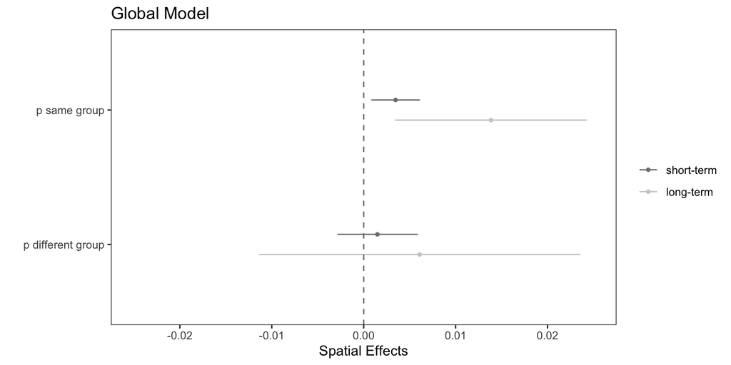

```r
# load dataset

load("./dataframe3.RData")

ggplot(dataframe3, aes(x=name, y=coefs, color=model, group=model)) +
  geom_point(size=1, position=position_dodge(width=0.3)) +
  geom_errorbar(aes(ymin=li, ymax=ui), width=.01, position=position_dodge(width=0.3)) +
  coord_flip() + theme_bw() + geom_hline(yintercept=0, linetype="dashed",
                                         color = "gray50", size=0.5) +
  ylab("Spatial Effects") + xlab("") + theme(legend.title=element_blank()) +
  scale_color_manual(values=c("gray80", "gray50"), guide = guide_legend(reverse=TRUE)) +
  theme(panel.grid.major = element_blank(), panel.grid.minor = element_blank()) + ggtitle("Global Model") +
  ylim(-0.025, 0.025)
```

## Figure 1 - right panel

The right panel in Figure 1 is based on Model D1-D4 in Table S3 which are fullt reproduced below (see Section Table S3).

To reproduce the right panel of Figure 1, the coefficients of the spatial lags are muliplied with the average number of neighbors in the same manner as before. The results of the multiplications are stored in dataframe4 in the form of estimated long-term effects for our spatial lag variables.

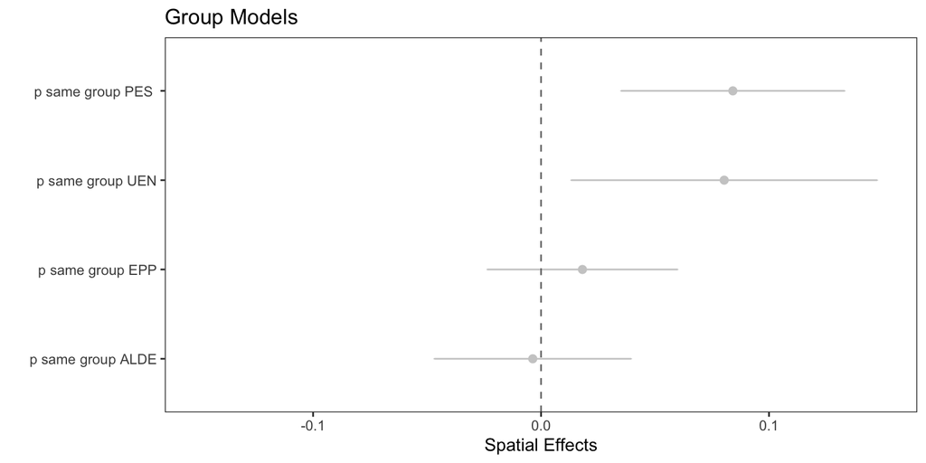

```r
# load dataset

load("./dataframe4.RData")

ggplot(dataframe4, aes(x= reorder(name, coefs), y= coefs)) +
  geom_point(size=2, position=position_dodge(width=0.3), color = "gray80") +
  geom_errorbar(aes(ymin=li, ymax=ui), width=.01, position=position_dodge(width=0.3), color = "gray80") +
  coord_flip() + theme_bw() + geom_hline(yintercept=0, linetype="dashed",
                                         color = "gray50", size=0.5) +
  ylab("Spatial Effects") + xlab("") + theme(legend.title = element_blank()) +
  theme(panel.grid.major = element_blank(), panel.grid.minor = element_blank()) + ggtitle("Group Models") +
  ylim(-0.15, 0.15)
```

# Supplementary Information

In the following, we provide the code and data to reproduce the results in the supplementary material (SI). We follow the same order as in the SI.

## Table S2

```r
# load datasets


load("./dyad_pes.RData")
load("./dyad_epp.RData")
load("./dyad_alde.RData")
load("./dyad_uen.RData")

pes <- dyad_pes %>% group_by(yearpartyidi)  %>%
  dplyr::summarize(sum = sum(samegroup_ruled))

mean(pes$sum)
```

```
## [1] 6.187805
```

```r
epp <- dyad_epp %>% group_by(yearpartyidi)  %>%
  dplyr::summarize(sum = sum(samegroup_ruled))

mean(epp$sum)
```

```
## [1] 4.076923
```

```r
alde <- dyad_alde %>% group_by(yearpartyidi)  %>%
  dplyr::summarize(sum = sum(samegroup_ruled))

mean(alde$sum)
```

```
## [1] 3.303846
```

```r
uen <- dyad_uen %>% group_by(yearpartyidi)  %>%
  dplyr::summarize(sum = sum(samegroup_ruled))

mean(uen$sum)
```

```
## [1] 0.3684211
```

## Table S3

```r
# load datasets

load("./dataframe_pes.RData")
load("./dataframe_epp.RData")
load("./dataframe_alde.RData")
load("./dataframe_uen.RData")

# increase maximum print to show full regression outputs

options(max.print=1000000)

# capture all parties minus one from colnames to include party fixed effects in the models

partyfx <- paste(colnames(dataframe_pes[24:237]), sep="")

# Model D1 in Table S3

modeld1 <- as.formula(paste("rile ~ lag_rile + lag_cmedian + lag_econ_glob + interaction + spsamegroup_ruled_sd + year_fe2 + year_fe3 + year_fe4 +  year_fe5 + year_fe6 + year_fe7 +  year_fe8 +  year_fe9 +  year_fe10 + year_fe11 + year_fe12 + year_fe13 + year_fe14 + year_fe15 + year_fe16 + year_fe17 + year_fe18 + year_fe19 + year_fe20 + year_fe21 + year_fe22 + year_fe23 + year_fe24 + year_fe25 + year_fe26 + year_fe27 + year_fe28 + year_fe29 + year_fe30 + year_fe31 + year_fe32 + year_fe33 + year_fe34 +" , paste(partyfx, collapse= "+")))

modeld1 <- lm(modeld1, data = dataframe_pes)
summary(modeld1)
```

```
##
## Call:
## lm(formula = modeld1, data = dataframe_pes)
##
## Residuals:
##      Min       1Q   Median       3Q      Max
## -1.92847 -0.09676 -0.00190  0.10785  2.07364
##
## Coefficients:
##                        Estimate Std. Error t value Pr(>|t|)
## (Intercept)          -1.0737640  0.8180360  -1.313 0.189436
## lag_rile              0.7463483  0.0129554  57.609  < 2e-16 ***
## lag_cmedian           0.4537178  0.1576983   2.877 0.004048 **
## lag_econ_glob         0.0287869  0.0112346   2.562 0.010456 *
## interaction          -0.0059622  0.0021090  -2.827 0.004736 **
## spsamegroup_ruled_sd  0.0034489  0.0010254   3.363 0.000782 ***
## year_fe2              0.0401672  0.0673101   0.597 0.550730
## year_fe3              0.0057807  0.0667143   0.087 0.930958
## year_fe4              0.0398822  0.0671133   0.594 0.552398
## year_fe5              0.1011142  0.0671633   1.505 0.132324
## year_fe6              0.1115692  0.0671845   1.661 0.096913 .
## year_fe7              0.0797141  0.0674062   1.183 0.237085
## year_fe8              0.1091119  0.0665124   1.640 0.101034
## year_fe9              0.0382157  0.0670884   0.570 0.568979
## year_fe10             0.1338767  0.0649152   2.062 0.039281 *
## year_fe11             0.1289185  0.0646374   1.994 0.046209 *
## year_fe12             0.1349040  0.0643985   2.095 0.036288 *
## year_fe13             0.1610237  0.0652669   2.467 0.013687 *
## year_fe14             0.1305669  0.0667469   1.956 0.050560 .
## year_fe15            -0.0309334  0.0676322  -0.457 0.647441
## year_fe16             0.0671835  0.0689498   0.974 0.329962
## year_fe17             0.0556650  0.0691527   0.805 0.420921
## year_fe18             0.0929018  0.0708753   1.311 0.190055
## year_fe19             0.0876361  0.0725881   1.207 0.227430
## year_fe20             0.1608173  0.0711613   2.260 0.023914 *
## year_fe21             0.1236776  0.0731487   1.691 0.091007 .
## year_fe22             0.1130511  0.0765215   1.477 0.139703
## year_fe23             0.0527484  0.0795195   0.663 0.507176
## year_fe24             0.0584918  0.0800819   0.730 0.465216
## year_fe25             0.0844279  0.0851285   0.992 0.321407
```

[output cut: 214 more lines]

```
## party_fe207           0.4186446  0.1841911   2.273 0.023119 *
## party_fe208           0.2786412  0.1582425   1.761 0.078388 .
## party_fe209           0.1261525  0.1590948   0.793 0.427890
## party_fe210           0.1828572  0.1592320   1.148 0.250928
## party_fe211           0.3151724  0.1590983   1.981 0.047703 *
## party_fe212           0.1142498  0.2460331   0.464 0.642425
## party_fe213           0.2552500  0.1593576   1.602 0.109341
## party_fe214           0.1874769  0.1591841   1.178 0.239015
## party_fe215           0.3965857  0.1602779   2.474 0.013414 *
## ---
## Signif. codes:  0 '***' 0.001 '**' 0.01 '*' 0.05 '.' 0.1 ' ' 1
##
## Residual standard error: 0.3241 on 2465 degrees of freedom
## Multiple R-squared:  0.8883, Adjusted R-squared:  0.8769
## F-statistic:  77.8 on 252 and 2465 DF,  p-value: < 2.2e-16
```

```r
stargazer(modeld1)
```

```
##
## % Table created by stargazer v.5.2.2 by Marek Hlavac, Harvard University. E-mail: hlavac at fas.harvard.edu
## % Date and time: Thu, Jul 01, 2021 - 15:52:45
## \begin{table}[!htbp] \centering
##   \caption{}
##   \label{}
## \begin{tabular}{@{\extracolsep{5pt}}lc}
## \\[-1.8ex]\hline
## \hline \\[-1.8ex]
##  & \multicolumn{1}{c}{\textit{Dependent variable:}} \\
## \cline{2-2}
## \\[-1.8ex] & rile \\
## \hline \\[-1.8ex]
##  lag\_rile & 0.746$^{***}$ \\
##   & (0.013) \\
##   & \\
##  lag\_cmedian & 0.454$^{***}$ \\
##   & (0.158) \\
##   & \\
##  lag\_econ\_glob & 0.029$^{**}$ \\
##   & (0.011) \\
##   & \\
##  interaction & $-$0.006$^{***}$ \\
##   & (0.002) \\
##   & \\
##  spsamegroup\_ruled\_sd & 0.003$^{***}$ \\
##   & (0.001) \\
##   & \\
##  year\_fe2 & 0.040 \\
##   & (0.067) \\
##   & \\
##  year\_fe3 & 0.006 \\
##   & (0.067) \\
##   & \\
##  year\_fe4 & 0.040 \\
##   & (0.067) \\
##   & \\
##  year\_fe5 & 0.101 \\
##   & (0.067) \\
##   & \\
```

[output cut: 728 more lines]

```
##   & \\
##  Constant & $-$1.074 \\
##   & (0.818) \\
##   & \\
## \hline \\[-1.8ex]
## Observations & 2,718 \\
## R$^{2}$ & 0.888 \\
## Adjusted R$^{2}$ & 0.877 \\
## Residual Std. Error & 0.324 (df = 2465) \\
## F Statistic & 77.802$^{***}$ (df = 252; 2465) \\
## \hline
## \hline \\[-1.8ex]
## \textit{Note:}  & \multicolumn{1}{r}{$^{*}$p$<$0.1; $^{**}$p$<$0.05; $^{***}$p$<$0.01} \\
## \end{tabular}
## \end{table}
```

```r
# Model D2 in Table S3

modeld2 <- as.formula(paste("rile ~ lag_rile + lag_cmedian + lag_econ_glob + interaction + spsamegroup_ruled_epp + year_fe2 + year_fe3 + year_fe4 +  year_fe5 + year_fe6 + year_fe7 +  year_fe8 +  year_fe9 +  year_fe10 + year_fe11 + year_fe12 + year_fe13 + year_fe14 + year_fe15 + year_fe16 + year_fe17 + year_fe18 + year_fe19 + year_fe20 + year_fe21 + year_fe22 + year_fe23 + year_fe24 + year_fe25 + year_fe26 + year_fe27 + year_fe28 + year_fe29 + year_fe30 + year_fe31 + year_fe32 + year_fe33 + year_fe34 +" , paste(partyfx, collapse= "+")))

modeld2 <- lm(modeld2, data = dataframe_epp)
summary(modeld2)
```

```
##
## Call:
## lm(formula = modeld2, data = dataframe_epp)
##
## Residuals:
##      Min       1Q   Median       3Q      Max
## -1.93597 -0.09808 -0.00085  0.10741  2.08533
##
## Coefficients:
##                         Estimate Std. Error t value Pr(>|t|)
## (Intercept)           -1.0213909  0.8196406  -1.246 0.212830
## lag_rile               0.7515888  0.0128946  58.287  < 2e-16 ***
## lag_cmedian            0.4377856  0.1579642   2.771 0.005623 **
## lag_econ_glob          0.0276281  0.0112532   2.455 0.014152 *
## interaction           -0.0057997  0.0021129  -2.745 0.006098 **
## spsamegroup_ruled_epp  0.0011061  0.0012967   0.853 0.393721
## year_fe2               0.0411344  0.0674542   0.610 0.542042
## year_fe3               0.0176869  0.0667636   0.265 0.791095
## year_fe4               0.0539942  0.0671258   0.804 0.421259
## year_fe5               0.1102727  0.0672505   1.640 0.101189
## year_fe6               0.1212430  0.0672640   1.802 0.071590 .
## year_fe7               0.0891862  0.0674890   1.321 0.186460
## year_fe8               0.1153812  0.0666271   1.732 0.083444 .
## year_fe9               0.0443613  0.0672058   0.660 0.509263
## year_fe10              0.1419152  0.0650089   2.183 0.029129 *
## year_fe11              0.1370399  0.0647276   2.117 0.034345 *
## year_fe12              0.1430418  0.0644879   2.218 0.026637 *
## year_fe13              0.1724675  0.0653134   2.641 0.008328 **
## year_fe14              0.1379973  0.0668571   2.064 0.039116 *
## year_fe15             -0.0182990  0.0676861  -0.270 0.786913
## year_fe16              0.0840277  0.0689313   1.219 0.222958
## year_fe17              0.0732347  0.0691192   1.060 0.289457
## year_fe18              0.1098026  0.0711373   1.544 0.122830
## year_fe19              0.1101705  0.0726018   1.517 0.129278
## year_fe20              0.1803396  0.0712683   2.530 0.011454 *
## year_fe21              0.1436173  0.0732414   1.961 0.050006 .
## year_fe22              0.1373266  0.0764571   1.796 0.072597 .
## year_fe23              0.0936381  0.0787076   1.190 0.234281
## year_fe24              0.0979897  0.0793444   1.235 0.216951
## year_fe25              0.1287393  0.0842363   1.528 0.126563
```

[output cut: 214 more lines]

```
## party_fe207            0.4077959  0.1845564   2.210 0.027225 *
## party_fe208            0.2706025  0.1585656   1.707 0.088029 .
## party_fe209            0.1196267  0.1594246   0.750 0.453106
## party_fe210            0.1753561  0.1595585   1.099 0.271872
## party_fe211            0.3086184  0.1594280   1.936 0.053008 .
## party_fe212            0.0998583  0.2465260   0.405 0.685467
## party_fe213            0.2470240  0.1596813   1.547 0.121996
## party_fe214            0.1802885  0.1595117   1.130 0.258480
## party_fe215            0.3847563  0.1605848   2.396 0.016651 *
## ---
## Signif. codes:  0 '***' 0.001 '**' 0.01 '*' 0.05 '.' 0.1 ' ' 1
##
## Residual standard error: 0.3248 on 2465 degrees of freedom
## Multiple R-squared:  0.8878, Adjusted R-squared:  0.8764
## F-statistic: 77.43 on 252 and 2465 DF,  p-value: < 2.2e-16
```

```r
stargazer(modeld2)
```

```
##
## % Table created by stargazer v.5.2.2 by Marek Hlavac, Harvard University. E-mail: hlavac at fas.harvard.edu
## % Date and time: Thu, Jul 01, 2021 - 15:52:46
## \begin{table}[!htbp] \centering
##   \caption{}
##   \label{}
## \begin{tabular}{@{\extracolsep{5pt}}lc}
## \\[-1.8ex]\hline
## \hline \\[-1.8ex]
##  & \multicolumn{1}{c}{\textit{Dependent variable:}} \\
## \cline{2-2}
## \\[-1.8ex] & rile \\
## \hline \\[-1.8ex]
##  lag\_rile & 0.752$^{***}$ \\
##   & (0.013) \\
##   & \\
##  lag\_cmedian & 0.438$^{***}$ \\
##   & (0.158) \\
##   & \\
##  lag\_econ\_glob & 0.028$^{**}$ \\
##   & (0.011) \\
##   & \\
##  interaction & $-$0.006$^{***}$ \\
##   & (0.002) \\
##   & \\
##  spsamegroup\_ruled\_epp & 0.001 \\
##   & (0.001) \\
##   & \\
##  year\_fe2 & 0.041 \\
##   & (0.067) \\
##   & \\
##  year\_fe3 & 0.018 \\
##   & (0.067) \\
##   & \\
##  year\_fe4 & 0.054 \\
##   & (0.067) \\
##   & \\
##  year\_fe5 & 0.110 \\
##   & (0.067) \\
##   & \\
```

[output cut: 728 more lines]

```
##   & \\
##  Constant & $-$1.021 \\
##   & (0.820) \\
##   & \\
## \hline \\[-1.8ex]
## Observations & 2,718 \\
## R$^{2}$ & 0.888 \\
## Adjusted R$^{2}$ & 0.876 \\
## Residual Std. Error & 0.325 (df = 2465) \\
## F Statistic & 77.428$^{***}$ (df = 252; 2465) \\
## \hline
## \hline \\[-1.8ex]
## \textit{Note:}  & \multicolumn{1}{r}{$^{*}$p$<$0.1; $^{**}$p$<$0.05; $^{***}$p$<$0.01} \\
## \end{tabular}
## \end{table}
```

```r
# Model D3 in Table S3

modeld3 <- as.formula(paste("rile ~ lag_rile + lag_cmedian + lag_econ_glob + interaction + spsamegroup_ruled_lib + year_fe2 + year_fe3 + year_fe4 +  year_fe5 + year_fe6 +  year_fe7 +  year_fe8 +  year_fe9 +  year_fe10 + year_fe11 + year_fe12 + year_fe13 + year_fe14 + year_fe15 + year_fe16 + year_fe17 + year_fe18 + year_fe19 + year_fe20 + year_fe21 + year_fe22 + year_fe23 + year_fe24 + year_fe25 + year_fe26 + year_fe27 + year_fe28 + year_fe29 + year_fe30 + year_fe31 + year_fe32 + year_fe33 + year_fe34 +" , paste(partyfx, collapse= "+")))

modeld3 <- lm(modeld3, data = dataframe_alde)
summary(modeld3)
```

```
##
## Call:
## lm(formula = modeld3, data = dataframe_alde)
##
## Residuals:
##      Min       1Q   Median       3Q      Max
## -1.93555 -0.09654 -0.00154  0.10599  2.08630
##
## Coefficients:
##                         Estimate Std. Error t value Pr(>|t|)
## (Intercept)           -1.0159861  0.8203779  -1.238 0.215672
## lag_rile               0.7515878  0.0129199  58.173  < 2e-16 ***
## lag_cmedian            0.4367465  0.1580875   2.763 0.005775 **
## lag_econ_glob          0.0274905  0.0112752   2.438 0.014833 *
## interaction           -0.0057828  0.0021153  -2.734 0.006307 **
## spsamegroup_ruled_lib -0.0002738  0.0016553  -0.165 0.868623
## year_fe2               0.0410143  0.0674636   0.608 0.543278
## year_fe3               0.0180231  0.0668097   0.270 0.787362
## year_fe4               0.0544976  0.0672066   0.811 0.417503
## year_fe5               0.1109166  0.0673309   1.647 0.099616 .
## year_fe6               0.1219412  0.0673230   1.811 0.070218 .
## year_fe7               0.0897872  0.0675254   1.330 0.183746
## year_fe8               0.1162385  0.0666617   1.744 0.081335 .
## year_fe9               0.0454998  0.0672971   0.676 0.499038
## year_fe10              0.1426009  0.0651021   2.190 0.028587 *
## year_fe11              0.1383835  0.0649029   2.132 0.033092 *
## year_fe12              0.1444032  0.0646371   2.234 0.025569 *
## year_fe13              0.1742211  0.0653900   2.664 0.007764 **
## year_fe14              0.1399891  0.0669708   2.090 0.036693 *
## year_fe15             -0.0150341  0.0678634  -0.222 0.824695
## year_fe16              0.0879250  0.0691076   1.272 0.203390
## year_fe17              0.0772412  0.0693020   1.115 0.265148
## year_fe18              0.1179346  0.0710515   1.660 0.097072 .
## year_fe19              0.1173169  0.0724815   1.619 0.105666
## year_fe20              0.1876557  0.0712603   2.633 0.008507 **
## year_fe21              0.1508955  0.0732683   2.059 0.039552 *
## year_fe22              0.1445842  0.0767441   1.884 0.059686 .
## year_fe23              0.0961807  0.0790753   1.216 0.223981
## year_fe24              0.1004853  0.0797236   1.260 0.207637
## year_fe25              0.1313835  0.0846470   1.552 0.120759
```

[output cut: 214 more lines]

```
## party_fe207            0.4067288  0.1846426   2.203 0.027702 *
## party_fe208            0.2703025  0.1586334   1.704 0.088518 .
## party_fe209            0.1189856  0.1595148   0.746 0.455785
## party_fe210            0.1747152  0.1596530   1.094 0.273911
## party_fe211            0.3117254  0.1604643   1.943 0.052173 .
## party_fe212            0.0964749  0.2466145   0.391 0.695685
## party_fe213            0.2463832  0.1597791   1.542 0.123196
## party_fe214            0.1796476  0.1596048   1.126 0.260454
## party_fe215            0.3841162  0.1606997   2.390 0.016911 *
## ---
## Signif. codes:  0 '***' 0.001 '**' 0.01 '*' 0.05 '.' 0.1 ' ' 1
##
## Residual standard error: 0.3248 on 2465 degrees of freedom
## Multiple R-squared:  0.8878, Adjusted R-squared:  0.8763
## F-statistic:  77.4 on 252 and 2465 DF,  p-value: < 2.2e-16
```

```r
stargazer(modeld3)
```

```
##
## % Table created by stargazer v.5.2.2 by Marek Hlavac, Harvard University. E-mail: hlavac at fas.harvard.edu
## % Date and time: Thu, Jul 01, 2021 - 15:52:47
## \begin{table}[!htbp] \centering
##   \caption{}
##   \label{}
## \begin{tabular}{@{\extracolsep{5pt}}lc}
## \\[-1.8ex]\hline
## \hline \\[-1.8ex]
##  & \multicolumn{1}{c}{\textit{Dependent variable:}} \\
## \cline{2-2}
## \\[-1.8ex] & rile \\
## \hline \\[-1.8ex]
##  lag\_rile & 0.752$^{***}$ \\
##   & (0.013) \\
##   & \\
##  lag\_cmedian & 0.437$^{***}$ \\
##   & (0.158) \\
##   & \\
##  lag\_econ\_glob & 0.027$^{**}$ \\
##   & (0.011) \\
##   & \\
##  interaction & $-$0.006$^{***}$ \\
##   & (0.002) \\
##   & \\
##  spsamegroup\_ruled\_lib & $-$0.0003 \\
##   & (0.002) \\
##   & \\
##  year\_fe2 & 0.041 \\
##   & (0.067) \\
##   & \\
##  year\_fe3 & 0.018 \\
##   & (0.067) \\
##   & \\
##  year\_fe4 & 0.054 \\
##   & (0.067) \\
##   & \\
##  year\_fe5 & 0.111$^{*}$ \\
##   & (0.067) \\
##   & \\
```

[output cut: 728 more lines]

```
##   & \\
##  Constant & $-$1.016 \\
##   & (0.820) \\
##   & \\
## \hline \\[-1.8ex]
## Observations & 2,718 \\
## R$^{2}$ & 0.888 \\
## Adjusted R$^{2}$ & 0.876 \\
## Residual Std. Error & 0.325 (df = 2465) \\
## F Statistic & 77.403$^{***}$ (df = 252; 2465) \\
## \hline
## \hline \\[-1.8ex]
## \textit{Note:}  & \multicolumn{1}{r}{$^{*}$p$<$0.1; $^{**}$p$<$0.05; $^{***}$p$<$0.01} \\
## \end{tabular}
## \end{table}
```

```r
# Model D4 in Table S3

modeld4 <- as.formula(paste("rile ~ lag_rile + lag_cmedian + lag_econ_glob + interaction + spsamegroup_ruled_uen + year_fe2 + year_fe3 + year_fe4 +  year_fe5 + year_fe6 +  year_fe7 +  year_fe8 +  year_fe9 +  year_fe10 + year_fe11 + year_fe12 + year_fe13 + year_fe14 + year_fe15 + year_fe16 + year_fe17 + year_fe18 + year_fe19 + year_fe20 + year_fe21 + year_fe22 + year_fe23 + year_fe24 + year_fe25 + year_fe26 + year_fe27 + year_fe28 + year_fe29 + year_fe30 + year_fe31 + year_fe32 + year_fe33 + year_fe34 +" , paste(partyfx, collapse= "+")))

modeld4 <- lm(modeld4, data = dataframe_uen)
summary(modeld4)
```

```
##
## Call:
## lm(formula = modeld4, data = dataframe_uen)
##
## Residuals:
##      Min       1Q   Median       3Q      Max
## -1.93189 -0.09743 -0.00206  0.10688  2.13274
##
## Coefficients:
##                         Estimate Std. Error t value Pr(>|t|)
## (Intercept)           -0.8558258  0.8218760  -1.041 0.297835
## lag_rile               0.7503833  0.0128892  58.218  < 2e-16 ***
## lag_cmedian            0.4103383  0.1582407   2.593 0.009567 **
## lag_econ_glob          0.0256503  0.0112730   2.275 0.022968 *
## interaction           -0.0054646  0.0021157  -2.583 0.009854 **
## spsamegroup_ruled_uen  0.0544334  0.0231940   2.347 0.019011 *
## year_fe2               0.0409039  0.0673887   0.607 0.543917
## year_fe3               0.0177816  0.0666990   0.267 0.789804
## year_fe4               0.0538030  0.0670609   0.802 0.422456
## year_fe5               0.1112451  0.0671862   1.656 0.097895 .
## year_fe6               0.1224996  0.0671995   1.823 0.068436 .
## year_fe7               0.0904731  0.0674243   1.342 0.179769
## year_fe8               0.1170096  0.0665612   1.758 0.078885 .
## year_fe9               0.0463013  0.0671399   0.690 0.490495
## year_fe10              0.1433301  0.0649480   2.207 0.027417 *
## year_fe11              0.1384701  0.0646626   2.141 0.032337 *
## year_fe12              0.1445794  0.0644221   2.244 0.024905 *
## year_fe13              0.1746766  0.0652362   2.678 0.007464 **
## year_fe14              0.1404074  0.0667760   2.103 0.035597 *
## year_fe15             -0.0145089  0.0675672  -0.215 0.829994
## year_fe16              0.0885836  0.0687830   1.288 0.197912
## year_fe17              0.0779974  0.0689664   1.131 0.258187
## year_fe18              0.1184411  0.0706067   1.677 0.093576 .
## year_fe19              0.1181454  0.0721727   1.637 0.101762
## year_fe20              0.1880439  0.0708368   2.655 0.007991 **
## year_fe21              0.1514498  0.0728279   2.080 0.037669 *
## year_fe22              0.1452631  0.0760954   1.909 0.056383 .
## year_fe23              0.0941309  0.0786179   1.197 0.231296
## year_fe24              0.0984850  0.0792555   1.243 0.214124
## year_fe25              0.1332563  0.0841531   1.583 0.113436
```

[output cut: 214 more lines]

```
## party_fe207            0.4083749  0.1843779   2.215 0.026859 *
## party_fe208            0.2723194  0.1584127   1.719 0.085731 .
## party_fe209            0.1188853  0.1592706   0.746 0.455476
## party_fe210            0.1748390  0.1594042   1.097 0.272824
## party_fe211            0.3078834  0.1592740   1.933 0.053345 .
## party_fe212            0.0953698  0.2462727   0.387 0.698603
## party_fe213            0.2466736  0.1595268   1.546 0.122165
## party_fe214            0.1796995  0.1593575   1.128 0.259577
## party_fe215            0.3852348  0.1604291   2.401 0.016412 *
## ---
## Signif. codes:  0 '***' 0.001 '**' 0.01 '*' 0.05 '.' 0.1 ' ' 1
##
## Residual standard error: 0.3245 on 2465 degrees of freedom
## Multiple R-squared:  0.8881, Adjusted R-squared:  0.8766
## F-statistic:  77.6 on 252 and 2465 DF,  p-value: < 2.2e-16
```

```r
stargazer(modeld4)
```

```
##
## % Table created by stargazer v.5.2.2 by Marek Hlavac, Harvard University. E-mail: hlavac at fas.harvard.edu
## % Date and time: Thu, Jul 01, 2021 - 15:52:47
## \begin{table}[!htbp] \centering
##   \caption{}
##   \label{}
## \begin{tabular}{@{\extracolsep{5pt}}lc}
## \\[-1.8ex]\hline
## \hline \\[-1.8ex]
##  & \multicolumn{1}{c}{\textit{Dependent variable:}} \\
## \cline{2-2}
## \\[-1.8ex] & rile \\
## \hline \\[-1.8ex]
##  lag\_rile & 0.750$^{***}$ \\
##   & (0.013) \\
##   & \\
##  lag\_cmedian & 0.410$^{***}$ \\
##   & (0.158) \\
##   & \\
##  lag\_econ\_glob & 0.026$^{**}$ \\
##   & (0.011) \\
##   & \\
##  interaction & $-$0.005$^{***}$ \\
##   & (0.002) \\
##   & \\
##  spsamegroup\_ruled\_uen & 0.054$^{**}$ \\
##   & (0.023) \\
##   & \\
##  year\_fe2 & 0.041 \\
##   & (0.067) \\
##   & \\
##  year\_fe3 & 0.018 \\
##   & (0.067) \\
##   & \\
##  year\_fe4 & 0.054 \\
##   & (0.067) \\
##   & \\
##  year\_fe5 & 0.111$^{*}$ \\
##   & (0.067) \\
##   & \\
```

[output cut: 728 more lines]

```
##   & \\
##  Constant & $-$0.856 \\
##   & (0.822) \\
##   & \\
## \hline \\[-1.8ex]
## Observations & 2,718 \\
## R$^{2}$ & 0.888 \\
## Adjusted R$^{2}$ & 0.877 \\
## Residual Std. Error & 0.324 (df = 2465) \\
## F Statistic & 77.597$^{***}$ (df = 252; 2465) \\
## \hline
## \hline \\[-1.8ex]
## \textit{Note:}  & \multicolumn{1}{r}{$^{*}$p$<$0.1; $^{**}$p$<$0.05; $^{***}$p$<$0.01} \\
## \end{tabular}
## \end{table}
```

## Table S4

```r
# load dataset

load("./dataframe_soc.RData")

# increase maximum print to show full regression outputs

options(max.print=1000000)

# capture all parties minus one from colnames to include party fixed effects in the models

partyfx <- paste(colnames(dataframe_pes[24:237]), sep="")

# Model 1 in Table S4

model1 <- as.formula(paste("rile ~ lag_rile + lag_cmedian + lag_econ_glob + interaction + spsameparfam_soc + year_fe2 + year_fe3 + year_fe4 +  year_fe5 + year_fe6 +
year_fe7 +  year_fe8 +  year_fe9 +  year_fe10 + year_fe11 + year_fe12 + year_fe13 + year_fe14 + year_fe15 + year_fe16 + year_fe17 + year_fe18 +
                          year_fe19 + year_fe20 + year_fe21 + year_fe22 + year_fe23 + year_fe24 + year_fe25 + year_fe26 + year_fe27 + year_fe28 + year_fe29 + year_fe30 +
                          year_fe31 + year_fe32 + year_fe33 + year_fe34 +" , paste(partyfx, collapse= "+")))

model1 <- lm(model1, data = dataframe_soc)
summary(model1)
```

```
##
## Call:
## lm(formula = model1, data = dataframe_soc)
##
## Residuals:
##      Min       1Q   Median       3Q      Max
## -1.93364 -0.09661 -0.00151  0.10606  2.08654
##
## Coefficients:
##                    Estimate Std. Error t value Pr(>|t|)
## (Intercept)      -1.021e+00  8.198e-01  -1.246 0.212875
## lag_rile          7.515e-01  1.290e-02  58.272  < 2e-16 ***
## lag_cmedian       4.378e-01  1.580e-01   2.771 0.005637 **
## lag_econ_glob     2.761e-02  1.126e-02   2.453 0.014242 *
## interaction      -5.800e-03  2.114e-03  -2.744 0.006114 **
## spsameparfam_soc  6.528e-06  1.653e-04   0.039 0.968511
## year_fe2          4.051e-02  6.865e-02   0.590 0.555246
## year_fe3          1.742e-02  6.705e-02   0.260 0.795061
## year_fe4          5.399e-02  6.714e-02   0.804 0.421334
## year_fe5          1.104e-01  6.726e-02   1.642 0.100812
## year_fe6          1.212e-01  6.772e-02   1.790 0.073603 .
## year_fe7          8.949e-02  6.750e-02   1.326 0.185052
## year_fe8          1.159e-01  6.664e-02   1.739 0.082150 .
## year_fe9          4.438e-02  6.868e-02   0.646 0.518234
## year_fe10         1.419e-01  6.513e-02   2.179 0.029443 *
## year_fe11         1.373e-01  6.521e-02   2.106 0.035336 *
## year_fe12         1.437e-01  6.450e-02   2.227 0.026009 *
## year_fe13         1.734e-01  6.567e-02   2.641 0.008330 **
## year_fe14         1.391e-01  6.703e-02   2.075 0.038052 *
## year_fe15        -1.614e-02  6.783e-02  -0.238 0.811890
## year_fe16         8.676e-02  6.902e-02   1.257 0.208819
## year_fe17         7.620e-02  6.905e-02   1.104 0.269893
## year_fe18         1.165e-01  7.094e-02   1.642 0.100662
## year_fe19         1.161e-01  7.260e-02   1.599 0.109994
## year_fe20         1.865e-01  7.092e-02   2.630 0.008588 **
## year_fe21         1.494e-01  7.316e-02   2.043 0.041178 *
## year_fe22         1.430e-01  7.620e-02   1.876 0.060745 .
## year_fe23         9.490e-02  7.871e-02   1.206 0.228017
## year_fe24         9.906e-02  7.942e-02   1.247 0.212448
## year_fe25         1.298e-01  8.441e-02   1.538 0.124260
```

[output cut: 214 more lines]

```
## party_fe207       4.074e-01  1.846e-01   2.207 0.027409 *
## party_fe208       2.709e-01  1.586e-01   1.708 0.087733 .
## party_fe209       1.197e-01  1.595e-01   0.751 0.452837
## party_fe210       1.755e-01  1.596e-01   1.099 0.271666
## party_fe211       3.088e-01  1.595e-01   1.937 0.052898 .
## party_fe212       9.758e-02  2.466e-01   0.396 0.692325
## party_fe213       2.473e-01  1.597e-01   1.548 0.121690
## party_fe214       1.805e-01  1.596e-01   1.131 0.257965
## party_fe215       3.851e-01  1.606e-01   2.398 0.016578 *
## ---
## Signif. codes:  0 '***' 0.001 '**' 0.01 '*' 0.05 '.' 0.1 ' ' 1
##
## Residual standard error: 0.3248 on 2465 degrees of freedom
## Multiple R-squared:  0.8878, Adjusted R-squared:  0.8763
## F-statistic:  77.4 on 252 and 2465 DF,  p-value: < 2.2e-16
```

```r
stargazer(model1)
```

```
##
## % Table created by stargazer v.5.2.2 by Marek Hlavac, Harvard University. E-mail: hlavac at fas.harvard.edu
## % Date and time: Thu, Jul 01, 2021 - 15:52:48
## \begin{table}[!htbp] \centering
##   \caption{}
##   \label{}
## \begin{tabular}{@{\extracolsep{5pt}}lc}
## \\[-1.8ex]\hline
## \hline \\[-1.8ex]
##  & \multicolumn{1}{c}{\textit{Dependent variable:}} \\
## \cline{2-2}
## \\[-1.8ex] & rile \\
## \hline \\[-1.8ex]
##  lag\_rile & 0.751$^{***}$ \\
##   & (0.013) \\
##   & \\
##  lag\_cmedian & 0.438$^{***}$ \\
##   & (0.158) \\
##   & \\
##  lag\_econ\_glob & 0.028$^{**}$ \\
##   & (0.011) \\
##   & \\
##  interaction & $-$0.006$^{***}$ \\
##   & (0.002) \\
##   & \\
##  spsameparfam\_soc & 0.00001 \\
##   & (0.0002) \\
##   & \\
##  year\_fe2 & 0.041 \\
##   & (0.069) \\
##   & \\
##  year\_fe3 & 0.017 \\
##   & (0.067) \\
##   & \\
##  year\_fe4 & 0.054 \\
##   & (0.067) \\
##   & \\
##  year\_fe5 & 0.110 \\
##   & (0.067) \\
##   & \\
```

[output cut: 728 more lines]

```
##   & \\
##  Constant & $-$1.021 \\
##   & (0.820) \\
##   & \\
## \hline \\[-1.8ex]
## Observations & 2,718 \\
## R$^{2}$ & 0.888 \\
## Adjusted R$^{2}$ & 0.876 \\
## Residual Std. Error & 0.325 (df = 2465) \\
## F Statistic & 77.402$^{***}$ (df = 252; 2465) \\
## \hline
## \hline \\[-1.8ex]
## \textit{Note:}  & \multicolumn{1}{r}{$^{*}$p$<$0.1; $^{**}$p$<$0.05; $^{***}$p$<$0.01} \\
## \end{tabular}
## \end{table}
```

```r
#Model 2 in Table S4

model2 <- as.formula(paste("rile ~ lag_rile + lag_cmedian + lag_econ_glob + interaction + spsameparfam_ruled_soc + year_fe2 + year_fe3 + year_fe4 +  year_fe5 + year_fe6 +
year_fe7 +  year_fe8 +  year_fe9 +  year_fe10 + year_fe11 + year_fe12 + year_fe13 + year_fe14 + year_fe15 + year_fe16 + year_fe17 + year_fe18 +
                          year_fe19 + year_fe20 + year_fe21 + year_fe22 + year_fe23 + year_fe24 + year_fe25 + year_fe26 + year_fe27 + year_fe28 + year_fe29 + year_fe30 +
                          year_fe31 + year_fe32 + year_fe33 + year_fe34 +" , paste(partyfx, collapse= "+")))

model2 <- lm(model2, data = dataframe_soc)
summary(model2)
```

```
##
## Call:
## lm(formula = model2, data = dataframe_soc)
##
## Residuals:
##      Min       1Q   Median       3Q      Max
## -1.93559 -0.09673 -0.00212  0.10640  2.08271
##
## Coefficients:
##                          Estimate Std. Error t value Pr(>|t|)
## (Intercept)            -1.0068658  0.8199775  -1.228 0.219595
## lag_rile                0.7513480  0.0128954  58.265  < 2e-16 ***
## lag_cmedian             0.4338706  0.1580783   2.745 0.006101 **
## lag_econ_glob           0.0274144  0.0112574   2.435 0.014952 *
## interaction            -0.0057453  0.0021146  -2.717 0.006634 **
## spsameparfam_ruled_soc -0.0002503  0.0003782  -0.662 0.508161
## year_fe2                0.0485972  0.0684255   0.710 0.477634
## year_fe3                0.0207982  0.0669360   0.311 0.756042
## year_fe4                0.0537069  0.0671310   0.800 0.423770
## year_fe5                0.1101911  0.0672550   1.638 0.101465
## year_fe6                0.1259751  0.0676045   1.863 0.062523 .
## year_fe7                0.0889818  0.0674962   1.318 0.187518
## year_fe8                0.1160487  0.0666283   1.742 0.081680 .
## year_fe9                0.0523481  0.0681322   0.768 0.442364
## year_fe10               0.1446780  0.0651333   2.221 0.026424 *
## year_fe11               0.1420423  0.0650739   2.183 0.029146 *
## year_fe12               0.1440522  0.0644896   2.234 0.025590 *
## year_fe13               0.1778205  0.0656013   2.711 0.006762 **
## year_fe14               0.1422649  0.0669910   2.124 0.033799 *
## year_fe15              -0.0137968  0.0677117  -0.204 0.838559
## year_fe16               0.0894148  0.0689508   1.297 0.194824
## year_fe17               0.0766746  0.0690363   1.111 0.266831
## year_fe18               0.1200916  0.0708571   1.695 0.090231 .
## year_fe19               0.1204056  0.0725014   1.661 0.096894 .
## year_fe20               0.1857036  0.0709165   2.619 0.008883 **
## year_fe21               0.1523097  0.0730063   2.086 0.037058 *
## year_fe22               0.1440270  0.0761823   1.891 0.058801 .
## year_fe23               0.0942125  0.0787051   1.197 0.231410
## year_fe24               0.1008544  0.0793759   1.271 0.203994
## year_fe25               0.1322342  0.0842956   1.569 0.116847
```

[output cut: 214 more lines]

```
## party_fe207             0.4088270  0.1845777   2.215 0.026856 *
## party_fe208             0.2715385  0.1585771   1.712 0.086959 .
## party_fe209             0.1204001  0.1594369   0.755 0.450226
## party_fe210             0.1767517  0.1595789   1.108 0.268137
## party_fe211             0.3074263  0.1594497   1.928 0.053964 .
## party_fe212             0.0955883  0.2465402   0.388 0.698258
## party_fe213             0.2459087  0.1597024   1.540 0.123739
## party_fe214             0.1791256  0.1595332   1.123 0.261627
## party_fe215             0.3838066  0.1606044   2.390 0.016934 *
## ---
## Signif. codes:  0 '***' 0.001 '**' 0.01 '*' 0.05 '.' 0.1 ' ' 1
##
## Residual standard error: 0.3248 on 2465 degrees of freedom
## Multiple R-squared:  0.8878, Adjusted R-squared:  0.8764
## F-statistic: 77.42 on 252 and 2465 DF,  p-value: < 2.2e-16
```

```r
stargazer(model2)
```

```
##
## % Table created by stargazer v.5.2.2 by Marek Hlavac, Harvard University. E-mail: hlavac at fas.harvard.edu
## % Date and time: Thu, Jul 01, 2021 - 15:52:49
## \begin{table}[!htbp] \centering
##   \caption{}
##   \label{}
## \begin{tabular}{@{\extracolsep{5pt}}lc}
## \\[-1.8ex]\hline
## \hline \\[-1.8ex]
##  & \multicolumn{1}{c}{\textit{Dependent variable:}} \\
## \cline{2-2}
## \\[-1.8ex] & rile \\
## \hline \\[-1.8ex]
##  lag\_rile & 0.751$^{***}$ \\
##   & (0.013) \\
##   & \\
##  lag\_cmedian & 0.434$^{***}$ \\
##   & (0.158) \\
##   & \\
##  lag\_econ\_glob & 0.027$^{**}$ \\
##   & (0.011) \\
##   & \\
##  interaction & $-$0.006$^{***}$ \\
##   & (0.002) \\
##   & \\
##  spsameparfam\_ruled\_soc & $-$0.0003 \\
##   & (0.0004) \\
##   & \\
##  year\_fe2 & 0.049 \\
##   & (0.068) \\
##   & \\
##  year\_fe3 & 0.021 \\
##   & (0.067) \\
##   & \\
##  year\_fe4 & 0.054 \\
##   & (0.067) \\
##   & \\
##  year\_fe5 & 0.110 \\
##   & (0.067) \\
##   & \\
```

[output cut: 728 more lines]

```
##   & \\
##  Constant & $-$1.007 \\
##   & (0.820) \\
##   & \\
## \hline \\[-1.8ex]
## Observations & 2,718 \\
## R$^{2}$ & 0.888 \\
## Adjusted R$^{2}$ & 0.876 \\
## Residual Std. Error & 0.325 (df = 2465) \\
## F Statistic & 77.418$^{***}$ (df = 252; 2465) \\
## \hline
## \hline \\[-1.8ex]
## \textit{Note:}  & \multicolumn{1}{r}{$^{*}$p$<$0.1; $^{**}$p$<$0.05; $^{***}$p$<$0.01} \\
## \end{tabular}
## \end{table}
```

## Figure S2

```r
# load datasets

load("./dataframe_zelig.RData")

# left panel

model1 <- as.formula(paste("rile ~ lag_rile + lag_cmedian + lag_econ_glob + interaction + spsamegroup_ruled + year_fe2 + year_fe3 + year_fe4 +  year_fe5 + year_fe6 + year_fe7 +  year_fe8 +  year_fe9 +  year_fe10 + year_fe11 + year_fe12 + year_fe13 + year_fe14 + year_fe15 + year_fe16 + year_fe17 + year_fe18 +
year_fe19 + year_fe20 + year_fe21 + year_fe22 + year_fe23 + year_fe24 + year_fe25 + year_fe26 + year_fe27 + year_fe28 + year_fe29 + year_fe30 + year_fe31 + year_fe32 + year_fe33 + year_fe34 +" , paste(partyfx, collapse= "+")))

z1 <- zelig(model1, data = dataframe_zelig, model = "ls")
```

```
## How to cite this model in Zelig:
##   R Core Team. 2007.
##   ls: Least Squares Regression for Continuous Dependent Variables
##   in Christine Choirat, Christopher Gandrud, James Honaker, Kosuke Imai, Gary King, and Olivia Lau,
##   "Zelig: Everyone's Statistical Software," https://zeligproject.org/
```

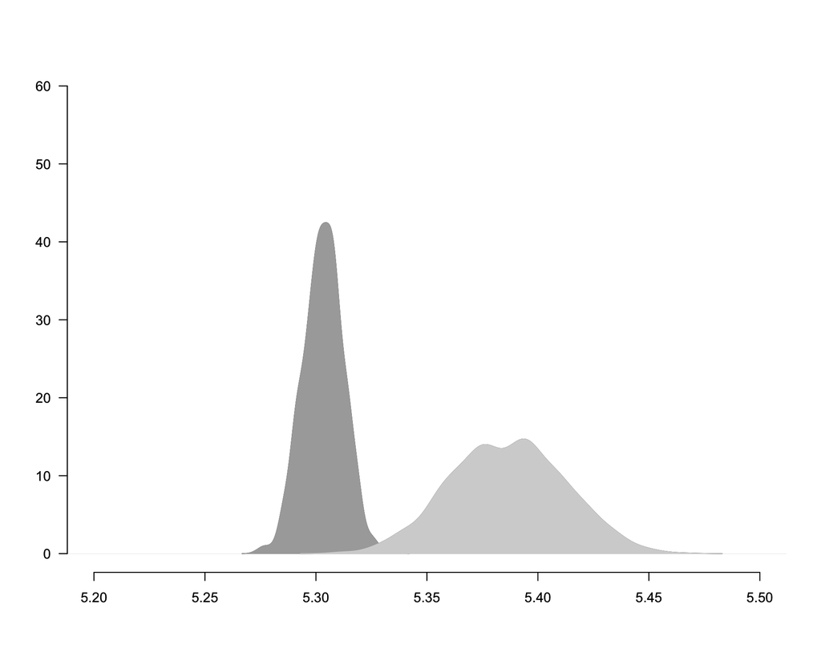

```r
z1 <- setx(z1, spsamegroup_ruled  = 0.00)
z1 <- setx1(z1, spsamegroup_ruled = 47.39)
z1.out <- sim(z1)

x <- z1.out$get_qi(qi = "ev", xvalue="x")
x1 <- z1.out$get_qi(qi = "ev", xvalue="x1")

y <- x-x1

xd <- density(x)
xd1 <- density(x1)

plot(xd, main="", sub="",
     xlab="", ylab="",frame.plot=FALSE,
     xlim=c(5.2, 5.5), ylim=c(0, 60), cex.axis=1, las=1)
par(new= TRUE)
plot(xd1, main="", sub="",
     xlab="", ylab="",frame.plot=FALSE,
     xlim=c(5.2, 5.5), ylim=c(0, 60), cex.axis=1, las=1)
polygon(xd, col = "darkgray", border = "darkgray")
par(new= TRUE)
polygon(xd1, col = "lightgray", border = "lightgray")
```

```r
# left panel

model2 <- as.formula(paste("rile ~ lag_rile + lag_cmedian + lag_econ_glob + interaction + spdiffgroup_ruled + year_fe2 + year_fe3 + year_fe4 +  year_fe5 + year_fe6 + year_fe7 +  year_fe8 +  year_fe9 +  year_fe10 + year_fe11 + year_fe12 + year_fe13 + year_fe14 + year_fe15 + year_fe16 + year_fe17 + year_fe18 +
year_fe19 + year_fe20 + year_fe21 + year_fe22 + year_fe23 + year_fe24 + year_fe25 + year_fe26 + year_fe27 + year_fe28 + year_fe29 + year_fe30 + year_fe31 + year_fe32 + year_fe33 + year_fe34 +" , paste(partyfx, collapse= "+")))

z1 <- zelig(model2, data = dataframe_zelig, model = "ls")
```

```
## How to cite this model in Zelig:
##   R Core Team. 2007.
##   ls: Least Squares Regression for Continuous Dependent Variables
##   in Christine Choirat, Christopher Gandrud, James Honaker, Kosuke Imai, Gary King, and Olivia Lau,
##   "Zelig: Everyone's Statistical Software," https://zeligproject.org/
```

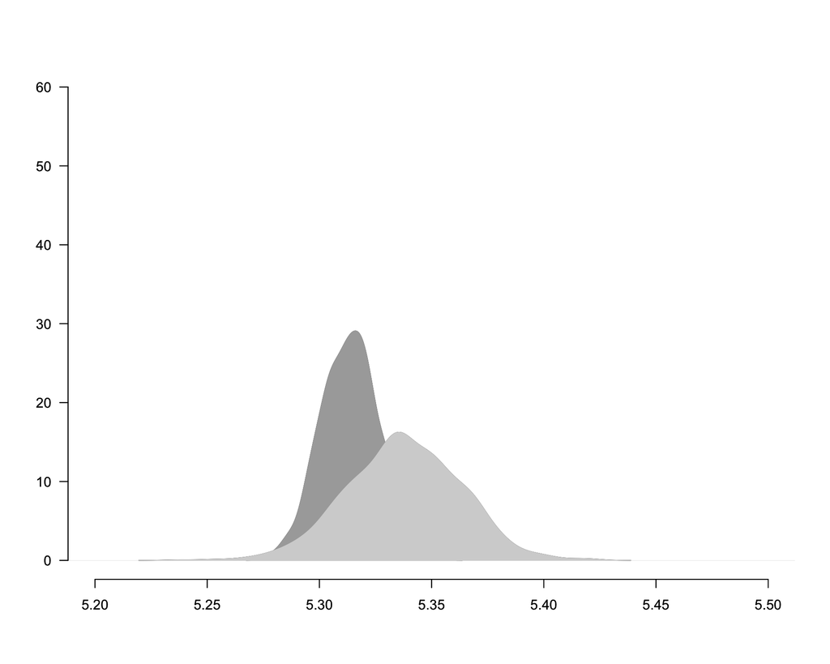

```r
z1 <- setx(z1, spdiffgroup_ruled  = 0.00)
z1 <- setx1(z1, spdiffgroup_ruled = 129.97)
z1.out <- sim(z1)

x <- z1.out$get_qi(qi = "ev", xvalue="x")
x1 <- z1.out$get_qi(qi = "ev", xvalue="x1")

y <- x-x1

xd <- density(x)
xd1 <- density(x1)

plot(xd, main="", sub="",
     xlab="", ylab="",frame.plot=FALSE,
     xlim=c(5.2, 5.5), ylim=c(0, 60), cex.axis=1, las=1)
par(new= TRUE)
plot(xd1, main="", sub="",
     xlab="", ylab="",frame.plot=FALSE,
     xlim=c(5.2, 5.5), ylim=c(0, 60), cex.axis=1, las=1)
polygon(xd, col = "darkgray", border = "darkgray")
par(new= TRUE)
polygon(xd1, col = "lightgray", border = "lightgray")
```

## Figure S3

```r
# load datasets

load("./dataframe1.RData")
load("./dataframe_equi.RData")


# run model with simulation data
model_equi <- as.formula(paste("rile ~ lag_rile + lag_cmedian + lag_econ_glob + interaction + spsamegroup_ruled + year_fe2 + year_fe3 + year_fe4 +  year_fe5 + year_fe6 +
year_fe7 +  year_fe8 +  year_fe9 +  year_fe10 + year_fe11 + year_fe12 + year_fe13 + year_fe14 + year_fe15 + year_fe16 + year_fe17 + year_fe18 + year_fe19 + year_fe20 + year_fe21 + year_fe22 + year_fe23 + year_fe24 + year_fe25 + year_fe26 + year_fe27 + year_fe28 + year_fe29 + year_fe30 +
year_fe31 + year_fe32 + year_fe33 + year_fe34 +" , paste(partyfx, collapse= "+")))

model_equi <- lm(model_equi, data = dataframe_equi)

# get predicted values from the original model
model4 <- as.formula(paste("rile ~ lag_rile + lag_cmedian + lag_econ_glob + interaction + spsamegroup_ruled + year_fe2 + year_fe3 + year_fe4 +  year_fe5 + year_fe6 + year_fe7 +  year_fe8 +  year_fe9 +  year_fe10 + year_fe11 + year_fe12 + year_fe13 + year_fe14 + year_fe15 + year_fe16 + year_fe17 + year_fe18 + year_fe19 + year_fe20 + year_fe21 + year_fe22 + year_fe23 + year_fe24 + year_fe25 + year_fe26 + year_fe27 + year_fe28 + year_fe29 + year_fe30 + year_fe31 + year_fe32 + year_fe33 + year_fe34 +" , paste(partyfx, collapse= "+")))

model4 <- lm(model4, data = dataframe1)

orig.pred <- as.data.frame(predict(model4))
new.pred <- as.data.frame(predict(model_equi))
names(orig.pred) <- c("fit")
names(new.pred) <- c("fit")

# compute difference between the predicted values
effect <- new.pred$fit - orig.pred$fit
el <- data.frame(party_id = dataframe_equi$party_id, groupnumber = dataframe_equi$groupnumber, year=dataframe_equi$year, party_name = dataframe_equi$partyname, country = dataframe_equi$countryname, diff_in_pred_rile = effect)
dataframe_equi$jee <- el$diff_in_pred_rile

# sort counties by absolute value of the change in predicted rile
el <- el %>% group_by(year) %>% top_n(5)  %>%
ungroup() %>%
  arrange(year, diff_in_pred_rile) %>%
  mutate(order = row_number())
```

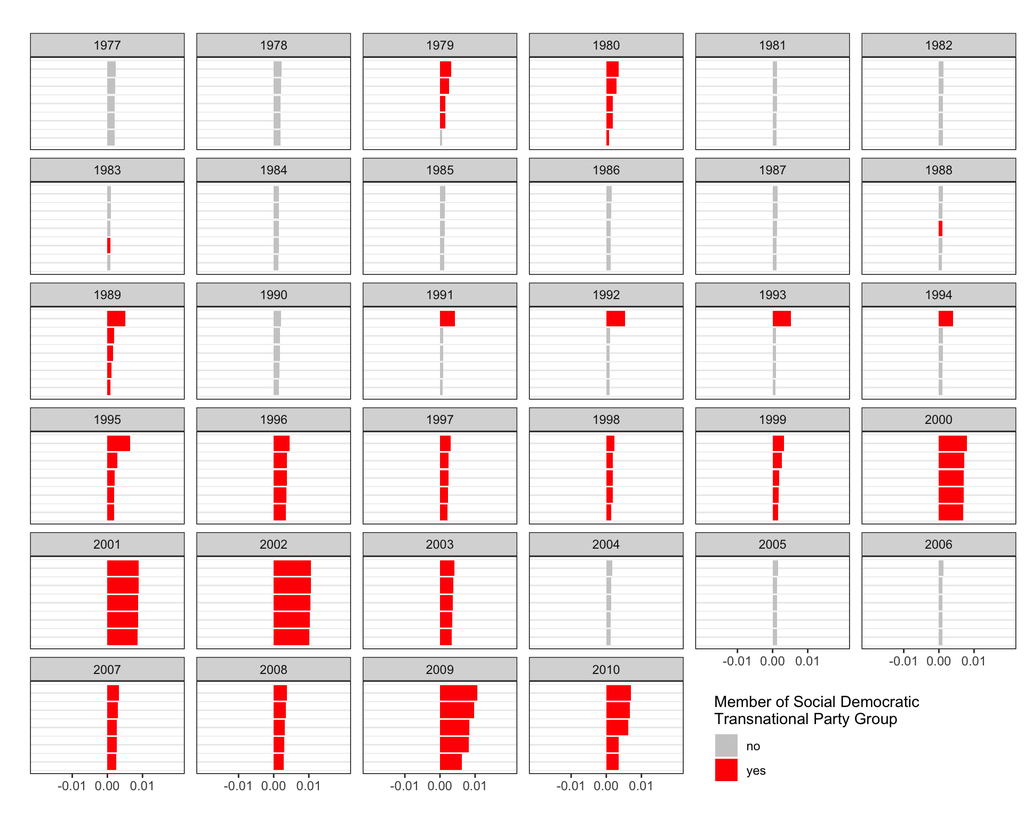

```r
# plot the results
el$pes <- ifelse(el$groupnumber == 20, 1, 0)

ggplot(el, aes(y=diff_in_pred_rile, x=order, order, fill = as.factor(pes))) +
  geom_bar(stat = "identity") +
  ggtitle("") +
  xlab("") +
  ylab("") +
  theme_bw() +
  theme(panel.grid.major.x = element_blank(),
        axis.text.y=element_blank(),
        axis.ticks.y=element_blank(),
        panel.grid.minor.x = element_blank(),
        panel.border = element_rect(colour = "black")) + facet_wrap(~ year, scales = "free_y") + scale_y_continuous(limits=c(-0.02, 0.02), breaks = c(-0.01, 0, 0.01)) +
  scale_fill_manual(values=c("gray80", "red"), name = "Member of Social Democratic \nTransnational Party Group", labels = c("no", "yes")) + coord_flip() +
  theme(plot.title = element_text(lineheight=.8)) +
  theme(axis.text=element_text(size=9)) + theme(legend.position = c(0.8, 0.05))
```

## Table S5

```r
# load dataset

load("./weight_matrices.RData")

#mean neighbors
mean(wmatnonaffiliated_ruled)*2718
```

```
## [1] 2.721118
```

```r
mean(wmatinonaffiliated_ruled)*2718
```

```
## [1] 6.850258
```

```r
mean(wmatknonaffiliated_ruled)*2718
```

```
## [1] 2.933039
```

## Table S6

```r
# load dataset

load("./dataframe1.RData")

# increase maximum print to show full regression outputs

options(max.print=1000000)

# Model A1 in Table S6

modela1 <- as.formula(paste("rile ~ lag_rile + lag_cmedian + lag_econ_glob + interaction + spnonaffiliated_ruled + year_fe2 + year_fe3 + year_fe4 +  year_fe5 + year_fe6 +  year_fe7 +  year_fe8 +  year_fe9 +  year_fe10 + year_fe11 + year_fe12 + year_fe13 + year_fe14 + year_fe15 + year_fe16 + year_fe17 + year_fe18 + year_fe19 + year_fe20 + year_fe21 + year_fe22 + year_fe23 + year_fe24 + year_fe25 + year_fe26 + year_fe27 + year_fe28 + year_fe29 + year_fe30 + year_fe31 + year_fe32 + year_fe33 + year_fe34 +" , paste(partyfx, collapse= "+")))

modela1 <- lm(modela1, data = dataframe1)
summary(modela1)
```

```
##
## Call:
## lm(formula = modela1, data = dataframe1)
##
## Residuals:
##      Min       1Q   Median       3Q      Max
## -1.94505 -0.09593 -0.00284  0.10754  2.08973
##
## Coefficients:
##                         Estimate Std. Error t value Pr(>|t|)
## (Intercept)           -9.915e-01  8.195e-01  -1.210 0.226413
## lag_rile               7.510e-01  1.289e-02  58.257  < 2e-16 ***
## lag_cmedian            4.404e-01  1.579e-01   2.789 0.005325 **
## lag_econ_glob          2.810e-02  1.125e-02   2.497 0.012583 *
## interaction           -5.881e-03  2.113e-03  -2.784 0.005410 **
## spnonaffiliated_ruled -9.120e-04  5.308e-04  -1.718 0.085922 .
## year_fe2               4.458e-02  6.746e-02   0.661 0.508778
## year_fe3              -2.226e-02  7.066e-02  -0.315 0.752781
## year_fe4               1.389e-02  7.104e-02   0.196 0.844976
## year_fe5               7.666e-02  7.003e-02   1.095 0.273740
## year_fe6               8.352e-02  7.078e-02   1.180 0.238090
## year_fe7               5.152e-02  7.098e-02   0.726 0.468041
## year_fe8               7.921e-02  6.994e-02   1.133 0.257501
## year_fe9               1.019e-02  7.015e-02   0.145 0.884533
## year_fe10              1.159e-01  6.674e-02   1.736 0.082683 .
## year_fe11              9.954e-02  6.838e-02   1.456 0.145628
## year_fe12              1.032e-01  6.863e-02   1.503 0.132857
## year_fe13              1.328e-01  6.948e-02   1.911 0.056137 .
## year_fe14              9.728e-02  7.115e-02   1.367 0.171691
## year_fe15             -5.572e-02  7.145e-02  -0.780 0.435584
## year_fe16              5.383e-02  7.147e-02   0.753 0.451423
## year_fe17              4.327e-02  7.162e-02   0.604 0.545786
## year_fe18              7.624e-02  7.447e-02   1.024 0.306044
## year_fe19              7.405e-02  7.629e-02   0.971 0.331835
## year_fe20              1.574e-01  7.286e-02   2.161 0.030818 *
## year_fe21              1.235e-01  7.444e-02   1.659 0.097170 .
## year_fe22              1.080e-01  7.882e-02   1.370 0.170942
## year_fe23              4.938e-02  8.300e-02   0.595 0.551999
## year_fe24              5.397e-02  8.355e-02   0.646 0.518366
## year_fe25              8.352e-02  8.843e-02   0.945 0.344992
```

[output cut: 214 more lines]

```
## party_fe207            4.263e-01  1.848e-01   2.307 0.021133 *
## party_fe208            3.051e-01  1.597e-01   1.910 0.056220 .
## party_fe209            1.545e-01  1.606e-01   0.962 0.336236
## party_fe210            2.103e-01  1.608e-01   1.308 0.190885
## party_fe211            3.387e-01  1.603e-01   2.113 0.034715 *
## party_fe212            1.153e-01  2.466e-01   0.467 0.640277
## party_fe213            2.821e-01  1.609e-01   1.753 0.079684 .
## party_fe214            2.152e-01  1.607e-01   1.339 0.180634
## party_fe215            4.202e-01  1.618e-01   2.597 0.009459 **
## ---
## Signif. codes:  0 '***' 0.001 '**' 0.01 '*' 0.05 '.' 0.1 ' ' 1
##
## Residual standard error: 0.3246 on 2465 degrees of freedom
## Multiple R-squared:  0.8879, Adjusted R-squared:  0.8765
## F-statistic: 77.51 on 252 and 2465 DF,  p-value: < 2.2e-16
```

```r
stargazer(modela1)
```

```
##
## % Table created by stargazer v.5.2.2 by Marek Hlavac, Harvard University. E-mail: hlavac at fas.harvard.edu
## % Date and time: Thu, Jul 01, 2021 - 15:53:04
## \begin{table}[!htbp] \centering
##   \caption{}
##   \label{}
## \begin{tabular}{@{\extracolsep{5pt}}lc}
## \\[-1.8ex]\hline
## \hline \\[-1.8ex]
##  & \multicolumn{1}{c}{\textit{Dependent variable:}} \\
## \cline{2-2}
## \\[-1.8ex] & rile \\
## \hline \\[-1.8ex]
##  lag\_rile & 0.751$^{***}$ \\
##   & (0.013) \\
##   & \\
##  lag\_cmedian & 0.440$^{***}$ \\
##   & (0.158) \\
##   & \\
##  lag\_econ\_glob & 0.028$^{**}$ \\
##   & (0.011) \\
##   & \\
##  interaction & $-$0.006$^{***}$ \\
##   & (0.002) \\
##   & \\
##  spnonaffiliated\_ruled & $-$0.001$^{*}$ \\
##   & (0.001) \\
##   & \\
##  year\_fe2 & 0.045 \\
##   & (0.067) \\
##   & \\
##  year\_fe3 & $-$0.022 \\
##   & (0.071) \\
##   & \\
##  year\_fe4 & 0.014 \\
##   & (0.071) \\
##   & \\
##  year\_fe5 & 0.077 \\
##   & (0.070) \\
##   & \\
```

[output cut: 728 more lines]

```
##   & \\
##  Constant & $-$0.992 \\
##   & (0.819) \\
##   & \\
## \hline \\[-1.8ex]
## Observations & 2,718 \\
## R$^{2}$ & 0.888 \\
## Adjusted R$^{2}$ & 0.876 \\
## Residual Std. Error & 0.325 (df = 2465) \\
## F Statistic & 77.507$^{***}$ (df = 252; 2465) \\
## \hline
## \hline \\[-1.8ex]
## \textit{Note:}  & \multicolumn{1}{r}{$^{*}$p$<$0.1; $^{**}$p$<$0.05; $^{***}$p$<$0.01} \\
## \end{tabular}
## \end{table}
```

```r
# Model A2 in Table S6

modela2 <- as.formula(paste("rile ~ lag_rile + lag_cmedian + lag_econ_glob + interaction + spinonaffiliated_ruled + year_fe2 + year_fe3 + year_fe4 +  year_fe5 + year_fe6 + year_fe7 +  year_fe8 +  year_fe9 +  year_fe10 + year_fe11 + year_fe12 + year_fe13 + year_fe14 + year_fe15 + year_fe16 + year_fe17 + year_fe18 + year_fe19 + year_fe20 + year_fe21 + year_fe22 + year_fe23 + year_fe24 + year_fe25 + year_fe26 + year_fe27 + year_fe28 + year_fe29 + year_fe30 + year_fe31 + year_fe32 + year_fe33 + year_fe34 +" , paste(partyfx, collapse= "+")))

modela2 <- lm(modela2, data = dataframe1)
summary(modela2)
```

```
##
## Call:
## lm(formula = modela2, data = dataframe1)
##
## Residuals:
##      Min       1Q   Median       3Q      Max
## -1.94210 -0.09778 -0.00136  0.10663  2.09222
##
## Coefficients:
##                          Estimate Std. Error t value Pr(>|t|)
## (Intercept)            -1.0006848  0.8198497  -1.221 0.222365
## lag_rile                0.7515560  0.0128933  58.291  < 2e-16 ***
## lag_cmedian             0.4322892  0.1580462   2.735 0.006279 **
## lag_econ_glob           0.0272825  0.0112570   2.424 0.015439 *
## interaction            -0.0057199  0.0021143  -2.705 0.006870 **
## spinonaffiliated_ruled -0.0002474  0.0002462  -1.005 0.315119
## year_fe2                0.0408397  0.0674503   0.605 0.544917
## year_fe3                0.0224245  0.0669282   0.335 0.737614
## year_fe4                0.0594889  0.0673450   0.883 0.377136
## year_fe5                0.1150164  0.0674029   1.706 0.088059 .
## year_fe6                0.1248233  0.0673402   1.854 0.063913 .
## year_fe7                0.0920044  0.0675316   1.362 0.173199
## year_fe8                0.1190381  0.0666926   1.785 0.074404 .
## year_fe9                0.0506443  0.0674380   0.751 0.452739
## year_fe10               0.1495053  0.0654267   2.285 0.022393 *
## year_fe11               0.1442821  0.0650605   2.218 0.026669 *
## year_fe12               0.1502004  0.0648047   2.318 0.020545 *
## year_fe13               0.1775489  0.0654079   2.714 0.006684 **
## year_fe14               0.1422258  0.0668979   2.126 0.033601 *
## year_fe15              -0.0097840  0.0679035  -0.144 0.885444
## year_fe16               0.0937934  0.0691783   1.356 0.175280
## year_fe17               0.0825981  0.0693144   1.192 0.233515
## year_fe18               0.1228592  0.0709295   1.732 0.083375 .
## year_fe19               0.1202654  0.0723392   1.663 0.096535 .
## year_fe20               0.1921044  0.0711180   2.701 0.006956 **
## year_fe21               0.1553953  0.0731113   2.125 0.033647 *
## year_fe22               0.1504170  0.0765120   1.966 0.049419 *
## year_fe23               0.0997864  0.0788380   1.266 0.205735
## year_fe24               0.1041447  0.0794798   1.310 0.190207
## year_fe25               0.1336792  0.0842978   1.586 0.112914
```

[output cut: 214 more lines]

```
## party_fe207             0.4165045  0.1847627   2.254 0.024267 *
## party_fe208             0.2964265  0.1605734   1.846 0.065005 .
## party_fe209             0.1467513  0.1616640   0.908 0.364096
## party_fe210             0.2024868  0.1617930   1.252 0.210864
## party_fe211             0.3235157  0.1600951   2.021 0.043411 *
## party_fe212             0.1306792  0.2487051   0.525 0.599326
## party_fe213             0.2741592  0.1619118   1.693 0.090532 .
## party_fe214             0.2074173  0.1617478   1.282 0.199841
## party_fe215             0.4119141  0.1627914   2.530 0.011458 *
## ---
## Signif. codes:  0 '***' 0.001 '**' 0.01 '*' 0.05 '.' 0.1 ' ' 1
##
## Residual standard error: 0.3248 on 2465 degrees of freedom
## Multiple R-squared:  0.8878, Adjusted R-squared:  0.8764
## F-statistic: 77.44 on 252 and 2465 DF,  p-value: < 2.2e-16
```

```r
stargazer(modela2)
```

```
##
## % Table created by stargazer v.5.2.2 by Marek Hlavac, Harvard University. E-mail: hlavac at fas.harvard.edu
## % Date and time: Thu, Jul 01, 2021 - 15:53:04
## \begin{table}[!htbp] \centering
##   \caption{}
##   \label{}
## \begin{tabular}{@{\extracolsep{5pt}}lc}
## \\[-1.8ex]\hline
## \hline \\[-1.8ex]
##  & \multicolumn{1}{c}{\textit{Dependent variable:}} \\
## \cline{2-2}
## \\[-1.8ex] & rile \\
## \hline \\[-1.8ex]
##  lag\_rile & 0.752$^{***}$ \\
##   & (0.013) \\
##   & \\
##  lag\_cmedian & 0.432$^{***}$ \\
##   & (0.158) \\
##   & \\
##  lag\_econ\_glob & 0.027$^{**}$ \\
##   & (0.011) \\
##   & \\
##  interaction & $-$0.006$^{***}$ \\
##   & (0.002) \\
##   & \\
##  spinonaffiliated\_ruled & $-$0.0002 \\
##   & (0.0002) \\
##   & \\
##  year\_fe2 & 0.041 \\
##   & (0.067) \\
##   & \\
##  year\_fe3 & 0.022 \\
##   & (0.067) \\
##   & \\
##  year\_fe4 & 0.059 \\
##   & (0.067) \\
##   & \\
##  year\_fe5 & 0.115$^{*}$ \\
##   & (0.067) \\
##   & \\
```

[output cut: 728 more lines]

```
##   & \\
##  Constant & $-$1.001 \\
##   & (0.820) \\
##   & \\
## \hline \\[-1.8ex]
## Observations & 2,718 \\
## R$^{2}$ & 0.888 \\
## Adjusted R$^{2}$ & 0.876 \\
## Residual Std. Error & 0.325 (df = 2465) \\
## F Statistic & 77.438$^{***}$ (df = 252; 2465) \\
## \hline
## \hline \\[-1.8ex]
## \textit{Note:}  & \multicolumn{1}{r}{$^{*}$p$<$0.1; $^{**}$p$<$0.05; $^{***}$p$<$0.01} \\
## \end{tabular}
## \end{table}
```

```r
# Model A3 in Table S6

modela3 <- as.formula(paste("rile ~ lag_rile + lag_cmedian + lag_econ_glob + interaction + spknonaffiliated_ruled + year_fe2 + year_fe3 + year_fe4 +  year_fe5 + year_fe6 + year_fe7 +  year_fe8 +  year_fe9 +  year_fe10 + year_fe11 + year_fe12 + year_fe13 + year_fe14 + year_fe15 + year_fe16 + year_fe17 + year_fe18 + year_fe19 + year_fe20 + year_fe21 + year_fe22 + year_fe23 + year_fe24 + year_fe25 + year_fe26 + year_fe27 + year_fe28 + year_fe29 + year_fe30 + year_fe31 + year_fe32 + year_fe33 + year_fe34 +" , paste(partyfx, collapse= "+")))

modela3 <- lm(modela3, data = dataframe1)
summary(modela3)
```

```
##
## Call:
## lm(formula = modela3, data = dataframe1)
##
## Residuals:
##      Min       1Q   Median       3Q      Max
## -1.94622 -0.09579 -0.00201  0.10636  2.08707
##
## Coefficients:
##                          Estimate Std. Error t value Pr(>|t|)
## (Intercept)            -1.0825660  0.8199072  -1.320 0.186840
## lag_rile                0.7511498  0.0128880  58.283  < 2e-16 ***
## lag_cmedian             0.4475945  0.1579760   2.833 0.004644 **
## lag_econ_glob           0.0287532  0.0112650   2.552 0.010757 *
## interaction            -0.0059772  0.0021141  -2.827 0.004732 **
## spknonaffiliated_ruled  0.0009147  0.0005033   1.817 0.069296 .
## year_fe2                0.0412657  0.0674190   0.612 0.540542
## year_fe3                0.0135859  0.0667664   0.203 0.838773
## year_fe4                0.0496596  0.0671330   0.740 0.459540
## year_fe5                0.0997091  0.0674724   1.478 0.139596
## year_fe6                0.1154530  0.0673108   1.715 0.086430 .
## year_fe7                0.0834205  0.0675351   1.235 0.216867
## year_fe8                0.1063913  0.0667954   1.593 0.111335
## year_fe9                0.0333677  0.0674685   0.495 0.620950
## year_fe10               0.1261076  0.0655646   1.923 0.054544 .
## year_fe11               0.1280820  0.0649024   1.973 0.048555 *
## year_fe12               0.1365159  0.0645705   2.114 0.034597 *
## year_fe13               0.1662410  0.0653921   2.542 0.011076 *
## year_fe14               0.1305854  0.0669770   1.950 0.051324 .
## year_fe15              -0.0306232  0.0680754  -0.450 0.652864
## year_fe16               0.0621019  0.0701556   0.885 0.376134
## year_fe17               0.0521562  0.0702548   0.742 0.457924
## year_fe18               0.0985980  0.0713362   1.382 0.167048
## year_fe19               0.0999149  0.0727656   1.373 0.169844
## year_fe20               0.1480082  0.0739619   2.001 0.045487 *
## year_fe21               0.1086429  0.0762775   1.424 0.154483
## year_fe22               0.1133249  0.0778598   1.455 0.145659
## year_fe23               0.0765527  0.0792987   0.965 0.334454
## year_fe24               0.0810541  0.0799165   1.014 0.310570
## year_fe25               0.1154204  0.0845609   1.365 0.172397
```

[output cut: 214 more lines]

```
## party_fe207             0.4326415  0.1849776   2.339 0.019421 *
## party_fe208             0.3117364  0.1600650   1.948 0.051581 .
## party_fe209             0.1621172  0.1610375   1.007 0.314176
## party_fe210             0.2179283  0.1611745   1.352 0.176459
## party_fe211             0.3463078  0.1606797   2.155 0.031237 *
## party_fe212             0.1254263  0.2468618   0.508 0.611440
## party_fe213             0.2896569  0.1612993   1.796 0.072653 .
## party_fe214             0.2228345  0.1611267   1.383 0.166797
## party_fe215             0.4276911  0.1622094   2.637 0.008425 **
## ---
## Signif. codes:  0 '***' 0.001 '**' 0.01 '*' 0.05 '.' 0.1 ' ' 1
##
## Residual standard error: 0.3246 on 2465 degrees of freedom
## Multiple R-squared:  0.888,  Adjusted R-squared:  0.8765
## F-statistic: 77.52 on 252 and 2465 DF,  p-value: < 2.2e-16
```

```r
stargazer(modela3)
```

```
##
## % Table created by stargazer v.5.2.2 by Marek Hlavac, Harvard University. E-mail: hlavac at fas.harvard.edu
## % Date and time: Thu, Jul 01, 2021 - 15:53:05
## \begin{table}[!htbp] \centering
##   \caption{}
##   \label{}
## \begin{tabular}{@{\extracolsep{5pt}}lc}
## \\[-1.8ex]\hline
## \hline \\[-1.8ex]
##  & \multicolumn{1}{c}{\textit{Dependent variable:}} \\
## \cline{2-2}
## \\[-1.8ex] & rile \\
## \hline \\[-1.8ex]
##  lag\_rile & 0.751$^{***}$ \\
##   & (0.013) \\
##   & \\
##  lag\_cmedian & 0.448$^{***}$ \\
##   & (0.158) \\
##   & \\
##  lag\_econ\_glob & 0.029$^{**}$ \\
##   & (0.011) \\
##   & \\
##  interaction & $-$0.006$^{***}$ \\
##   & (0.002) \\
##   & \\
##  spknonaffiliated\_ruled & 0.001$^{*}$ \\
##   & (0.001) \\
##   & \\
##  year\_fe2 & 0.041 \\
##   & (0.067) \\
##   & \\
##  year\_fe3 & 0.014 \\
##   & (0.067) \\
##   & \\
##  year\_fe4 & 0.050 \\
##   & (0.067) \\
##   & \\
##  year\_fe5 & 0.100 \\
##   & (0.067) \\
##   & \\
```

[output cut: 728 more lines]

```
##   & \\
##  Constant & $-$1.083 \\
##   & (0.820) \\
##   & \\
## \hline \\[-1.8ex]
## Observations & 2,718 \\
## R$^{2}$ & 0.888 \\
## Adjusted R$^{2}$ & 0.876 \\
## Residual Std. Error & 0.325 (df = 2465) \\
## F Statistic & 77.519$^{***}$ (df = 252; 2465) \\
## \hline
## \hline \\[-1.8ex]
## \textit{Note:}  & \multicolumn{1}{r}{$^{*}$p$<$0.1; $^{**}$p$<$0.05; $^{***}$p$<$0.01} \\
## \end{tabular}
## \end{table}
```

## Table S7

```r
# load dataset

load("./dataframe_interpol.RData")

# increase maximum print to show full regression outputs

options(max.print=1000000)

# Model LI1 in Table S7

modelli1 <- as.formula(paste("rile.y.linear ~  spruled + year_fe2 + year_fe3 + year_fe4 +  year_fe5 + year_fe6 + year_fe7 +  year_fe8 +  year_fe9 +  year_fe10 + year_fe11 + year_fe12 + year_fe13 + year_fe14 + year_fe15 + year_fe16 + year_fe17 + year_fe18 +  year_fe19 + year_fe20 + year_fe21 + year_fe22 + year_fe23 + year_fe24 + year_fe25 + year_fe26 + year_fe27 + year_fe28 + year_fe29 + year_fe30 + year_fe31 + year_fe32 + year_fe33 + year_fe34 +" , paste(partyfx, collapse= "+")))

modelli1 <- lm(modelli1, data = dataframe_interpol)
summary(modelli1)
```

```
##
## Call:
## lm(formula = modelli1, data = dataframe_interpol)
##
## Residuals:
##      Min       1Q   Median       3Q      Max
## -1.52475 -0.25563 -0.00838  0.21805  2.01431
##
## Coefficients:
##              Estimate Std. Error t value Pr(>|t|)
## (Intercept)  4.122931   0.159484  25.852  < 2e-16 ***
## spruled      0.006430   0.001658   3.879 0.000108 ***
## year_fe2     0.013273   0.093145   0.143 0.886695
## year_fe3     0.099204   0.092126   1.077 0.281663
## year_fe4     0.101364   0.092440   1.097 0.272950
## year_fe5     0.127063   0.093009   1.366 0.172023
## year_fe6     0.336280   0.092691   3.628 0.000291 ***
## year_fe7     0.388720   0.094693   4.105 4.17e-05 ***
## year_fe8     0.323579   0.089760   3.605 0.000318 ***
## year_fe9     0.154537   0.099145   1.559 0.119195
## year_fe10    0.123367   0.113402   1.088 0.276758
## year_fe11    0.166918   0.100700   1.658 0.097530 .
## year_fe12    0.179517   0.095025   1.889 0.058988 .
## year_fe13    0.248941   0.088904   2.800 0.005148 **
## year_fe14    0.315348   0.086020   3.666 0.000252 ***
## year_fe15   -0.008423   0.110053  -0.077 0.939002
## year_fe16   -0.206768   0.144083  -1.435 0.151398
## year_fe17   -0.177934   0.135611  -1.312 0.189611
## year_fe18   -0.197534   0.135262  -1.460 0.144313
## year_fe19   -0.125504   0.117839  -1.065 0.286961
## year_fe20   -0.189368   0.176068  -1.076 0.282238
## year_fe21   -0.226179   0.184390  -1.227 0.220078
## year_fe22   -0.257802   0.178491  -1.444 0.148770
## year_fe23   -0.431514   0.202073  -2.135 0.032824 *
## year_fe24   -0.477429   0.204208  -2.338 0.019469 *
## year_fe25   -0.385810   0.184389  -2.092 0.036507 *
## year_fe26   -0.446766   0.195183  -2.289 0.022166 *
## year_fe27   -0.218109   0.147129  -1.482 0.138352
## year_fe28   -0.294242   0.154570  -1.904 0.057076 .
## year_fe29   -0.751382   0.259753  -2.893 0.003853 **
```

[output cut: 210 more lines]

```
## party_fe207  1.436130   0.253436   5.667 1.63e-08 ***
## party_fe208  1.368564   0.217349   6.297 3.59e-10 ***
## party_fe209  0.575937   0.217103   2.653 0.008033 **
## party_fe210  0.771552   0.217103   3.554 0.000387 ***
## party_fe211  0.768987   0.217103   3.542 0.000404 ***
## party_fe212  0.461367   0.338805   1.362 0.173402
## party_fe213  0.947187   0.217103   4.363 1.34e-05 ***
## party_fe214  0.731637   0.217103   3.370 0.000763 ***
## party_fe215  1.601712   0.217103   7.378 2.19e-13 ***
## ---
## Signif. codes:  0 '***' 0.001 '**' 0.01 '*' 0.05 '.' 0.1 ' ' 1
##
## Residual standard error: 0.4481 on 2469 degrees of freedom
## Multiple R-squared:  0.7698, Adjusted R-squared:  0.7467
## F-statistic:  33.3 on 248 and 2469 DF,  p-value: < 2.2e-16
```

```r
stargazer(modelli1)
```

```
##
## % Table created by stargazer v.5.2.2 by Marek Hlavac, Harvard University. E-mail: hlavac at fas.harvard.edu
## % Date and time: Thu, Jul 01, 2021 - 15:53:06
## \begin{table}[!htbp] \centering
##   \caption{}
##   \label{}
## \begin{tabular}{@{\extracolsep{5pt}}lc}
## \\[-1.8ex]\hline
## \hline \\[-1.8ex]
##  & \multicolumn{1}{c}{\textit{Dependent variable:}} \\
## \cline{2-2}
## \\[-1.8ex] & rile.y.linear \\
## \hline \\[-1.8ex]
##  spruled & 0.006$^{***}$ \\
##   & (0.002) \\
##   & \\
##  year\_fe2 & 0.013 \\
##   & (0.093) \\
##   & \\
##  year\_fe3 & 0.099 \\
##   & (0.092) \\
##   & \\
##  year\_fe4 & 0.101 \\
##   & (0.092) \\
##   & \\
##  year\_fe5 & 0.127 \\
##   & (0.093) \\
##   & \\
##  year\_fe6 & 0.336$^{***}$ \\
##   & (0.093) \\
##   & \\
##  year\_fe7 & 0.389$^{***}$ \\
##   & (0.095) \\
##   & \\
##  year\_fe8 & 0.324$^{***}$ \\
##   & (0.090) \\
##   & \\
##  year\_fe9 & 0.155 \\
##   & (0.099) \\
##   & \\
```

[output cut: 716 more lines]

```
##   & \\
##  Constant & 4.123$^{***}$ \\
##   & (0.159) \\
##   & \\
## \hline \\[-1.8ex]
## Observations & 2,718 \\
## R$^{2}$ & 0.770 \\
## Adjusted R$^{2}$ & 0.747 \\
## Residual Std. Error & 0.448 (df = 2469) \\
## F Statistic & 33.296$^{***}$ (df = 248; 2469) \\
## \hline
## \hline \\[-1.8ex]
## \textit{Note:}  & \multicolumn{1}{r}{$^{*}$p$<$0.1; $^{**}$p$<$0.05; $^{***}$p$<$0.01} \\
## \end{tabular}
## \end{table}
```

```r
# Model LI2 in Table S7

modelli2 <- as.formula(paste("rile.y.linear ~ rile.y.linear_lag + lag_cmedian + lag_econ_glob + interaction + spruled + year_fe2 + year_fe3 + year_fe4 +  year_fe5 + year_fe6 + year_fe7 +  year_fe8 +  year_fe9 +  year_fe10 + year_fe11 + year_fe12 + year_fe13 + year_fe14 + year_fe15 + year_fe16 + year_fe17 + year_fe18 + year_fe19 + year_fe20 + year_fe21 + year_fe22 + year_fe23 + year_fe24 + year_fe25 + year_fe26 + year_fe27 + year_fe28 + year_fe29 + year_fe30 +
year_fe31 + year_fe32 + year_fe33 + year_fe34 +" , paste(partyfx, collapse= "+")))

modelli2 <- lm(modelli2, data = dataframe_interpol)
summary(modelli2)
```

```
##
## Call:
## lm(formula = modelli2, data = dataframe_interpol)
##
## Residuals:
##      Min       1Q   Median       3Q      Max
## -2.11822 -0.08328  0.00000  0.08305  1.35032
##
## Coefficients:
##                     Estimate Std. Error t value Pr(>|t|)
## (Intercept)       -1.3608380  0.5988550  -2.272 0.023148 *
## rile.y.linear_lag  0.8276848  0.0103039  80.327  < 2e-16 ***
## lag_cmedian        0.3891648  0.1140936   3.411 0.000658 ***
## lag_econ_glob      0.0237000  0.0081242   2.917 0.003564 **
## interaction       -0.0048869  0.0015255  -3.204 0.001375 **
## spruled            0.0042050  0.0008681   4.844 1.35e-06 ***
## year_fe2           0.0443121  0.0482923   0.918 0.358928
## year_fe3           0.0583973  0.0477521   1.223 0.221474
## year_fe4           0.0724475  0.0481817   1.504 0.132805
## year_fe5           0.0371897  0.0487159   0.763 0.445299
## year_fe6           0.1716763  0.0490308   3.501 0.000471 ***
## year_fe7           0.1615720  0.0502369   3.216 0.001316 **
## year_fe8           0.1138897  0.0476865   2.388 0.017001 *
## year_fe9          -0.0220578  0.0532779  -0.414 0.678900
## year_fe10         -0.0943909  0.0608914  -1.550 0.121233
## year_fe11         -0.0746460  0.0539295  -1.384 0.166441
## year_fe12         -0.0505415  0.0509473  -0.992 0.321278
## year_fe13          0.0304756  0.0478324   0.637 0.524098
## year_fe14          0.0955376  0.0478537   1.996 0.045995 *
## year_fe15         -0.1280075  0.0610799  -2.096 0.036207 *
## year_fe16         -0.2368474  0.0790550  -2.996 0.002763 **
## year_fe17         -0.1985265  0.0750495  -2.645 0.008214 **
## year_fe18         -0.1957771  0.0757729  -2.584 0.009831 **
## year_fe19         -0.1287916  0.0674224  -1.910 0.056221 .
## year_fe20         -0.2154202  0.0970403  -2.220 0.026516 *
## year_fe21         -0.3040951  0.1021623  -2.977 0.002943 **
## year_fe22         -0.3366508  0.1005704  -3.347 0.000828 ***
## year_fe23         -0.4246532  0.1133915  -3.745 0.000185 ***
## year_fe24         -0.4084278  0.1146888  -3.561 0.000376 ***
## year_fe25         -0.3148642  0.1067637  -2.949 0.003216 **
```

[output cut: 214 more lines]

```
## party_fe207        0.3140611  0.1321141   2.377 0.017521 *
## party_fe208        0.2014577  0.1136258   1.773 0.076353 .
## party_fe209        0.0619603  0.1139113   0.544 0.586536
## party_fe210        0.1035266  0.1140014   0.908 0.363905
## party_fe211        0.2505408  0.1139135   2.199 0.027942 *
## party_fe212        0.0597284  0.1761851   0.339 0.734631
## party_fe213        0.1646680  0.1140892   1.443 0.149055
## party_fe214        0.1129996  0.1139690   0.991 0.321542
## party_fe215        0.2500769  0.1147875   2.179 0.029455 *
## ---
## Signif. codes:  0 '***' 0.001 '**' 0.01 '*' 0.05 '.' 0.1 ' ' 1
##
## Residual standard error: 0.2321 on 2465 degrees of freedom
## Multiple R-squared:  0.9384, Adjusted R-squared:  0.9321
## F-statistic: 148.9 on 252 and 2465 DF,  p-value: < 2.2e-16
```

```r
stargazer(modelli2)
```

```
##
## % Table created by stargazer v.5.2.2 by Marek Hlavac, Harvard University. E-mail: hlavac at fas.harvard.edu
## % Date and time: Thu, Jul 01, 2021 - 15:53:07
## \begin{table}[!htbp] \centering
##   \caption{}
##   \label{}
## \begin{tabular}{@{\extracolsep{5pt}}lc}
## \\[-1.8ex]\hline
## \hline \\[-1.8ex]
##  & \multicolumn{1}{c}{\textit{Dependent variable:}} \\
## \cline{2-2}
## \\[-1.8ex] & rile.y.linear \\
## \hline \\[-1.8ex]
##  rile.y.linear\_lag & 0.828$^{***}$ \\
##   & (0.010) \\
##   & \\
##  lag\_cmedian & 0.389$^{***}$ \\
##   & (0.114) \\
##   & \\
##  lag\_econ\_glob & 0.024$^{***}$ \\
##   & (0.008) \\
##   & \\
##  interaction & $-$0.005$^{***}$ \\
##   & (0.002) \\
##   & \\
##  spruled & 0.004$^{***}$ \\
##   & (0.001) \\
##   & \\
##  year\_fe2 & 0.044 \\
##   & (0.048) \\
##   & \\
##  year\_fe3 & 0.058 \\
##   & (0.048) \\
##   & \\
##  year\_fe4 & 0.072 \\
##   & (0.048) \\
##   & \\
##  year\_fe5 & 0.037 \\
##   & (0.049) \\
##   & \\
```

[output cut: 728 more lines]

```
##   & \\
##  Constant & $-$1.361$^{**}$ \\
##   & (0.599) \\
##   & \\
## \hline \\[-1.8ex]
## Observations & 2,718 \\
## R$^{2}$ & 0.938 \\
## Adjusted R$^{2}$ & 0.932 \\
## Residual Std. Error & 0.232 (df = 2465) \\
## F Statistic & 148.898$^{***}$ (df = 252; 2465) \\
## \hline
## \hline \\[-1.8ex]
## \textit{Note:}  & \multicolumn{1}{r}{$^{*}$p$<$0.1; $^{**}$p$<$0.05; $^{***}$p$<$0.01} \\
## \end{tabular}
## \end{table}
```

```r
# Model LI3 in Table S7

modelli3 <- as.formula(paste("rile.y.linear ~ spsamegroup_ruled + year_fe2 + year_fe3 + year_fe4 +  year_fe5 + year_fe6 + year_fe7 +  year_fe8 +  year_fe9 +  year_fe10 + year_fe11 + year_fe12 + year_fe13 + year_fe14 + year_fe15 + year_fe16 + year_fe17 + year_fe18 + year_fe19 + year_fe20 + year_fe21 + year_fe22 + year_fe23 + year_fe24 + year_fe25 + year_fe26 + year_fe27 + year_fe28 + year_fe29 + year_fe30 + year_fe31 + year_fe32 + year_fe33 + year_fe34 +" , paste(partyfx, collapse= "+")))

modelli3 <- lm(modelli3, data = dataframe_interpol)
summary(modelli3)
```

```
##
## Call:
## lm(formula = modelli3, data = dataframe_interpol)
##
## Residuals:
##      Min       1Q   Median       3Q      Max
## -1.46186 -0.26040 -0.00379  0.21959  1.95989
##
## Coefficients:
##                     Estimate Std. Error t value Pr(>|t|)
## (Intercept)        4.5043077  0.1354125  33.264  < 2e-16 ***
## spsamegroup_ruled  0.0041538  0.0009237   4.497 7.21e-06 ***
## year_fe2           0.0367381  0.0928592   0.396 0.692410
## year_fe3           0.0656557  0.0920415   0.713 0.475710
## year_fe4           0.1116579  0.0920890   1.212 0.225437
## year_fe5           0.1668413  0.0918948   1.816 0.069558 .
## year_fe6           0.2487925  0.0907166   2.743 0.006141 **
## year_fe7           0.2711340  0.0907045   2.989 0.002825 **
## year_fe8           0.3042138  0.0896843   3.392 0.000705 ***
## year_fe9           0.3045372  0.0894049   3.406 0.000669 ***
## year_fe10          0.3941366  0.0860074   4.583 4.82e-06 ***
## year_fe11          0.3450388  0.0863514   3.996 6.64e-05 ***
## year_fe12          0.3134251  0.0860368   3.643 0.000275 ***
## year_fe13          0.2974768  0.0868997   3.423 0.000629 ***
## year_fe14          0.3096855  0.0859670   3.602 0.000322 ***
## year_fe15          0.2254450  0.0857224   2.630 0.008593 **
## year_fe16          0.2007351  0.0860653   2.332 0.019762 *
## year_fe17          0.1869710  0.0857891   2.179 0.029394 *
## year_fe18          0.1465797  0.0863885   1.697 0.089870 .
## year_fe19          0.1216704  0.0876539   1.388 0.165239
## year_fe20          0.3516659  0.0841733   4.178 3.04e-05 ***
## year_fe21          0.3524704  0.0837184   4.210 2.64e-05 ***
## year_fe22          0.2869106  0.0844207   3.399 0.000688 ***
## year_fe23          0.1606730  0.0875221   1.836 0.066508 .
## year_fe24          0.1210448  0.0877077   1.380 0.167683
## year_fe25          0.1326895  0.0882990   1.503 0.133037
## year_fe26          0.1247702  0.0874130   1.427 0.153602
## year_fe27          0.1699874  0.0853053   1.993 0.046405 *
## year_fe28          0.1311343  0.0846278   1.550 0.121380
## year_fe29          0.1309166  0.0826390   1.584 0.113277
```

[output cut: 210 more lines]

```
## party_fe207        1.4161341  0.2528966   5.600 2.39e-08 ***
## party_fe208        1.3562089  0.2169462   6.251 4.78e-10 ***
## party_fe209        0.5907236  0.2169462   2.723 0.006517 **
## party_fe210        0.7863386  0.2169462   3.625 0.000295 ***
## party_fe211        0.7269171  0.2169156   3.351 0.000817 ***
## party_fe212        0.4811499  0.3385445   1.421 0.155376
## party_fe213        0.9619736  0.2169462   4.434 9.65e-06 ***
## party_fe214        0.7464236  0.2169462   3.441 0.000590 ***
## party_fe215        1.6164986  0.2169462   7.451 1.27e-13 ***
## ---
## Signif. codes:  0 '***' 0.001 '**' 0.01 '*' 0.05 '.' 0.1 ' ' 1
##
## Residual standard error: 0.4477 on 2469 degrees of freedom
## Multiple R-squared:  0.7703, Adjusted R-squared:  0.7472
## F-statistic: 33.39 on 248 and 2469 DF,  p-value: < 2.2e-16
```

```r
stargazer(modelli3)
```

```
##
## % Table created by stargazer v.5.2.2 by Marek Hlavac, Harvard University. E-mail: hlavac at fas.harvard.edu
## % Date and time: Thu, Jul 01, 2021 - 15:53:08
## \begin{table}[!htbp] \centering
##   \caption{}
##   \label{}
## \begin{tabular}{@{\extracolsep{5pt}}lc}
## \\[-1.8ex]\hline
## \hline \\[-1.8ex]
##  & \multicolumn{1}{c}{\textit{Dependent variable:}} \\
## \cline{2-2}
## \\[-1.8ex] & rile.y.linear \\
## \hline \\[-1.8ex]
##  spsamegroup\_ruled & 0.004$^{***}$ \\
##   & (0.001) \\
##   & \\
##  year\_fe2 & 0.037 \\
##   & (0.093) \\
##   & \\
##  year\_fe3 & 0.066 \\
##   & (0.092) \\
##   & \\
##  year\_fe4 & 0.112 \\
##   & (0.092) \\
##   & \\
##  year\_fe5 & 0.167$^{*}$ \\
##   & (0.092) \\
##   & \\
##  year\_fe6 & 0.249$^{***}$ \\
##   & (0.091) \\
##   & \\
##  year\_fe7 & 0.271$^{***}$ \\
##   & (0.091) \\
##   & \\
##  year\_fe8 & 0.304$^{***}$ \\
##   & (0.090) \\
##   & \\
##  year\_fe9 & 0.305$^{***}$ \\
##   & (0.089) \\
##   & \\
```

[output cut: 716 more lines]

```
##   & \\
##  Constant & 4.504$^{***}$ \\
##   & (0.135) \\
##   & \\
## \hline \\[-1.8ex]
## Observations & 2,718 \\
## R$^{2}$ & 0.770 \\
## Adjusted R$^{2}$ & 0.747 \\
## Residual Std. Error & 0.448 (df = 2469) \\
## F Statistic & 33.386$^{***}$ (df = 248; 2469) \\
## \hline
## \hline \\[-1.8ex]
## \textit{Note:}  & \multicolumn{1}{r}{$^{*}$p$<$0.1; $^{**}$p$<$0.05; $^{***}$p$<$0.01} \\
## \end{tabular}
## \end{table}
```

```r
# Model LI4 in Table S7

modelli4 <- as.formula(paste("rile.y.linear ~ rile.y.linear_lag + lag_cmedian + lag_econ_glob + interaction + spsamegroup_ruled + year_fe2 + year_fe3 + year_fe4 +  year_fe5 + year_fe6 + year_fe7 +  year_fe8 +  year_fe9 +  year_fe10 + year_fe11 + year_fe12 + year_fe13 + year_fe14 + year_fe15 + year_fe16 + year_fe17 + year_fe18 + year_fe19 + year_fe20 + year_fe21 + year_fe22 + year_fe23 + year_fe24 + year_fe25 + year_fe26 + year_fe27 + year_fe28 + year_fe29 + year_fe30 +
year_fe31 + year_fe32 + year_fe33 + year_fe34 +" , paste(partyfx, collapse= "+")))

modelli4 <- lm(modelli4, data = dataframe_interpol)
summary(modelli4)
```

```
##
## Call:
## lm(formula = modelli4, data = dataframe_interpol)
##
## Residuals:
##      Min       1Q   Median       3Q      Max
## -2.15050 -0.08517 -0.00045  0.08771  1.32257
##
## Coefficients:
##                     Estimate Std. Error t value Pr(>|t|)
## (Intercept)       -0.7990327  0.5883833  -1.358 0.174584
## rile.y.linear_lag  0.8285842  0.0103636  79.952  < 2e-16 ***
## lag_cmedian        0.3252052  0.1136330   2.862 0.004247 **
## lag_econ_glob      0.0188837  0.0080829   2.336 0.019558 *
## interaction       -0.0039888  0.0015183  -2.627 0.008664 **
## spsamegroup_ruled  0.0009665  0.0004846   1.994 0.046231 *
## year_fe2           0.0585206  0.0483919   1.209 0.226661
## year_fe3           0.0443801  0.0479528   0.925 0.354799
## year_fe4           0.0880653  0.0482529   1.825 0.068110 .
## year_fe5           0.0708628  0.0483192   1.467 0.142625
## year_fe6           0.1213368  0.0483466   2.510 0.012146 *
## year_fe7           0.0905141  0.0485238   1.865 0.062250 .
## year_fe8           0.1070038  0.0479076   2.234 0.025603 *
## year_fe9           0.0837319  0.0483724   1.731 0.083579 .
## year_fe10          0.0904210  0.0468694   1.929 0.053819 .
## year_fe11          0.0522493  0.0466782   1.119 0.263100
## year_fe12          0.0475488  0.0464495   1.024 0.306094
## year_fe13          0.0735528  0.0470145   1.564 0.117836
## year_fe14          0.1023729  0.0480742   2.129 0.033314 *
## year_fe15          0.0426328  0.0488184   0.873 0.382588
## year_fe16          0.0504792  0.0498542   1.013 0.311381
## year_fe17          0.0624474  0.0500016   1.249 0.211817
## year_fe18          0.0601282  0.0515178   1.167 0.243269
## year_fe19          0.0634946  0.0526129   1.207 0.227615
## year_fe20          0.1683493  0.0516374   3.260 0.001128 **
## year_fe21          0.1042229  0.0531119   1.962 0.049837 *
## year_fe22          0.0533273  0.0556237   0.959 0.337796
## year_fe23          0.0195834  0.0588491   0.333 0.739333
## year_fe24          0.0408210  0.0594145   0.687 0.492112
## year_fe25          0.0796478  0.0626503   1.271 0.203740
```

[output cut: 214 more lines]

```
## party_fe207        0.2866706  0.1325128   2.163 0.030611 *
## party_fe208        0.1808497  0.1140118   1.586 0.112814
## party_fe209        0.0577799  0.1144452   0.505 0.613696
## party_fe210        0.0991788  0.1145402   0.866 0.386637
## party_fe211        0.2331262  0.1143268   2.039 0.041544 *
## party_fe212        0.0523259  0.1769722   0.296 0.767505
## party_fe213        0.1601958  0.1146317   1.397 0.162394
## party_fe214        0.1087054  0.1145062   0.949 0.342540
## party_fe215        0.2449862  0.1153504   2.124 0.033783 *
## ---
## Signif. codes:  0 '***' 0.001 '**' 0.01 '*' 0.05 '.' 0.1 ' ' 1
##
## Residual standard error: 0.233 on 2465 degrees of freedom
## Multiple R-squared:  0.9379, Adjusted R-squared:  0.9315
## F-statistic: 147.7 on 252 and 2465 DF,  p-value: < 2.2e-16
```

```r
stargazer(modelli4)
```

```
##
## % Table created by stargazer v.5.2.2 by Marek Hlavac, Harvard University. E-mail: hlavac at fas.harvard.edu
## % Date and time: Thu, Jul 01, 2021 - 15:53:09
## \begin{table}[!htbp] \centering
##   \caption{}
##   \label{}
## \begin{tabular}{@{\extracolsep{5pt}}lc}
## \\[-1.8ex]\hline
## \hline \\[-1.8ex]
##  & \multicolumn{1}{c}{\textit{Dependent variable:}} \\
## \cline{2-2}
## \\[-1.8ex] & rile.y.linear \\
## \hline \\[-1.8ex]
##  rile.y.linear\_lag & 0.829$^{***}$ \\
##   & (0.010) \\
##   & \\
##  lag\_cmedian & 0.325$^{***}$ \\
##   & (0.114) \\
##   & \\
##  lag\_econ\_glob & 0.019$^{**}$ \\
##   & (0.008) \\
##   & \\
##  interaction & $-$0.004$^{***}$ \\
##   & (0.002) \\
##   & \\
##  spsamegroup\_ruled & 0.001$^{**}$ \\
##   & (0.0005) \\
##   & \\
##  year\_fe2 & 0.059 \\
##   & (0.048) \\
##   & \\
##  year\_fe3 & 0.044 \\
##   & (0.048) \\
##   & \\
##  year\_fe4 & 0.088$^{*}$ \\
##   & (0.048) \\
##   & \\
##  year\_fe5 & 0.071 \\
##   & (0.048) \\
##   & \\
```

[output cut: 728 more lines]

```
##   & \\
##  Constant & $-$0.799 \\
##   & (0.588) \\
##   & \\
## \hline \\[-1.8ex]
## Observations & 2,718 \\
## R$^{2}$ & 0.938 \\
## Adjusted R$^{2}$ & 0.932 \\
## Residual Std. Error & 0.233 (df = 2465) \\
## F Statistic & 147.656$^{***}$ (df = 252; 2465) \\
## \hline
## \hline \\[-1.8ex]
## \textit{Note:}  & \multicolumn{1}{r}{$^{*}$p$<$0.1; $^{**}$p$<$0.05; $^{***}$p$<$0.01} \\
## \end{tabular}
## \end{table}
```

## Table S8

```r
# load dataset

load("./dataframe_spline.RData")

# increase maximum print to show full regression outputs

options(max.print=1000000)

# Model LI1 in Table S7

modelsi1 <- as.formula(paste("rile.y.spline ~  spruled + year_fe2 + year_fe3 + year_fe4 +  year_fe5 + year_fe6 + year_fe7 +  year_fe8 +  year_fe9 +  year_fe10 + year_fe11 + year_fe12 + year_fe13 + year_fe14 + year_fe15 + year_fe16 + year_fe17 + year_fe18 +  year_fe19 + year_fe20 + year_fe21 + year_fe22 + year_fe23 + year_fe24 + year_fe25 + year_fe26 + year_fe27 + year_fe28 + year_fe29 + year_fe30 + year_fe31 + year_fe32 + year_fe33 + year_fe34 +" , paste(partyfx, collapse= "+")))

modelsi1 <- lm(modelsi1, data = dataframe_spline)
summary(modelsi1)
```

```
##
## Call:
## lm(formula = modelsi1, data = dataframe_spline)
##
## Residuals:
##      Min       1Q   Median       3Q      Max
## -2.91870 -0.25894 -0.00072  0.23866  2.19936
##
## Coefficients:
##              Estimate Std. Error t value Pr(>|t|)
## (Intercept)  3.941624   0.182004  21.657  < 2e-16 ***
## spruled      0.007208   0.001892   3.810 0.000142 ***
## year_fe2     0.049927   0.106298   0.470 0.638617
## year_fe3     0.170627   0.105135   1.623 0.104732
## year_fe4     0.175980   0.105493   1.668 0.095409 .
## year_fe5     0.230646   0.106143   2.173 0.029877 *
## year_fe6     0.465477   0.105779   4.400 1.13e-05 ***
## year_fe7     0.560871   0.108065   5.190 2.27e-07 ***
## year_fe8     0.504771   0.102434   4.928 8.87e-07 ***
## year_fe9     0.340647   0.113145   3.011 0.002633 **
## year_fe10    0.198785   0.129415   1.536 0.124660
## year_fe11    0.288383   0.114919   2.509 0.012156 *
## year_fe12    0.267561   0.108443   2.467 0.013681 *
## year_fe13    0.350983   0.101458   3.459 0.000551 ***
## year_fe14    0.431654   0.098167   4.397 1.14e-05 ***
## year_fe15    0.158821   0.125593   1.265 0.206146
## year_fe16   -0.107486   0.164429  -0.654 0.513372
## year_fe17   -0.084196   0.154760  -0.544 0.586462
## year_fe18   -0.096992   0.154362  -0.628 0.529838
## year_fe19    0.002058   0.134478   0.015 0.987792
## year_fe20   -0.167488   0.200929  -0.834 0.404605
## year_fe21   -0.147744   0.210427  -0.702 0.482674
## year_fe22   -0.164302   0.203695  -0.807 0.419969
## year_fe23   -0.358539   0.230607  -1.555 0.120131
## year_fe24   -0.410525   0.233043  -1.762 0.078264 .
## year_fe25   -0.333244   0.210425  -1.584 0.113397
## year_fe26   -0.411532   0.222743  -1.848 0.064785 .
## year_fe27   -0.119396   0.167904  -0.711 0.477092
## year_fe28   -0.166177   0.176396  -0.942 0.346248
## year_fe29   -0.728777   0.296431  -2.459 0.014020 *
```

[output cut: 210 more lines]

```
## party_fe207  1.493442   0.289222   5.164 2.62e-07 ***
## party_fe208  1.178500   0.248040   4.751 2.14e-06 ***
## party_fe209  0.515949   0.247759   2.082 0.037403 *
## party_fe210  0.721059   0.247759   2.910 0.003643 **
## party_fe211  0.896649   0.247759   3.619 0.000302 ***
## party_fe212  0.430636   0.386646   1.114 0.265485
## party_fe213  0.933999   0.247759   3.770 0.000167 ***
## party_fe214  0.700899   0.247759   2.829 0.004708 **
## party_fe215  1.555449   0.247759   6.278 4.04e-10 ***
## ---
## Signif. codes:  0 '***' 0.001 '**' 0.01 '*' 0.05 '.' 0.1 ' ' 1
##
## Residual standard error: 0.5114 on 2469 degrees of freedom
## Multiple R-squared:  0.7142, Adjusted R-squared:  0.6855
## F-statistic: 24.88 on 248 and 2469 DF,  p-value: < 2.2e-16
```

```r
stargazer(modelsi1)
```

```
##
## % Table created by stargazer v.5.2.2 by Marek Hlavac, Harvard University. E-mail: hlavac at fas.harvard.edu
## % Date and time: Thu, Jul 01, 2021 - 15:53:10
## \begin{table}[!htbp] \centering
##   \caption{}
##   \label{}
## \begin{tabular}{@{\extracolsep{5pt}}lc}
## \\[-1.8ex]\hline
## \hline \\[-1.8ex]
##  & \multicolumn{1}{c}{\textit{Dependent variable:}} \\
## \cline{2-2}
## \\[-1.8ex] & rile.y.spline \\
## \hline \\[-1.8ex]
##  spruled & 0.007$^{***}$ \\
##   & (0.002) \\
##   & \\
##  year\_fe2 & 0.050 \\
##   & (0.106) \\
##   & \\
##  year\_fe3 & 0.171 \\
##   & (0.105) \\
##   & \\
##  year\_fe4 & 0.176$^{*}$ \\
##   & (0.105) \\
##   & \\
##  year\_fe5 & 0.231$^{**}$ \\
##   & (0.106) \\
##   & \\
##  year\_fe6 & 0.465$^{***}$ \\
##   & (0.106) \\
##   & \\
##  year\_fe7 & 0.561$^{***}$ \\
##   & (0.108) \\
##   & \\
##  year\_fe8 & 0.505$^{***}$ \\
##   & (0.102) \\
##   & \\
##  year\_fe9 & 0.341$^{***}$ \\
##   & (0.113) \\
##   & \\
```

[output cut: 716 more lines]

```
##   & \\
##  Constant & 3.942$^{***}$ \\
##   & (0.182) \\
##   & \\
## \hline \\[-1.8ex]
## Observations & 2,718 \\
## R$^{2}$ & 0.714 \\
## Adjusted R$^{2}$ & 0.685 \\
## Residual Std. Error & 0.511 (df = 2469) \\
## F Statistic & 24.879$^{***}$ (df = 248; 2469) \\
## \hline
## \hline \\[-1.8ex]
## \textit{Note:}  & \multicolumn{1}{r}{$^{*}$p$<$0.1; $^{**}$p$<$0.05; $^{***}$p$<$0.01} \\
## \end{tabular}
## \end{table}
```

```r
# Model LI2 in Table S7

modelsi2 <- as.formula(paste("rile.y.spline ~ rile.y.spline_lag + lag_cmedian + lag_econ_glob + interaction + spruled + year_fe2 + year_fe3 + year_fe4 +  year_fe5 + year_fe6 + year_fe7 +  year_fe8 +  year_fe9 +  year_fe10 + year_fe11 + year_fe12 + year_fe13 + year_fe14 + year_fe15 + year_fe16 + year_fe17 + year_fe18 + year_fe19 + year_fe20 + year_fe21 + year_fe22 + year_fe23 + year_fe24 + year_fe25 + year_fe26 + year_fe27 + year_fe28 + year_fe29 + year_fe30 +
year_fe31 + year_fe32 + year_fe33 + year_fe34 +" , paste(partyfx, collapse= "+")))

modelsi2 <- lm(modelsi2, data = dataframe_spline)
summary(modelsi2)
```

```
##
## Call:
## lm(formula = modelsi2, data = dataframe_spline)
##
## Residuals:
##     Min      1Q  Median      3Q     Max
## -2.5519 -0.1044  0.0000  0.1128  1.9633
##
## Coefficients:
##                     Estimate Std. Error t value Pr(>|t|)
## (Intercept)       -0.9933436  0.7672951  -1.295 0.195578
## rile.y.spline_lag  0.8217209  0.0120059  68.443  < 2e-16 ***
## lag_cmedian        0.2749440  0.1461448   1.881 0.060047 .
## lag_econ_glob      0.0172844  0.0104129   1.660 0.097063 .
## interaction       -0.0033983  0.0019542  -1.739 0.082162 .
## spruled            0.0045183  0.0011114   4.065 4.95e-05 ***
## year_fe2           0.0730443  0.0618137   1.182 0.237445
## year_fe3           0.1605341  0.0611163   2.627 0.008675 **
## year_fe4           0.1737171  0.0616610   2.817 0.004882 **
## year_fe5           0.1821253  0.0623371   2.922 0.003514 **
## year_fe6           0.3083154  0.0627158   4.916 9.41e-07 ***
## year_fe7           0.3376229  0.0642412   5.256 1.60e-07 ***
## year_fe8           0.2693148  0.0610150   4.414 1.06e-05 ***
## year_fe9           0.1359865  0.0681761   1.995 0.046193 *
## year_fe10         -0.0246168  0.0779046  -0.316 0.752040
## year_fe11          0.0749667  0.0689574   1.087 0.277079
## year_fe12          0.0350429  0.0651640   0.538 0.590788
## year_fe13          0.1608028  0.0611397   2.630 0.008589 **
## year_fe14          0.2224307  0.0611623   3.637 0.000282 ***
## year_fe15          0.0442287  0.0781525   0.566 0.571494
## year_fe16         -0.1316082  0.1011844  -1.301 0.193491
## year_fe17         -0.0881778  0.0960592  -0.918 0.358733
## year_fe18         -0.0911751  0.0969865  -0.940 0.347269
## year_fe19         -0.0034554  0.0862903  -0.040 0.968061
## year_fe20         -0.1858436  0.1242086  -1.496 0.134724
## year_fe21         -0.2040409  0.1307529  -1.561 0.118768
## year_fe22         -0.2361294  0.1287106  -1.835 0.066689 .
## year_fe23         -0.3403540  0.1451387  -2.345 0.019105 *
## year_fe24         -0.3242052  0.1468080  -2.208 0.027311 *
## year_fe25         -0.2408511  0.1366567  -1.762 0.078117 .
```

[output cut: 214 more lines]

```
## party_fe207        0.3897107  0.1689701   2.306 0.021171 *
## party_fe208        0.1797418  0.1450486   1.239 0.215396
## party_fe209        0.0288236  0.1457949   0.198 0.843296
## party_fe210        0.0809949  0.1458937   0.555 0.578833
## party_fe211        0.4050864  0.1457973   2.778 0.005504 **
## party_fe212        0.0444263  0.2255145   0.197 0.843844
## party_fe213        0.1802663  0.1459892   1.235 0.217025
## party_fe214        0.1098670  0.1458583   0.753 0.451374
## party_fe215        0.2367009  0.1467422   1.613 0.106864
## ---
## Signif. codes:  0 '***' 0.001 '**' 0.01 '*' 0.05 '.' 0.1 ' ' 1
##
## Residual standard error: 0.2971 on 2465 degrees of freedom
## Multiple R-squared:  0.9037, Adjusted R-squared:  0.8939
## F-statistic: 91.81 on 252 and 2465 DF,  p-value: < 2.2e-16
```

```r
stargazer(modelsi2)
```

```
##
## % Table created by stargazer v.5.2.2 by Marek Hlavac, Harvard University. E-mail: hlavac at fas.harvard.edu
## % Date and time: Thu, Jul 01, 2021 - 15:53:11
## \begin{table}[!htbp] \centering
##   \caption{}
##   \label{}
## \begin{tabular}{@{\extracolsep{5pt}}lc}
## \\[-1.8ex]\hline
## \hline \\[-1.8ex]
##  & \multicolumn{1}{c}{\textit{Dependent variable:}} \\
## \cline{2-2}
## \\[-1.8ex] & rile.y.spline \\
## \hline \\[-1.8ex]
##  rile.y.spline\_lag & 0.822$^{***}$ \\
##   & (0.012) \\
##   & \\
##  lag\_cmedian & 0.275$^{*}$ \\
##   & (0.146) \\
##   & \\
##  lag\_econ\_glob & 0.017$^{*}$ \\
##   & (0.010) \\
##   & \\
##  interaction & $-$0.003$^{*}$ \\
##   & (0.002) \\
##   & \\
##  spruled & 0.005$^{***}$ \\
##   & (0.001) \\
##   & \\
##  year\_fe2 & 0.073 \\
##   & (0.062) \\
##   & \\
##  year\_fe3 & 0.161$^{***}$ \\
##   & (0.061) \\
##   & \\
##  year\_fe4 & 0.174$^{***}$ \\
##   & (0.062) \\
##   & \\
##  year\_fe5 & 0.182$^{***}$ \\
##   & (0.062) \\
##   & \\
```

[output cut: 728 more lines]

```
##   & \\
##  Constant & $-$0.993 \\
##   & (0.767) \\
##   & \\
## \hline \\[-1.8ex]
## Observations & 2,718 \\
## R$^{2}$ & 0.904 \\
## Adjusted R$^{2}$ & 0.894 \\
## Residual Std. Error & 0.297 (df = 2465) \\
## F Statistic & 91.808$^{***}$ (df = 252; 2465) \\
## \hline
## \hline \\[-1.8ex]
## \textit{Note:}  & \multicolumn{1}{r}{$^{*}$p$<$0.1; $^{**}$p$<$0.05; $^{***}$p$<$0.01} \\
## \end{tabular}
## \end{table}
```

```r
# Model LI3 in Table S7

modelsi3 <- as.formula(paste("rile.y.spline ~ spsamegroup_ruled + year_fe2 + year_fe3 + year_fe4 +  year_fe5 + year_fe6 + year_fe7 +  year_fe8 +  year_fe9 +  year_fe10 + year_fe11 + year_fe12 + year_fe13 + year_fe14 + year_fe15 + year_fe16 + year_fe17 + year_fe18 + year_fe19 + year_fe20 + year_fe21 + year_fe22 + year_fe23 + year_fe24 + year_fe25 + year_fe26 + year_fe27 + year_fe28 + year_fe29 + year_fe30 + year_fe31 + year_fe32 + year_fe33 + year_fe34 +" , paste(partyfx, collapse= "+")))

modelsi3 <- lm(modelsi3, data = dataframe_spline)
summary(modelsi3)
```

```
##
## Call:
## lm(formula = modelsi3, data = dataframe_spline)
##
## Residuals:
##      Min       1Q   Median       3Q      Max
## -2.94791 -0.26366 -0.00171  0.24147  2.13471
##
## Coefficients:
##                    Estimate Std. Error t value Pr(>|t|)
## (Intercept)        4.374434   0.154424  28.327  < 2e-16 ***
## spsamegroup_ruled  0.005075   0.001053   4.818 1.53e-06 ***
## year_fe2           0.076275   0.105897   0.720 0.471419
## year_fe3           0.131149   0.104964   1.249 0.211614
## year_fe4           0.185218   0.105018   1.764 0.077909 .
## year_fe5           0.273722   0.104797   2.612 0.009058 **
## year_fe6           0.365951   0.103453   3.537 0.000412 ***
## year_fe7           0.427768   0.103439   4.135 3.66e-05 ***
## year_fe8           0.481866   0.102276   4.711 2.60e-06 ***
## year_fe9           0.507182   0.101957   4.974 6.99e-07 ***
## year_fe10          0.500726   0.098083   5.105 3.56e-07 ***
## year_fe11          0.485715   0.098475   4.932 8.66e-07 ***
## year_fe12          0.415346   0.098116   4.233 2.39e-05 ***
## year_fe13          0.402758   0.099100   4.064 4.97e-05 ***
## year_fe14          0.423138   0.098037   4.316 1.65e-05 ***
## year_fe15          0.417449   0.097758   4.270 2.03e-05 ***
## year_fe16          0.345106   0.098149   3.516 0.000446 ***
## year_fe17          0.320437   0.097834   3.275 0.001070 **
## year_fe18          0.282417   0.098517   2.867 0.004183 **
## year_fe19          0.272822   0.099960   2.729 0.006392 **
## year_fe20          0.432877   0.095991   4.510 6.80e-06 ***
## year_fe21          0.494824   0.095472   5.183 2.36e-07 ***
## year_fe22          0.439481   0.096273   4.565 5.24e-06 ***
## year_fe23          0.293018   0.099810   2.936 0.003358 **
## year_fe24          0.247796   0.100022   2.477 0.013300 *
## year_fe25          0.236174   0.100696   2.345 0.019085 *
## year_fe26          0.217867   0.099686   2.186 0.028943 *
## year_fe27          0.307398   0.097282   3.160 0.001598 **
## year_fe28          0.302514   0.096509   3.135 0.001741 **
## year_fe29          0.252737   0.094241   2.682 0.007371 **
```

[output cut: 210 more lines]

```
## party_fe207        1.474541   0.288403   5.113 3.42e-07 ***
## party_fe208        1.167755   0.247405   4.720 2.49e-06 ***
## party_fe209        0.535630   0.247405   2.165 0.030484 *
## party_fe210        0.740740   0.247405   2.994 0.002780 **
## party_fe211        0.846858   0.247370   3.423 0.000628 ***
## party_fe212        0.457769   0.386076   1.186 0.235856
## party_fe213        0.953680   0.247405   3.855 0.000119 ***
## party_fe214        0.720580   0.247405   2.913 0.003617 **
## party_fe215        1.575130   0.247405   6.367 2.30e-10 ***
## ---
## Signif. codes:  0 '***' 0.001 '**' 0.01 '*' 0.05 '.' 0.1 ' ' 1
##
## Residual standard error: 0.5105 on 2469 degrees of freedom
## Multiple R-squared:  0.7152, Adjusted R-squared:  0.6866
## F-statistic:    25 on 248 and 2469 DF,  p-value: < 2.2e-16
```

```r
stargazer(modelsi3)
```

```
##
## % Table created by stargazer v.5.2.2 by Marek Hlavac, Harvard University. E-mail: hlavac at fas.harvard.edu
## % Date and time: Thu, Jul 01, 2021 - 15:53:11
## \begin{table}[!htbp] \centering
##   \caption{}
##   \label{}
## \begin{tabular}{@{\extracolsep{5pt}}lc}
## \\[-1.8ex]\hline
## \hline \\[-1.8ex]
##  & \multicolumn{1}{c}{\textit{Dependent variable:}} \\
## \cline{2-2}
## \\[-1.8ex] & rile.y.spline \\
## \hline \\[-1.8ex]
##  spsamegroup\_ruled & 0.005$^{***}$ \\
##   & (0.001) \\
##   & \\
##  year\_fe2 & 0.076 \\
##   & (0.106) \\
##   & \\
##  year\_fe3 & 0.131 \\
##   & (0.105) \\
##   & \\
##  year\_fe4 & 0.185$^{*}$ \\
##   & (0.105) \\
##   & \\
##  year\_fe5 & 0.274$^{***}$ \\
##   & (0.105) \\
##   & \\
##  year\_fe6 & 0.366$^{***}$ \\
##   & (0.103) \\
##   & \\
##  year\_fe7 & 0.428$^{***}$ \\
##   & (0.103) \\
##   & \\
##  year\_fe8 & 0.482$^{***}$ \\
##   & (0.102) \\
##   & \\
##  year\_fe9 & 0.507$^{***}$ \\
##   & (0.102) \\
##   & \\
```

[output cut: 716 more lines]

```
##   & \\
##  Constant & 4.374$^{***}$ \\
##   & (0.154) \\
##   & \\
## \hline \\[-1.8ex]
## Observations & 2,718 \\
## R$^{2}$ & 0.715 \\
## Adjusted R$^{2}$ & 0.687 \\
## Residual Std. Error & 0.511 (df = 2469) \\
## F Statistic & 25.001$^{***}$ (df = 248; 2469) \\
## \hline
## \hline \\[-1.8ex]
## \textit{Note:}  & \multicolumn{1}{r}{$^{*}$p$<$0.1; $^{**}$p$<$0.05; $^{***}$p$<$0.01} \\
## \end{tabular}
## \end{table}
```

```r
# Model LI4 in Table S7

modelsi4 <- as.formula(paste("rile.y.spline ~ rile.y.spline_lag + lag_cmedian + lag_econ_glob + interaction + spsamegroup_ruled + year_fe2 + year_fe3 + year_fe4 +  year_fe5 + year_fe6 + year_fe7 +  year_fe8 +  year_fe9 +  year_fe10 + year_fe11 + year_fe12 + year_fe13 + year_fe14 + year_fe15 + year_fe16 + year_fe17 + year_fe18 + year_fe19 + year_fe20 + year_fe21 + year_fe22 + year_fe23 + year_fe24 + year_fe25 + year_fe26 + year_fe27 + year_fe28 + year_fe29 + year_fe30 +
year_fe31 + year_fe32 + year_fe33 + year_fe34 +" , paste(partyfx, collapse= "+")))

modelsi4 <- lm(modelsi4, data = dataframe_spline)
summary(modelsi4)
```

```
##
## Call:
## lm(formula = modelsi4, data = dataframe_spline)
##
## Residuals:
##     Min      1Q  Median      3Q     Max
## -2.5513 -0.1040  0.0000  0.1142  1.9182
##
## Coefficients:
##                     Estimate Std. Error t value Pr(>|t|)
## (Intercept)       -0.4052748  0.7525680  -0.539 0.590265
## rile.y.spline_lag  0.8220451  0.0120611  68.157  < 2e-16 ***
## lag_cmedian        0.2093768  0.1453143   1.441 0.149753
## lag_econ_glob      0.0123844  0.0103429   1.197 0.231274
## interaction       -0.0024684  0.0019418  -1.271 0.203766
## spsamegroup_ruled  0.0013920  0.0006197   2.246 0.024782 *
## year_fe2           0.0882770  0.0618418   1.427 0.153573
## year_fe3           0.1438414  0.0612778   2.347 0.018985 *
## year_fe4           0.1884676  0.0616526   3.057 0.002260 **
## year_fe5           0.2167848  0.0617251   3.512 0.000453 ***
## year_fe6           0.2526296  0.0617467   4.091 4.43e-05 ***
## year_fe7           0.2598342  0.0619549   4.194 2.84e-05 ***
## year_fe8           0.2605452  0.0611990   4.257 2.15e-05 ***
## year_fe9           0.2478379  0.0617952   4.011 6.24e-05 ***
## year_fe10          0.1721869  0.0598361   2.878 0.004041 **
## year_fe11          0.2090315  0.0595466   3.510 0.000455 ***
## year_fe12          0.1381343  0.0592989   2.329 0.019915 *
## year_fe13          0.2044505  0.0599888   3.408 0.000665 ***
## year_fe14          0.2274166  0.0613469   3.707 0.000214 ***
## year_fe15          0.2239385  0.0623280   3.593 0.000333 ***
## year_fe16          0.1727412  0.0636627   2.713 0.006706 **
## year_fe17          0.1876244  0.0638490   2.939 0.003328 **
## year_fe18          0.1774521  0.0657976   2.697 0.007046 **
## year_fe19          0.1967823  0.0671998   2.928 0.003439 **
## year_fe20          0.2203593  0.0659241   3.343 0.000842 ***
## year_fe21          0.2285119  0.0677603   3.372 0.000757 ***
## year_fe22          0.1759078  0.0709779   2.478 0.013266 *
## year_fe23          0.1251569  0.0751188   1.666 0.095817 .
## year_fe24          0.1463242  0.0758507   1.929 0.053832 .
## year_fe25          0.1712820  0.0799766   2.142 0.032319 *
```

[output cut: 214 more lines]

```
## party_fe207        0.3644649  0.1692077   2.154 0.031341 *
## party_fe208        0.1615306  0.1453055   1.112 0.266392
## party_fe209        0.0282808  0.1462431   0.193 0.846676
## party_fe210        0.0803918  0.1463480   0.549 0.582836
## party_fe211        0.3854880  0.1460903   2.639 0.008375 **
## party_fe212        0.0418331  0.2261580   0.185 0.853266
## party_fe213        0.1796183  0.1464482   1.226 0.220129
## party_fe214        0.1092832  0.1463106   0.747 0.455179
## party_fe215        0.2358300  0.1472260   1.602 0.109323
## ---
## Signif. codes:  0 '***' 0.001 '**' 0.01 '*' 0.05 '.' 0.1 ' ' 1
##
## Residual standard error: 0.2978 on 2465 degrees of freedom
## Multiple R-squared:  0.9033, Adjusted R-squared:  0.8934
## F-statistic: 91.34 on 252 and 2465 DF,  p-value: < 2.2e-16
```

```r
stargazer(modelsi4)
```

```
##
## % Table created by stargazer v.5.2.2 by Marek Hlavac, Harvard University. E-mail: hlavac at fas.harvard.edu
## % Date and time: Thu, Jul 01, 2021 - 15:53:12
## \begin{table}[!htbp] \centering
##   \caption{}
##   \label{}
## \begin{tabular}{@{\extracolsep{5pt}}lc}
## \\[-1.8ex]\hline
## \hline \\[-1.8ex]
##  & \multicolumn{1}{c}{\textit{Dependent variable:}} \\
## \cline{2-2}
## \\[-1.8ex] & rile.y.spline \\
## \hline \\[-1.8ex]
##  rile.y.spline\_lag & 0.822$^{***}$ \\
##   & (0.012) \\
##   & \\
##  lag\_cmedian & 0.209 \\
##   & (0.145) \\
##   & \\
##  lag\_econ\_glob & 0.012 \\
##   & (0.010) \\
##   & \\
##  interaction & $-$0.002 \\
##   & (0.002) \\
##   & \\
##  spsamegroup\_ruled & 0.001$^{**}$ \\
##   & (0.001) \\
##   & \\
##  year\_fe2 & 0.088 \\
##   & (0.062) \\
##   & \\
##  year\_fe3 & 0.144$^{**}$ \\
##   & (0.061) \\
##   & \\
##  year\_fe4 & 0.188$^{***}$ \\
##   & (0.062) \\
##   & \\
##  year\_fe5 & 0.217$^{***}$ \\
##   & (0.062) \\
##   & \\
```

[output cut: 728 more lines]

```
##   & \\
##  Constant & $-$0.405 \\
##   & (0.753) \\
##   & \\
## \hline \\[-1.8ex]
## Observations & 2,718 \\
## R$^{2}$ & 0.903 \\
## Adjusted R$^{2}$ & 0.893 \\
## Residual Std. Error & 0.298 (df = 2465) \\
## F Statistic & 91.338$^{***}$ (df = 252; 2465) \\
## \hline
## \hline \\[-1.8ex]
## \textit{Note:}  & \multicolumn{1}{r}{$^{*}$p$<$0.1; $^{**}$p$<$0.05; $^{***}$p$<$0.01} \\
## \end{tabular}
## \end{table}
```

## Figure S4

```r
# load dataset

load("./dataframe_its.RData")

#center time variable

dataframe_its$elapsed <-  scale(dataframe_its$year, center=TRUE, scale=FALSE)

# its model

model <- lm(dis_to_pes ~ elapsed + time + elapsed*time, data = dataframe_its)
summary(model)
```

```
##
## Call:
## lm(formula = dis_to_pes ~ elapsed + time + elapsed * time, data = dataframe_its)
##
## Residuals:
##      Min       1Q   Median       3Q      Max
## -0.84298 -0.25123 -0.04314  0.23079  0.76958
##
## Coefficients:
##              Estimate Std. Error t value Pr(>|t|)
## (Intercept)   0.94006    0.08830  10.647 2.89e-15 ***
## elapsed       0.05400    0.01087   4.968 6.31e-06 ***
## time         -0.63878    0.23643  -2.702  0.00903 **
## elapsed:time -0.05236    0.02427  -2.157  0.03514 *
## ---
## Signif. codes:  0 '***' 0.001 '**' 0.01 '*' 0.05 '.' 0.1 ' ' 1
##
## Residual standard error: 0.367 on 58 degrees of freedom
## Multiple R-squared:  0.3728, Adjusted R-squared:  0.3403
## F-statistic: 11.49 on 3 and 58 DF,  p-value: 5.156e-06
```

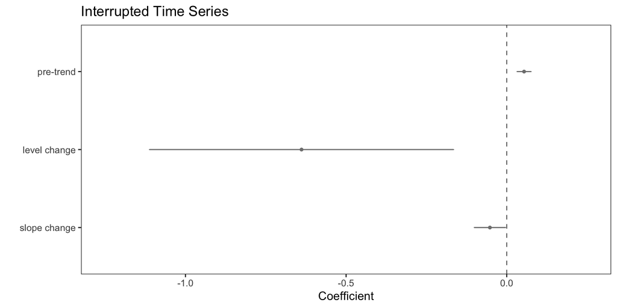

```r
# its results plot

ggplot(dataframe_its_plot, aes(x=reorder(name, order), y=coefs)) +
  geom_point(size=1, position=position_dodge(width=0.3), color = "gray50") +
  geom_errorbar(aes(ymin=lower, ymax=upper), color = "gray50", width=.01, position=position_dodge(width=0.3)) +
  coord_flip() + theme_bw() + geom_hline(yintercept=0, linetype="dashed",
                                         color = "gray50", size=0.5) +
  ylab("Coefficient") + xlab("") + theme(legend.title=element_blank()) +
  theme(panel.grid.major = element_blank(), panel.grid.minor = element_blank()) + ggtitle("Interrupted Time Series") +
  ylim(-1.25, 0.25)
```

## Table S9

```r
# load dataset

load("./dataframe1.RData")

# increase maximum print to show full regression outputs

options(max.print=1000000)

# Model 1 in Table S9

model1 <- as.formula(paste("rile ~ lag_rile + lag_cmedian + lag_econ_glob + lag_econ_glob*lag_rile + spruled + year_fe2 + year_fe3 + year_fe4 +  year_fe5 + year_fe6 +
year_fe7 +  year_fe8 +  year_fe9 +  year_fe10 + year_fe11 + year_fe12 + year_fe13 + year_fe14 + year_fe15 + year_fe16 + year_fe17 + year_fe18 + year_fe19 + year_fe20 + year_fe21 + year_fe22 + year_fe23 + year_fe24 + year_fe25 + year_fe26 + year_fe27 + year_fe28 + year_fe29 + year_fe30 +
year_fe31 + year_fe32 + year_fe33 + year_fe34 +" , paste(partyfx, collapse= "+")))

model1 <- lm(model1, data = dataframe1)
summary(model1)
```

```
##
## Call:
## lm(formula = model1, data = dataframe1)
##
## Residuals:
##     Min      1Q  Median      3Q     Max
## -1.9527 -0.1003 -0.0010  0.1091  2.0865
##
## Coefficients:
##                          Estimate Std. Error t value Pr(>|t|)
## (Intercept)            -0.5468756  0.4596029  -1.190 0.234205
## lag_rile                1.0214492  0.0692642  14.747  < 2e-16 ***
## lag_cmedian             0.0168239  0.0375226   0.448 0.653927
## lag_econ_glob           0.0165164  0.0054119   3.052 0.002298 **
## spruled                 0.0035448  0.0012017   2.950 0.003209 **
## year_fe2                0.0203963  0.0673649   0.303 0.762088
## year_fe3                0.0235843  0.0666240   0.354 0.723375
## year_fe4                0.0265687  0.0671950   0.395 0.692584
## year_fe5                0.0822865  0.0678763   1.212 0.225514
## year_fe6                0.1586313  0.0683119   2.322 0.020305 *
## year_fe7                0.1422453  0.0698833   2.035 0.041910 *
## year_fe8                0.1147001  0.0664395   1.726 0.084403 .
## year_fe9               -0.0501709  0.0742078  -0.676 0.499049
## year_fe10              -0.0204543  0.0846743  -0.242 0.809138
## year_fe11               0.0164423  0.0751545   0.219 0.826840
## year_fe12               0.0403769  0.0711623   0.567 0.570500
## year_fe13               0.1132298  0.0668670   1.693 0.090514 .
## year_fe14               0.1190794  0.0668070   1.782 0.074801 .
## year_fe15              -0.1664771  0.0848316  -1.962 0.049823 *
## year_fe16              -0.1577835  0.1094828  -1.441 0.149663
## year_fe17              -0.1404508  0.1037532  -1.354 0.175956
## year_fe18              -0.0937904  0.1046338  -0.896 0.370144
## year_fe19              -0.0448908  0.0932825  -0.481 0.630392
## year_fe20              -0.1350197  0.1341197  -1.007 0.314173
## year_fe21              -0.1947966  0.1412786  -1.379 0.168078
## year_fe22              -0.1816584  0.1389229  -1.308 0.191124
## year_fe23              -0.2870745  0.1566214  -1.833 0.066935 .
## year_fe24              -0.2907790  0.1585418  -1.834 0.066762 .
## year_fe25              -0.2128010  0.1475668  -1.442 0.149411
## year_fe26              -0.2604478  0.1539438  -1.692 0.090804 .
```

[output cut: 214 more lines]

```
## party_fe208             0.3555012  0.1589191   2.237 0.025376 *
## party_fe209             0.1739252  0.1593218   1.092 0.275089
## party_fe210             0.2301633  0.1594787   1.443 0.149085
## party_fe211             0.3635491  0.1593357   2.282 0.022595 *
## party_fe212             0.1635946  0.2460620   0.665 0.506208
## party_fe213             0.3023090  0.1596201   1.894 0.058352 .
## party_fe214             0.2350078  0.1594257   1.474 0.140585
## party_fe215             0.4416964  0.1606026   2.750 0.005999 **
## lag_rile:lag_econ_glob -0.0034691  0.0008891  -3.902 9.81e-05 ***
## ---
## Signif. codes:  0 '***' 0.001 '**' 0.01 '*' 0.05 '.' 0.1 ' ' 1
##
## Residual standard error: 0.3238 on 2465 degrees of freedom
## Multiple R-squared:  0.8885, Adjusted R-squared:  0.8771
## F-statistic: 77.94 on 252 and 2465 DF,  p-value: < 2.2e-16
```

```r
stargazer(model1)
```

```
##
## % Table created by stargazer v.5.2.2 by Marek Hlavac, Harvard University. E-mail: hlavac at fas.harvard.edu
## % Date and time: Thu, Jul 01, 2021 - 15:53:13
## \begin{table}[!htbp] \centering
##   \caption{}
##   \label{}
## \begin{tabular}{@{\extracolsep{5pt}}lc}
## \\[-1.8ex]\hline
## \hline \\[-1.8ex]
##  & \multicolumn{1}{c}{\textit{Dependent variable:}} \\
## \cline{2-2}
## \\[-1.8ex] & rile \\
## \hline \\[-1.8ex]
##  lag\_rile & 1.021$^{***}$ \\
##   & (0.069) \\
##   & \\
##  lag\_cmedian & 0.017 \\
##   & (0.038) \\
##   & \\
##  lag\_econ\_glob & 0.017$^{***}$ \\
##   & (0.005) \\
##   & \\
##  spruled & 0.004$^{***}$ \\
##   & (0.001) \\
##   & \\
##  year\_fe2 & 0.020 \\
##   & (0.067) \\
##   & \\
##  year\_fe3 & 0.024 \\
##   & (0.067) \\
##   & \\
##  year\_fe4 & 0.027 \\
##   & (0.067) \\
##   & \\
##  year\_fe5 & 0.082 \\
##   & (0.068) \\
##   & \\
##  year\_fe6 & 0.159$^{**}$ \\
##   & (0.068) \\
##   & \\
```

[output cut: 728 more lines]

```
##   & \\
##  Constant & $-$0.547 \\
##   & (0.460) \\
##   & \\
## \hline \\[-1.8ex]
## Observations & 2,718 \\
## R$^{2}$ & 0.888 \\
## Adjusted R$^{2}$ & 0.877 \\
## Residual Std. Error & 0.324 (df = 2465) \\
## F Statistic & 77.937$^{***}$ (df = 252; 2465) \\
## \hline
## \hline \\[-1.8ex]
## \textit{Note:}  & \multicolumn{1}{r}{$^{*}$p$<$0.1; $^{**}$p$<$0.05; $^{***}$p$<$0.01} \\
## \end{tabular}
## \end{table}
```

```r
# Model 2 in Table S9

model2 <- as.formula(paste("rile ~ lag_rile + lag_cmedian + lag_econ_glob + lag_econ_glob*lag_rile + spsamegroup_ruled + year_fe2 + year_fe3 + year_fe4 +  year_fe5 + year_fe6 + year_fe7 +  year_fe8 +  year_fe9 +  year_fe10 + year_fe11 + year_fe12 + year_fe13 + year_fe14 + year_fe15 + year_fe16 + year_fe17 + year_fe18 + year_fe19 + year_fe20 + year_fe21 + year_fe22 + year_fe23 + year_fe24 + year_fe25 + year_fe26 + year_fe27 + year_fe28 + year_fe29 + year_fe30 + year_fe31 + year_fe32 + year_fe33 + year_fe34 +" , paste(partyfx, collapse= "+")))

model2 <- lm(model2, data = dataframe1)
summary(model2)
```

```
##
## Call:
## lm(formula = model2, data = dataframe1)
##
## Residuals:
##      Min       1Q   Median       3Q      Max
## -1.92330 -0.09753 -0.00048  0.11218  2.10462
##
## Coefficients:
##                          Estimate Std. Error t value Pr(>|t|)
## (Intercept)            -2.903e-01  4.506e-01  -0.644 0.519542
## lag_rile                1.007e+00  6.920e-02  14.558  < 2e-16 ***
## lag_cmedian             1.930e-02  3.756e-02   0.514 0.607294
## lag_econ_glob           1.578e-02  5.403e-03   2.920 0.003533 **
## spsamegroup_ruled       1.691e-03  6.733e-04   2.512 0.012080 *
## year_fe2                3.307e-02  6.725e-02   0.492 0.622926
## year_fe3                7.793e-03  6.668e-02   0.117 0.906974
## year_fe4                3.552e-02  6.704e-02   0.530 0.596261
## year_fe5                1.063e-01  6.713e-02   1.583 0.113447
## year_fe6                1.123e-01  6.718e-02   1.672 0.094595 .
## year_fe7                7.916e-02  6.738e-02   1.175 0.240226
## year_fe8                1.057e-01  6.653e-02   1.590 0.112057
## year_fe9                3.470e-02  6.714e-02   0.517 0.605278
## year_fe10               1.311e-01  6.496e-02   2.018 0.043676 *
## year_fe11               1.184e-01  6.475e-02   1.828 0.067676 .
## year_fe12               1.183e-01  6.458e-02   1.832 0.067145 .
## year_fe13               1.443e-01  6.541e-02   2.206 0.027462 *
## year_fe14               1.197e-01  6.687e-02   1.790 0.073619 .
## year_fe15              -3.202e-02  6.779e-02  -0.472 0.636707
## year_fe16               7.272e-02  6.912e-02   1.052 0.292902
## year_fe17               6.674e-02  6.927e-02   0.963 0.335413
## year_fe18               1.044e-01  7.134e-02   1.464 0.143335
## year_fe19               9.997e-02  7.293e-02   1.371 0.170573
## year_fe20               1.719e-01  7.155e-02   2.403 0.016332 *
## year_fe21               1.329e-01  7.355e-02   1.807 0.070828 .
## year_fe22               1.281e-01  7.697e-02   1.665 0.096089 .
## year_fe23               5.646e-02  8.148e-02   0.693 0.488378
## year_fe24               5.631e-02  8.235e-02   0.684 0.494125
## year_fe25               8.901e-02  8.680e-02   1.025 0.305228
## year_fe26               7.003e-02  8.481e-02   0.826 0.409057
```

[output cut: 214 more lines]

```
## party_fe208             3.455e-01  1.589e-01   2.175 0.029759 *
## party_fe209             1.786e-01  1.595e-01   1.120 0.262834
## party_fe210             2.352e-01  1.597e-01   1.473 0.140870
## party_fe211             3.451e-01  1.593e-01   2.166 0.030428 *
## party_fe212             1.684e-01  2.463e-01   0.684 0.494180
## party_fe213             3.076e-01  1.598e-01   1.925 0.054399 .
## party_fe214             2.399e-01  1.596e-01   1.503 0.132907
## party_fe215             4.481e-01  1.608e-01   2.787 0.005368 **
## lag_rile:lag_econ_glob -3.313e-03  8.881e-04  -3.730 0.000195 ***
## ---
## Signif. codes:  0 '***' 0.001 '**' 0.01 '*' 0.05 '.' 0.1 ' ' 1
##
## Residual standard error: 0.324 on 2465 degrees of freedom
## Multiple R-squared:  0.8884, Adjusted R-squared:  0.877
## F-statistic: 77.85 on 252 and 2465 DF,  p-value: < 2.2e-16
```

```r
stargazer(model2)
```

```
##
## % Table created by stargazer v.5.2.2 by Marek Hlavac, Harvard University. E-mail: hlavac at fas.harvard.edu
## % Date and time: Thu, Jul 01, 2021 - 15:53:15
## \begin{table}[!htbp] \centering
##   \caption{}
##   \label{}
## \begin{tabular}{@{\extracolsep{5pt}}lc}
## \\[-1.8ex]\hline
## \hline \\[-1.8ex]
##  & \multicolumn{1}{c}{\textit{Dependent variable:}} \\
## \cline{2-2}
## \\[-1.8ex] & rile \\
## \hline \\[-1.8ex]
##  lag\_rile & 1.007$^{***}$ \\
##   & (0.069) \\
##   & \\
##  lag\_cmedian & 0.019 \\
##   & (0.038) \\
##   & \\
##  lag\_econ\_glob & 0.016$^{***}$ \\
##   & (0.005) \\
##   & \\
##  spsamegroup\_ruled & 0.002$^{**}$ \\
##   & (0.001) \\
##   & \\
##  year\_fe2 & 0.033 \\
##   & (0.067) \\
##   & \\
##  year\_fe3 & 0.008 \\
##   & (0.067) \\
##   & \\
##  year\_fe4 & 0.036 \\
##   & (0.067) \\
##   & \\
##  year\_fe5 & 0.106 \\
##   & (0.067) \\
##   & \\
##  year\_fe6 & 0.112$^{*}$ \\
##   & (0.067) \\
##   & \\
```

[output cut: 728 more lines]

```
##   & \\
##  Constant & $-$0.290 \\
##   & (0.451) \\
##   & \\
## \hline \\[-1.8ex]
## Observations & 2,718 \\
## R$^{2}$ & 0.888 \\
## Adjusted R$^{2}$ & 0.877 \\
## Residual Std. Error & 0.324 (df = 2465) \\
## F Statistic & 77.852$^{***}$ (df = 252; 2465) \\
## \hline
## \hline \\[-1.8ex]
## \textit{Note:}  & \multicolumn{1}{r}{$^{*}$p$<$0.1; $^{**}$p$<$0.05; $^{***}$p$<$0.01} \\
## \end{tabular}
## \end{table}
```

```r
# Model 3 in Table S9

model3 <- as.formula(paste("rile ~ lag_rile + lag_cmedian + lag_econ_glob + lag_econ_glob*lag_rile + spdiffgroup_ruled + year_fe2 + year_fe3 + year_fe4 +  year_fe5 + year_fe6 + year_fe7 +  year_fe8 +  year_fe9 +  year_fe10 + year_fe11 + year_fe12 + year_fe13 + year_fe14 + year_fe15 + year_fe16 + year_fe17 + year_fe18 + year_fe19 + year_fe20 + year_fe21 + year_fe22 + year_fe23 + year_fe24 + year_fe25 + year_fe26 + year_fe27 + year_fe28 + year_fe29 + year_fe30 + year_fe31 + year_fe32 + year_fe33 + year_fe34 +" , paste(partyfx, collapse= "+")))

model3 <- lm(model3, data = dataframe1)
summary(model3)
```

```
##
## Call:
## lm(formula = model3, data = dataframe1)
##
## Residuals:
##      Min       1Q   Median       3Q      Max
## -1.93521 -0.09663 -0.00179  0.11110  2.11625
##
## Coefficients:
##                          Estimate Std. Error t value Pr(>|t|)
## (Intercept)            -0.2645696  0.4519096  -0.585 0.558300
## lag_rile                1.0076791  0.0694991  14.499  < 2e-16 ***
## lag_cmedian             0.0165714  0.0375873   0.441 0.659340
## lag_econ_glob           0.0151525  0.0054219   2.795 0.005235 **
## spdiffgroup_ruled       0.0001336  0.0002833   0.472 0.637141
## year_fe2                0.0333902  0.0673364   0.496 0.620030
## year_fe3                0.0140330  0.0667865   0.210 0.833594
## year_fe4                0.0436320  0.0671431   0.650 0.515858
## year_fe5                0.1123493  0.0672186   1.671 0.094769 .
## year_fe6                0.1195605  0.0672054   1.779 0.075358 .
## year_fe7                0.0859823  0.0674142   1.275 0.202276
## year_fe8                0.1111034  0.0666405   1.667 0.095600 .
## year_fe9                0.0407664  0.0674491   0.604 0.545632
## year_fe10               0.1374563  0.0652033   2.108 0.035121 *
## year_fe11               0.1261168  0.0651776   1.935 0.053108 .
## year_fe12               0.1260815  0.0649676   1.941 0.052411 .
## year_fe13               0.1541059  0.0656476   2.347 0.018980 *
## year_fe14               0.1284830  0.0670496   1.916 0.055450 .
## year_fe15              -0.0191841  0.0682383  -0.281 0.778631
## year_fe16               0.0885932  0.0696346   1.272 0.203402
## year_fe17               0.0840805  0.0695689   1.209 0.226936
## year_fe18               0.1285287  0.0716772   1.793 0.073070 .
## year_fe19               0.1245009  0.0731193   1.703 0.088749 .
## year_fe20               0.1953658  0.0718410   2.719 0.006586 **
## year_fe21               0.1568043  0.0737835   2.125 0.033670 *
## year_fe22               0.1545638  0.0774459   1.996 0.046069 *
## year_fe23               0.1009991  0.0825077   1.224 0.221025
## year_fe24               0.1026692  0.0831571   1.235 0.217081
## year_fe25               0.1336437  0.0876335   1.525 0.127380
## year_fe26               0.1114321  0.0862753   1.292 0.196621
```

[output cut: 214 more lines]

```
## party_fe208             0.3395019  0.1608586   2.111 0.034911 *
## party_fe209             0.1715851  0.1615451   1.062 0.288272
## party_fe210             0.2276855  0.1616853   1.408 0.159198
## party_fe211             0.3563954  0.1602715   2.224 0.026259 *
## party_fe212             0.1570181  0.2483353   0.632 0.527261
## party_fe213             0.2997235  0.1618139   1.852 0.064106 .
## party_fe214             0.2325701  0.1616374   1.439 0.150323
## party_fe215             0.4386138  0.1627327   2.695 0.007080 **
## lag_rile:lag_econ_glob -0.0032844  0.0008925  -3.680 0.000238 ***
## ---
## Signif. codes:  0 '***' 0.001 '**' 0.01 '*' 0.05 '.' 0.1 ' ' 1
##
## Residual standard error: 0.3244 on 2465 degrees of freedom
## Multiple R-squared:  0.8881, Adjusted R-squared:  0.8767
## F-statistic: 77.64 on 252 and 2465 DF,  p-value: < 2.2e-16
```

```r
stargazer(model3)
```

```
##
## % Table created by stargazer v.5.2.2 by Marek Hlavac, Harvard University. E-mail: hlavac at fas.harvard.edu
## % Date and time: Thu, Jul 01, 2021 - 15:53:15
## \begin{table}[!htbp] \centering
##   \caption{}
##   \label{}
## \begin{tabular}{@{\extracolsep{5pt}}lc}
## \\[-1.8ex]\hline
## \hline \\[-1.8ex]
##  & \multicolumn{1}{c}{\textit{Dependent variable:}} \\
## \cline{2-2}
## \\[-1.8ex] & rile \\
## \hline \\[-1.8ex]
##  lag\_rile & 1.008$^{***}$ \\
##   & (0.069) \\
##   & \\
##  lag\_cmedian & 0.017 \\
##   & (0.038) \\
##   & \\
##  lag\_econ\_glob & 0.015$^{***}$ \\
##   & (0.005) \\
##   & \\
##  spdiffgroup\_ruled & 0.0001 \\
##   & (0.0003) \\
##   & \\
##  year\_fe2 & 0.033 \\
##   & (0.067) \\
##   & \\
##  year\_fe3 & 0.014 \\
##   & (0.067) \\
##   & \\
##  year\_fe4 & 0.044 \\
##   & (0.067) \\
##   & \\
##  year\_fe5 & 0.112$^{*}$ \\
##   & (0.067) \\
##   & \\
##  year\_fe6 & 0.120$^{*}$ \\
##   & (0.067) \\
##   & \\
```

[output cut: 728 more lines]

```
##   & \\
##  Constant & $-$0.265 \\
##   & (0.452) \\
##   & \\
## \hline \\[-1.8ex]
## Observations & 2,718 \\
## R$^{2}$ & 0.888 \\
## Adjusted R$^{2}$ & 0.877 \\
## Residual Std. Error & 0.324 (df = 2465) \\
## F Statistic & 77.636$^{***}$ (df = 252; 2465) \\
## \hline
## \hline \\[-1.8ex]
## \textit{Note:}  & \multicolumn{1}{r}{$^{*}$p$<$0.1; $^{**}$p$<$0.05; $^{***}$p$<$0.01} \\
## \end{tabular}
## \end{table}
```

```r
# Model 4 in Table S9

model4 <- as.formula(paste("rile ~ lag_rile + lag_cmedian + lag_econ_glob + lag_econ_glob*lag_rile + spsamegroup_ruled + spdiffgroup_ruled + year_fe2 + year_fe3 + year_fe4 +  year_fe5 + year_fe6 + year_fe7 +  year_fe8 +  year_fe9 +  year_fe10 + year_fe11 + year_fe12 + year_fe13 + year_fe14 + year_fe15 + year_fe16 + year_fe17 + year_fe18 + year_fe19 + year_fe20 + year_fe21 + year_fe22 + year_fe23 + year_fe24 + year_fe25 + year_fe26 + year_fe27 + year_fe28 + year_fe29 + year_fe30 + year_fe31 + year_fe32 + year_fe33 + year_fe34 +" , paste(partyfx, collapse= "+")))

model4 <- lm(model4, data = dataframe1)
summary(model4)
```

```
##
## Call:
## lm(formula = model4, data = dataframe1)
##
## Residuals:
##      Min       1Q   Median       3Q      Max
## -1.92615 -0.09778 -0.00056  0.11174  2.10611
##
## Coefficients:
##                          Estimate Std. Error t value Pr(>|t|)
## (Intercept)            -2.842e-01  4.515e-01  -0.630 0.529073
## lag_rile                1.006e+00  6.943e-02  14.493  < 2e-16 ***
## lag_cmedian             1.925e-02  3.756e-02   0.512 0.608425
## lag_econ_glob           1.568e-02  5.420e-03   2.892 0.003856 **
## spsamegroup_ruled       1.676e-03  6.767e-04   2.477 0.013321 *
## spdiffgroup_ruled       6.479e-05  2.843e-04   0.228 0.819786
## year_fe2                3.308e-02  6.727e-02   0.492 0.622927
## year_fe3                7.025e-03  6.678e-02   0.105 0.916228
## year_fe4                3.459e-02  6.717e-02   0.515 0.606626
## year_fe5                1.056e-01  6.720e-02   1.572 0.116134
## year_fe6                1.120e-01  6.720e-02   1.667 0.095664 .
## year_fe7                7.894e-02  6.740e-02   1.171 0.241681
## year_fe8                1.050e-01  6.662e-02   1.576 0.115045
## year_fe9                3.327e-02  6.745e-02   0.493 0.621864
## year_fe10               1.298e-01  6.521e-02   1.991 0.046599 *
## year_fe11               1.166e-01  6.522e-02   1.788 0.073954 .
## year_fe12               1.166e-01  6.501e-02   1.794 0.072976 .
## year_fe13               1.428e-01  6.574e-02   2.173 0.029875 *
## year_fe14               1.184e-01  6.710e-02   1.765 0.077659 .
## year_fe15              -3.414e-02  6.843e-02  -0.499 0.617919
## year_fe16               7.029e-02  6.995e-02   1.005 0.315087
## year_fe17               6.457e-02  6.994e-02   0.923 0.356017
## year_fe18               1.016e-01  7.242e-02   1.403 0.160688
## year_fe19               9.732e-02  7.386e-02   1.318 0.187773
## year_fe20               1.692e-01  7.254e-02   2.333 0.019719 *
## year_fe21               1.303e-01  7.448e-02   1.749 0.080351 .
## year_fe22               1.249e-01  7.829e-02   1.595 0.110735
## year_fe23               5.108e-02  8.485e-02   0.602 0.547256
## year_fe24               5.095e-02  8.565e-02   0.595 0.551979
## year_fe25               8.375e-02  8.983e-02   0.932 0.351265
```

[output cut: 215 more lines]

```
## party_fe208             3.510e-01  1.608e-01   2.184 0.029089 *
## party_fe209             1.843e-01  1.615e-01   1.141 0.253781
## party_fe210             2.408e-01  1.616e-01   1.490 0.136282
## party_fe211             3.486e-01  1.601e-01   2.177 0.029560 *
## party_fe212             1.753e-01  2.482e-01   0.706 0.480073
## party_fe213             3.132e-01  1.617e-01   1.936 0.052929 .
## party_fe214             2.456e-01  1.616e-01   1.520 0.128612
## party_fe215             4.537e-01  1.627e-01   2.789 0.005331 **
## lag_rile:lag_econ_glob -3.296e-03  8.916e-04  -3.696 0.000223 ***
## ---
## Signif. codes:  0 '***' 0.001 '**' 0.01 '*' 0.05 '.' 0.1 ' ' 1
##
## Residual standard error: 0.3241 on 2464 degrees of freedom
## Multiple R-squared:  0.8884, Adjusted R-squared:  0.8769
## F-statistic: 77.51 on 253 and 2464 DF,  p-value: < 2.2e-16
```

```r
stargazer(model4)
```

```
##
## % Table created by stargazer v.5.2.2 by Marek Hlavac, Harvard University. E-mail: hlavac at fas.harvard.edu
## % Date and time: Thu, Jul 01, 2021 - 15:53:16
## \begin{table}[!htbp] \centering
##   \caption{}
##   \label{}
## \begin{tabular}{@{\extracolsep{5pt}}lc}
## \\[-1.8ex]\hline
## \hline \\[-1.8ex]
##  & \multicolumn{1}{c}{\textit{Dependent variable:}} \\
## \cline{2-2}
## \\[-1.8ex] & rile \\
## \hline \\[-1.8ex]
##  lag\_rile & 1.006$^{***}$ \\
##   & (0.069) \\
##   & \\
##  lag\_cmedian & 0.019 \\
##   & (0.038) \\
##   & \\
##  lag\_econ\_glob & 0.016$^{***}$ \\
##   & (0.005) \\
##   & \\
##  spsamegroup\_ruled & 0.002$^{**}$ \\
##   & (0.001) \\
##   & \\
##  spdiffgroup\_ruled & 0.0001 \\
##   & (0.0003) \\
##   & \\
##  year\_fe2 & 0.033 \\
##   & (0.067) \\
##   & \\
##  year\_fe3 & 0.007 \\
##   & (0.067) \\
##   & \\
##  year\_fe4 & 0.035 \\
##   & (0.067) \\
##   & \\
##  year\_fe5 & 0.106 \\
##   & (0.067) \\
##   & \\
```

[output cut: 731 more lines]

```
##   & \\
##  Constant & $-$0.284 \\
##   & (0.452) \\
##   & \\
## \hline \\[-1.8ex]
## Observations & 2,718 \\
## R$^{2}$ & 0.888 \\
## Adjusted R$^{2}$ & 0.877 \\
## Residual Std. Error & 0.324 (df = 2464) \\
## F Statistic & 77.515$^{***}$ (df = 253; 2464) \\
## \hline
## \hline \\[-1.8ex]
## \textit{Note:}  & \multicolumn{1}{r}{$^{*}$p$<$0.1; $^{**}$p$<$0.05; $^{***}$p$<$0.01} \\
## \end{tabular}
## \end{table}
```

## Table S10

```r
# load datasets

load("./dataframe_eu.RData")
load("./dataframe_multicult.RData")
load("./dataframe_auth.RData")
load("./dataframe_eco.RData")
load("./dataframe_regu.RData")

# increase maximum print to show full regression outputs

options(max.print=1000000)

model_eu <- as.formula(paste("euroscep ~ lag_euroscep + lag_cmedian + lag_econ_glob + interaction + spsamegroup_ruled_euroscep + year_fe2 + year_fe3 + year_fe4 +  year_fe5 + year_fe6 + year_fe7 +  year_fe8 +  year_fe9 +  year_fe10 + year_fe11 + year_fe12 + year_fe13 + year_fe14 + year_fe15 + year_fe16 + year_fe17 + year_fe18 + year_fe19 + year_fe20 + year_fe21 + year_fe22 + year_fe23 + year_fe24 + year_fe25 + year_fe26 + year_fe27 + year_fe28 + year_fe29 + year_fe30 + year_fe31 + year_fe32 + year_fe33 + year_fe34 +  " , paste(partyfx, collapse= "+")))

model_eu <- lm(model_eu, data = dataframe_eu)
summary(model_eu)
```

```
##
## Call:
## lm(formula = model_eu, data = dataframe_eu)
##
## Residuals:
##      Min       1Q   Median       3Q      Max
## -1.09666 -0.01843  0.00168  0.02165  0.85060
##
## Coefficients: (56 not defined because of singularities)
##                              Estimate Std. Error t value Pr(>|t|)
## (Intercept)                 1.5535223  0.2081215   7.464 1.16e-13 ***
## lag_euroscep                0.7112242  0.0138809  51.238  < 2e-16 ***
## lag_cmedian                 0.0198089  0.0363461   0.545 0.585799
## lag_econ_glob               0.0011625  0.0025987   0.447 0.654676
## interaction                -0.0002717  0.0004862  -0.559 0.576317
## spsamegroup_ruled_euroscep -0.0001976  0.0001694  -1.166 0.243642
## year_fe2                    0.0285099  0.0156023   1.827 0.067780 .
## year_fe3                    0.0159180  0.0154401   1.031 0.302667
## year_fe4                    0.0193871  0.0155303   1.248 0.212028
## year_fe5                    0.0192517  0.0155560   1.238 0.215995
## year_fe6                    0.0187338  0.0153213   1.223 0.221551
## year_fe7                    0.0175659  0.0155953   1.126 0.260128
## year_fe8                    0.0123896  0.0153968   0.805 0.421080
## year_fe9                    0.0133892  0.0155291   0.862 0.388661
## year_fe10                  -0.0028955  0.0150325  -0.193 0.847274
## year_fe11                  -0.0004196  0.0149796  -0.028 0.977655
## year_fe12                  -0.0102651  0.0149457  -0.687 0.492258
## year_fe13                  -0.0218248  0.0150512  -1.450 0.147178
## year_fe14                  -0.0109065  0.0155207  -0.703 0.482307
## year_fe15                   0.0066333  0.0157438   0.421 0.673553
## year_fe16                  -0.0084110  0.0160552  -0.524 0.600408
## year_fe17                   0.0002447  0.0161145   0.015 0.987888
## year_fe18                   0.0205089  0.0165311   1.241 0.214867
## year_fe19                   0.0175737  0.0168789   1.041 0.297904
## year_fe20                   0.0111491  0.0166745   0.669 0.503792
## year_fe21                   0.0154743  0.0171594   0.902 0.367256
## year_fe22                   0.0140602  0.0179834   0.782 0.434382
## year_fe23                  -0.0017579  0.0188012  -0.094 0.925513
## year_fe24                   0.0169129  0.0189782   0.891 0.372924
## year_fe25                   0.0148819  0.0201307   0.739 0.459817
```

[output cut: 214 more lines]

```
## party_fe207                -0.0800317  0.0427576  -1.872 0.061362 .
## party_fe208                -0.0911939  0.0371989  -2.452 0.014296 *
## party_fe209                -0.0610044  0.0376083  -1.622 0.104913
## party_fe210                -0.0720185  0.0370966  -1.941 0.052329 .
## party_fe211                -0.0575095  0.0372923  -1.542 0.123174
## party_fe212                        NA         NA      NA       NA
## party_fe213                -0.0870659  0.0372314  -2.339 0.019443 *
## party_fe214                -0.0727244  0.0371462  -1.958 0.050371 .
## party_fe215                -0.0469451  0.0369870  -1.269 0.204481
## ---
## Signif. codes:  0 '***' 0.001 '**' 0.01 '*' 0.05 '.' 0.1 ' ' 1
##
## Residual standard error: 0.07511 on 2402 degrees of freedom
## Multiple R-squared:  0.7748, Adjusted R-squared:  0.7564
## F-statistic: 42.17 on 196 and 2402 DF,  p-value: < 2.2e-16
```

```r
model_multicult <- as.formula(paste("multicult ~ lag_multicult + lag_cmedian + lag_econ_glob + interaction + spsamegroup_ruled_multicult + year_fe2 + year_fe3 + year_fe4 +  year_fe5 + year_fe6 +
year_fe7 +  year_fe8 +  year_fe9 +  year_fe10 + year_fe11 + year_fe12 + year_fe13 + year_fe14 + year_fe15 + year_fe16 + year_fe17 + year_fe18 + year_fe19 + year_fe20 + year_fe21 + year_fe22 + year_fe23 + year_fe24 + year_fe25 + year_fe26 + year_fe27 + year_fe28 + year_fe29 + year_fe30 +
year_fe31 + year_fe32 + year_fe33 + year_fe34 +  " , paste(partyfx, collapse= "+")))

model_multicult <- lm(model_multicult, data = dataframe_multicult)
summary(model_multicult)
```

```
##
## Call:
## lm(formula = model_multicult, data = dataframe_multicult)
##
## Residuals:
##      Min       1Q   Median       3Q      Max
## -0.70572 -0.00716  0.00100  0.00824  0.58816
##
## Coefficients: (56 not defined because of singularities)
##                               Estimate Std. Error t value Pr(>|t|)
## (Intercept)                  1.974e+00  1.375e-01  14.353  < 2e-16 ***
## lag_multicult                6.829e-01  1.410e-02  48.428  < 2e-16 ***
## lag_cmedian                 -5.315e-02  2.070e-02  -2.568 0.010287 *
## lag_econ_glob               -3.403e-03  1.480e-03  -2.299 0.021603 *
## interaction                  7.613e-04  2.769e-04   2.749 0.006018 **
## spsamegroup_ruled_multicult  5.940e-05  9.359e-05   0.635 0.525714
## year_fe2                    -3.823e-03  8.865e-03  -0.431 0.666332
## year_fe3                    -1.055e-03  8.774e-03  -0.120 0.904284
## year_fe4                    -3.588e-03  8.826e-03  -0.407 0.684386
## year_fe5                    -1.057e-02  8.841e-03  -1.195 0.232092
## year_fe6                    -5.388e-03  8.707e-03  -0.619 0.536082
## year_fe7                    -7.285e-03  8.862e-03  -0.822 0.411175
## year_fe8                    -4.903e-03  8.749e-03  -0.560 0.575267
## year_fe9                    -6.748e-03  8.824e-03  -0.765 0.444490
## year_fe10                   -9.406e-03  8.541e-03  -1.101 0.270865
## year_fe11                   -9.316e-03  8.506e-03  -1.095 0.273524
## year_fe12                   -8.479e-03  8.484e-03  -0.999 0.317717
## year_fe13                   -9.617e-03  8.538e-03  -1.126 0.260157
## year_fe14                   -9.706e-03  8.794e-03  -1.104 0.269862
## year_fe15                   -8.675e-03  8.921e-03  -0.972 0.330937
## year_fe16                   -2.248e-02  9.104e-03  -2.469 0.013600 *
## year_fe17                   -1.108e-02  9.137e-03  -1.213 0.225165
## year_fe18                   -7.348e-04  9.383e-03  -0.078 0.937591
## year_fe19                   -5.928e-03  9.585e-03  -0.618 0.536336
## year_fe20                   -1.175e-02  9.474e-03  -1.240 0.215012
## year_fe21                   -7.012e-03  9.749e-03  -0.719 0.472031
## year_fe22                   -7.598e-05  1.022e-02  -0.007 0.994068
## year_fe23                   -7.056e-03  1.069e-02  -0.660 0.509121
## year_fe24                   -8.659e-03  1.078e-02  -0.803 0.422042
## year_fe25                   -5.866e-03  1.144e-02  -0.513 0.608143
```

[output cut: 214 more lines]

```
## party_fe207                  2.673e-03  2.417e-02   0.111 0.911929
## party_fe208                 -4.745e-03  2.075e-02  -0.229 0.819168
## party_fe209                 -2.772e-03  2.127e-02  -0.130 0.896334
## party_fe210                 -1.458e-03  2.095e-02  -0.070 0.944496
## party_fe211                  6.366e-03  2.108e-02   0.302 0.762676
## party_fe212                         NA         NA      NA       NA
## party_fe213                  1.043e-02  2.096e-02   0.497 0.618931
## party_fe214                 -5.329e-05  2.097e-02  -0.003 0.997972
## party_fe215                  6.916e-03  2.096e-02   0.330 0.741468
## ---
## Signif. codes:  0 '***' 0.001 '**' 0.01 '*' 0.05 '.' 0.1 ' ' 1
##
## Residual standard error: 0.04268 on 2402 degrees of freedom
## Multiple R-squared:  0.7723, Adjusted R-squared:  0.7537
## F-statistic: 41.56 on 196 and 2402 DF,  p-value: < 2.2e-16
```

```r
stargazer(model_multicult)
```

```
##
## % Table created by stargazer v.5.2.2 by Marek Hlavac, Harvard University. E-mail: hlavac at fas.harvard.edu
## % Date and time: Thu, Jul 01, 2021 - 15:53:18
## \begin{table}[!htbp] \centering
##   \caption{}
##   \label{}
## \begin{tabular}{@{\extracolsep{5pt}}lc}
## \\[-1.8ex]\hline
## \hline \\[-1.8ex]
##  & \multicolumn{1}{c}{\textit{Dependent variable:}} \\
## \cline{2-2}
## \\[-1.8ex] & multicult \\
## \hline \\[-1.8ex]
##  lag\_multicult & 0.683$^{***}$ \\
##   & (0.014) \\
##   & \\
##  lag\_cmedian & $-$0.053$^{**}$ \\
##   & (0.021) \\
##   & \\
##  lag\_econ\_glob & $-$0.003$^{**}$ \\
##   & (0.001) \\
##   & \\
##  interaction & 0.001$^{***}$ \\
##   & (0.0003) \\
##   & \\
##  spsamegroup\_ruled\_multicult & 0.0001 \\
##   & (0.0001) \\
##   & \\
##  year\_fe2 & $-$0.004 \\
##   & (0.009) \\
##   & \\
##  year\_fe3 & $-$0.001 \\
##   & (0.009) \\
##   & \\
##  year\_fe4 & $-$0.004 \\
##   & (0.009) \\
##   & \\
##  year\_fe5 & $-$0.011 \\
##   & (0.009) \\
##   & \\
```

[output cut: 728 more lines]

```
##   & \\
##  Constant & 1.974$^{***}$ \\
##   & (0.138) \\
##   & \\
## \hline \\[-1.8ex]
## Observations & 2,599 \\
## R$^{2}$ & 0.772 \\
## Adjusted R$^{2}$ & 0.754 \\
## Residual Std. Error & 0.043 (df = 2402) \\
## F Statistic & 41.563$^{***}$ (df = 196; 2402) \\
## \hline
## \hline \\[-1.8ex]
## \textit{Note:}  & \multicolumn{1}{r}{$^{*}$p$<$0.1; $^{**}$p$<$0.05; $^{***}$p$<$0.01} \\
## \end{tabular}
## \end{table}
```

```r
model_auth <- as.formula(paste("auth ~ lag_auth + lag_cmedian + lag_econ_glob + interaction + spsamegroup_ruled_auth + year_fe2 + year_fe3 + year_fe4 +  year_fe5 + year_fe6 +
year_fe7 +  year_fe8 +  year_fe9 +  year_fe10 + year_fe11 + year_fe12 + year_fe13 + year_fe14 + year_fe15 + year_fe16 + year_fe17 + year_fe18 + year_fe19 + year_fe20 + year_fe21 + year_fe22 + year_fe23 + year_fe24 + year_fe25 + year_fe26 + year_fe27 + year_fe28 + year_fe29 + year_fe30 +
year_fe31 + year_fe32 + year_fe33 + year_fe34 +  " , paste(partyfx, collapse= "+")))

model_auth <- lm(model_auth, data = dataframe_auth)
summary(model_auth)
```

```
##
## Call:
## lm(formula = model_auth, data = dataframe_auth)
##
## Residuals:
##     Min      1Q  Median      3Q     Max
## -3.3246 -0.0707 -0.0092  0.0556  3.5848
##
## Coefficients: (56 not defined because of singularities)
##                          Estimate Std. Error t value Pr(>|t|)
## (Intercept)            -3.425e-01  7.139e-01  -0.480 0.631461
## lag_auth                7.065e-01  1.291e-02  54.733  < 2e-16 ***
## lag_cmedian             1.370e-01  1.369e-01   1.001 0.316857
## lag_econ_glob           1.494e-04  9.748e-03   0.015 0.987775
## interaction            -7.593e-04  1.826e-03  -0.416 0.677575
## spsamegroup_ruled_auth  1.294e-04  2.451e-03   0.053 0.957886
## year_fe2                6.748e-02  5.845e-02   1.154 0.248413
## year_fe3                1.100e-01  5.785e-02   1.901 0.057391 .
## year_fe4                9.813e-02  5.817e-02   1.687 0.091736 .
## year_fe5                7.693e-02  5.828e-02   1.320 0.186916
## year_fe6                1.324e-01  5.740e-02   2.308 0.021109 *
## year_fe7                1.168e-01  5.843e-02   1.999 0.045757 *
## year_fe8                1.341e-01  5.768e-02   2.326 0.020117 *
## year_fe9                1.168e-01  5.818e-02   2.007 0.044882 *
## year_fe10               1.750e-01  5.634e-02   3.105 0.001924 **
## year_fe11               3.309e-01  5.613e-02   5.896 4.25e-09 ***
## year_fe12               2.314e-01  5.613e-02   4.122 3.89e-05 ***
## year_fe13               2.394e-01  5.649e-02   4.238 2.34e-05 ***
## year_fe14               2.491e-01  5.829e-02   4.275 1.99e-05 ***
## year_fe15               1.980e-01  5.906e-02   3.352 0.000815 ***
## year_fe16               1.485e-01  6.023e-02   2.466 0.013725 *
## year_fe17               2.169e-01  6.034e-02   3.595 0.000331 ***
## year_fe18               2.931e-01  6.194e-02   4.732 2.35e-06 ***
## year_fe19               2.418e-01  6.329e-02   3.820 0.000137 ***
## year_fe20               2.135e-01  6.265e-02   3.408 0.000665 ***
## year_fe21               2.693e-01  6.442e-02   4.181 3.01e-05 ***
## year_fe22               2.124e-01  6.774e-02   3.135 0.001737 **
## year_fe23               2.498e-01  7.077e-02   3.530 0.000423 ***
## year_fe24               2.488e-01  7.143e-02   3.483 0.000505 ***
## year_fe25               2.198e-01  7.583e-02   2.899 0.003780 **
```

[output cut: 214 more lines]

```
## party_fe207             1.050e-01  1.593e-01   0.659 0.509693
## party_fe208             5.103e-02  1.367e-01   0.373 0.709016
## party_fe209            -4.889e-03  1.402e-01  -0.035 0.972185
## party_fe210            -1.150e-02  1.381e-01  -0.083 0.933594
## party_fe211            -3.356e-02  1.388e-01  -0.242 0.808902
## party_fe212                    NA         NA      NA       NA
## party_fe213            -8.868e-02  1.381e-01  -0.642 0.520873
## party_fe214            -2.803e-02  1.381e-01  -0.203 0.839179
## party_fe215            -1.654e-01  1.382e-01  -1.197 0.231538
## ---
## Signif. codes:  0 '***' 0.001 '**' 0.01 '*' 0.05 '.' 0.1 ' ' 1
##
## Residual standard error: 0.2814 on 2402 degrees of freedom
## Multiple R-squared:  0.7883, Adjusted R-squared:  0.7711
## F-statistic: 45.65 on 196 and 2402 DF,  p-value: < 2.2e-16
```

```r
stargazer(model_auth)
```

```
##
## % Table created by stargazer v.5.2.2 by Marek Hlavac, Harvard University. E-mail: hlavac at fas.harvard.edu
## % Date and time: Thu, Jul 01, 2021 - 15:53:19
## \begin{table}[!htbp] \centering
##   \caption{}
##   \label{}
## \begin{tabular}{@{\extracolsep{5pt}}lc}
## \\[-1.8ex]\hline
## \hline \\[-1.8ex]
##  & \multicolumn{1}{c}{\textit{Dependent variable:}} \\
## \cline{2-2}
## \\[-1.8ex] & auth \\
## \hline \\[-1.8ex]
##  lag\_auth & 0.707$^{***}$ \\
##   & (0.013) \\
##   & \\
##  lag\_cmedian & 0.137 \\
##   & (0.137) \\
##   & \\
##  lag\_econ\_glob & 0.0001 \\
##   & (0.010) \\
##   & \\
##  interaction & $-$0.001 \\
##   & (0.002) \\
##   & \\
##  spsamegroup\_ruled\_auth & 0.0001 \\
##   & (0.002) \\
##   & \\
##  year\_fe2 & 0.067 \\
##   & (0.058) \\
##   & \\
##  year\_fe3 & 0.110$^{*}$ \\
##   & (0.058) \\
##   & \\
##  year\_fe4 & 0.098$^{*}$ \\
##   & (0.058) \\
##   & \\
##  year\_fe5 & 0.077 \\
##   & (0.058) \\
##   & \\
```

[output cut: 728 more lines]

```
##   & \\
##  Constant & $-$0.342 \\
##   & (0.714) \\
##   & \\
## \hline \\[-1.8ex]
## Observations & 2,599 \\
## R$^{2}$ & 0.788 \\
## Adjusted R$^{2}$ & 0.771 \\
## Residual Std. Error & 0.281 (df = 2402) \\
## F Statistic & 45.646$^{***}$ (df = 196; 2402) \\
## \hline
## \hline \\[-1.8ex]
## \textit{Note:}  & \multicolumn{1}{r}{$^{*}$p$<$0.1; $^{**}$p$<$0.05; $^{***}$p$<$0.01} \\
## \end{tabular}
## \end{table}
```

```r
model_eco <- as.formula(paste("eco ~ lag_eco + lag_cmedian + lag_econ_glob + interaction + spsamegroup_ruled_eco + year_fe2 + year_fe3 + year_fe4 +  year_fe5 + year_fe6 +
year_fe7 +  year_fe8 +  year_fe9 +  year_fe10 + year_fe11 + year_fe12 + year_fe13 + year_fe14 + year_fe15 + year_fe16 + year_fe17 + year_fe18 + year_fe19 + year_fe20 + year_fe21 + year_fe22 + year_fe23 + year_fe24 + year_fe25 + year_fe26 + year_fe27 + year_fe28 + year_fe29 + year_fe30 +
year_fe31 + year_fe32 + year_fe33 + year_fe34 +  " , paste(partyfx, collapse= "+")))

model_eco <- lm(model_eco, data = dataframe_eco)
summary(model_eco)
```

```
##
## Call:
## lm(formula = model_eco, data = dataframe_eco)
##
## Residuals:
##      Min       1Q   Median       3Q      Max
## -1.05150 -0.02341 -0.00131  0.01884  1.73247
##
## Coefficients: (56 not defined because of singularities)
##                         Estimate Std. Error t value Pr(>|t|)
## (Intercept)            0.0517204  0.2798553   0.185 0.853393
## lag_eco                0.6669112  0.0145217  45.925  < 2e-16 ***
## lag_cmedian            0.0570435  0.0534815   1.067 0.286258
## lag_econ_glob          0.0057554  0.0038245   1.505 0.132488
## interaction           -0.0009303  0.0007153  -1.301 0.193545
## spsamegroup_ruled_eco  0.0015905  0.0011013   1.444 0.148804
## year_fe2              -0.0742361  0.0229825  -3.230 0.001254 **
## year_fe3              -0.0294342  0.0227372  -1.295 0.195604
## year_fe4              -0.0475020  0.0228793  -2.076 0.037982 *
## year_fe5              -0.0398788  0.0229210  -1.740 0.082016 .
## year_fe6              -0.0614407  0.0225766  -2.721 0.006547 **
## year_fe7              -0.0486674  0.0229752  -2.118 0.034256 *
## year_fe8              -0.0796036  0.0226851  -3.509 0.000458 ***
## year_fe9              -0.0403349  0.0228662  -1.764 0.077867 .
## year_fe10             -0.0335897  0.0221431  -1.517 0.129414
## year_fe11             -0.0499443  0.0220687  -2.263 0.023717 *
## year_fe12             -0.0914968  0.0220149  -4.156 3.35e-05 ***
## year_fe13             -0.0859069  0.0221213  -3.883 0.000106 ***
## year_fe14             -0.0606903  0.0227828  -2.664 0.007777 **
## year_fe15             -0.0877469  0.0231121  -3.797 0.000150 ***
## year_fe16             -0.0748960  0.0235846  -3.176 0.001514 **
## year_fe17             -0.0831182  0.0236655  -3.512 0.000453 ***
## year_fe18             -0.0638401  0.0243149  -2.626 0.008706 **
## year_fe19             -0.0742842  0.0248154  -2.993 0.002786 **
## year_fe20             -0.0817845  0.0245745  -3.328 0.000888 ***
## year_fe21             -0.0724711  0.0252893  -2.866 0.004197 **
## year_fe22             -0.0860628  0.0264809  -3.250 0.001170 **
## year_fe23             -0.0922814  0.0276953  -3.332 0.000875 ***
## year_fe24             -0.0895093  0.0279542  -3.202 0.001383 **
## year_fe25             -0.1017987  0.0296154  -3.437 0.000597 ***
```

[output cut: 214 more lines]

```
## party_fe207            0.0195569  0.0625783   0.313 0.754673
## party_fe208            0.0147787  0.0537424   0.275 0.783346
## party_fe209            0.0278003  0.0549959   0.505 0.613255
## party_fe210            0.1006302  0.0543886   1.850 0.064406 .
## party_fe211            0.1208839  0.0548742   2.203 0.027694 *
## party_fe212                   NA         NA      NA       NA
## party_fe213           -0.0042062  0.0543004  -0.077 0.938263
## party_fe214            0.0358349  0.0543869   0.659 0.510030
## party_fe215            0.0091775  0.0542784   0.169 0.865746
## ---
## Signif. codes:  0 '***' 0.001 '**' 0.01 '*' 0.05 '.' 0.1 ' ' 1
##
## Residual standard error: 0.1106 on 2402 degrees of freedom
## Multiple R-squared:  0.7962, Adjusted R-squared:  0.7796
## F-statistic: 47.88 on 196 and 2402 DF,  p-value: < 2.2e-16
```

```r
stargazer(model_eco)
```

```
##
## % Table created by stargazer v.5.2.2 by Marek Hlavac, Harvard University. E-mail: hlavac at fas.harvard.edu
## % Date and time: Thu, Jul 01, 2021 - 15:53:19
## \begin{table}[!htbp] \centering
##   \caption{}
##   \label{}
## \begin{tabular}{@{\extracolsep{5pt}}lc}
## \\[-1.8ex]\hline
## \hline \\[-1.8ex]
##  & \multicolumn{1}{c}{\textit{Dependent variable:}} \\
## \cline{2-2}
## \\[-1.8ex] & eco \\
## \hline \\[-1.8ex]
##  lag\_eco & 0.667$^{***}$ \\
##   & (0.015) \\
##   & \\
##  lag\_cmedian & 0.057 \\
##   & (0.053) \\
##   & \\
##  lag\_econ\_glob & 0.006 \\
##   & (0.004) \\
##   & \\
##  interaction & $-$0.001 \\
##   & (0.001) \\
##   & \\
##  spsamegroup\_ruled\_eco & 0.002 \\
##   & (0.001) \\
##   & \\
##  year\_fe2 & $-$0.074$^{***}$ \\
##   & (0.023) \\
##   & \\
##  year\_fe3 & $-$0.029 \\
##   & (0.023) \\
##   & \\
##  year\_fe4 & $-$0.048$^{**}$ \\
##   & (0.023) \\
##   & \\
##  year\_fe5 & $-$0.040$^{*}$ \\
##   & (0.023) \\
##   & \\
```

[output cut: 728 more lines]

```
##   & \\
##  Constant & 0.052 \\
##   & (0.280) \\
##   & \\
## \hline \\[-1.8ex]
## Observations & 2,599 \\
## R$^{2}$ & 0.796 \\
## Adjusted R$^{2}$ & 0.780 \\
## Residual Std. Error & 0.111 (df = 2402) \\
## F Statistic & 47.877$^{***}$ (df = 196; 2402) \\
## \hline
## \hline \\[-1.8ex]
## \textit{Note:}  & \multicolumn{1}{r}{$^{*}$p$<$0.1; $^{**}$p$<$0.05; $^{***}$p$<$0.01} \\
## \end{tabular}
## \end{table}
```

```r
model_regu <- as.formula(paste("regu ~ lag_regu + lag_cmedian + lag_econ_glob + interaction + spsamegroup_ruled_regu + year_fe2 + year_fe3 + year_fe4 +  year_fe5 + year_fe6 +
year_fe7 +  year_fe8 +  year_fe9 +  year_fe10 + year_fe11 + year_fe12 + year_fe13 + year_fe14 + year_fe15 + year_fe16 + year_fe17 + year_fe18 +  year_fe19 + year_fe20 + year_fe21 + year_fe22 + year_fe23 + year_fe24 + year_fe25 + year_fe26 + year_fe27 + year_fe28 + year_fe29 + year_fe30 +
year_fe31 + year_fe32 + year_fe33 + year_fe34 +  " , paste(partyfx, collapse= "+")))

model_regu <- lm(model_regu, data = dataframe_regu)
summary(model_regu)
```

```
##
## Call:
## lm(formula = model_regu, data = dataframe_regu)
##
## Residuals:
##      Min       1Q   Median       3Q      Max
## -0.77481 -0.03805 -0.00673  0.02836  0.81437
##
## Coefficients: (56 not defined because of singularities)
##                          Estimate Std. Error t value Pr(>|t|)
## (Intercept)            -0.0357139  0.2561545  -0.139 0.889127
## lag_regu                0.6516615  0.0142170  45.837  < 2e-16 ***
## lag_cmedian             0.1043073  0.0491166   2.124 0.033800 *
## lag_econ_glob           0.0048703  0.0035098   1.388 0.165385
## interaction            -0.0013599  0.0006570  -2.070 0.038576 *
## spsamegroup_ruled_regu  0.0020991  0.0010409   2.017 0.043851 *
## year_fe2                0.0380104  0.0210548   1.805 0.071151 .
## year_fe3                0.0637873  0.0208693   3.057 0.002264 **
## year_fe4                0.0613767  0.0209729   2.926 0.003460 **
## year_fe5                0.0319602  0.0210132   1.521 0.128401
## year_fe6                0.0584166  0.0207242   2.819 0.004860 **
## year_fe7                0.0632927  0.0210956   3.000 0.002725 **
## year_fe8                0.0498447  0.0208241   2.394 0.016760 *
## year_fe9                0.0723974  0.0210077   3.446 0.000578 ***
## year_fe10               0.0546510  0.0203134   2.690 0.007186 **
## year_fe11               0.1088412  0.0202476   5.376 8.37e-08 ***
## year_fe12               0.0724339  0.0201365   3.597 0.000328 ***
## year_fe13               0.0399318  0.0202738   1.970 0.048996 *
## year_fe14               0.0925445  0.0209100   4.426 1.00e-05 ***
## year_fe15               0.0817718  0.0211701   3.863 0.000115 ***
## year_fe16               0.0822373  0.0216003   3.807 0.000144 ***
## year_fe17               0.1043564  0.0216713   4.815 1.56e-06 ***
## year_fe18               0.1071070  0.0222417   4.816 1.56e-06 ***
## year_fe19               0.1048557  0.0227085   4.617 4.09e-06 ***
## year_fe20               0.0900586  0.0224230   4.016 6.09e-05 ***
## year_fe21               0.1158869  0.0230828   5.020 5.53e-07 ***
## year_fe22               0.0999579  0.0241944   4.131 3.73e-05 ***
## year_fe23               0.1177250  0.0252618   4.660 3.33e-06 ***
## year_fe24               0.1215048  0.0254866   4.767 1.98e-06 ***
## year_fe25               0.1065945  0.0270486   3.941 8.35e-05 ***
```

[output cut: 214 more lines]

```
## party_fe207            -0.1223245  0.0576125  -2.123 0.033837 *
## party_fe208            -0.0933540  0.0494947  -1.886 0.059397 .
## party_fe209            -0.1422331  0.0508246  -2.799 0.005175 **
## party_fe210            -0.1081618  0.0499472  -2.166 0.030446 *
## party_fe211            -0.1249075  0.0502666  -2.485 0.013026 *
## party_fe212                    NA         NA      NA       NA
## party_fe213            -0.0969582  0.0499997  -1.939 0.052597 .
## party_fe214            -0.1209089  0.0499357  -2.421 0.015539 *
## party_fe215            -0.0247008  0.0498308  -0.496 0.620156
## ---
## Signif. codes:  0 '***' 0.001 '**' 0.01 '*' 0.05 '.' 0.1 ' ' 1
##
## Residual standard error: 0.1012 on 2402 degrees of freedom
## Multiple R-squared:  0.7275, Adjusted R-squared:  0.7053
## F-statistic: 32.73 on 196 and 2402 DF,  p-value: < 2.2e-16
```

```r
stargazer(model_regu)
```

```
##
## % Table created by stargazer v.5.2.2 by Marek Hlavac, Harvard University. E-mail: hlavac at fas.harvard.edu
## % Date and time: Thu, Jul 01, 2021 - 15:53:20
## \begin{table}[!htbp] \centering
##   \caption{}
##   \label{}
## \begin{tabular}{@{\extracolsep{5pt}}lc}
## \\[-1.8ex]\hline
## \hline \\[-1.8ex]
##  & \multicolumn{1}{c}{\textit{Dependent variable:}} \\
## \cline{2-2}
## \\[-1.8ex] & regu \\
## \hline \\[-1.8ex]
##  lag\_regu & 0.652$^{***}$ \\
##   & (0.014) \\
##   & \\
##  lag\_cmedian & 0.104$^{**}$ \\
##   & (0.049) \\
##   & \\
##  lag\_econ\_glob & 0.005 \\
##   & (0.004) \\
##   & \\
##  interaction & $-$0.001$^{**}$ \\
##   & (0.001) \\
##   & \\
##  spsamegroup\_ruled\_regu & 0.002$^{**}$ \\
##   & (0.001) \\
##   & \\
##  year\_fe2 & 0.038$^{*}$ \\
##   & (0.021) \\
##   & \\
##  year\_fe3 & 0.064$^{***}$ \\
##   & (0.021) \\
##   & \\
##  year\_fe4 & 0.061$^{***}$ \\
##   & (0.021) \\
##   & \\
##  year\_fe5 & 0.032 \\
##   & (0.021) \\
##   & \\
```

[output cut: 728 more lines]

```
##   & \\
##  Constant & $-$0.036 \\
##   & (0.256) \\
##   & \\
## \hline \\[-1.8ex]
## Observations & 2,599 \\
## R$^{2}$ & 0.728 \\
## Adjusted R$^{2}$ & 0.705 \\
## Residual Std. Error & 0.101 (df = 2402) \\
## F Statistic & 32.725$^{***}$ (df = 196; 2402) \\
## \hline
## \hline \\[-1.8ex]
## \textit{Note:}  & \multicolumn{1}{r}{$^{*}$p$<$0.1; $^{**}$p$<$0.05; $^{***}$p$<$0.01} \\
## \end{tabular}
## \end{table}
```

## Table S11

```r
# load dataset

load("./dataframe1.RData")

# increase maximum print to show full regression outputs

options(max.print=1000000)

# capture all parties minus one from colnames to include party fixed effects in the models

partyfx <- paste(colnames(dataframe1[24:237]), sep="")

model1 <- as.formula(paste("rile ~ spruled + year_fe2 + year_fe3 + year_fe4 +  year_fe5 + year_fe6 + year_fe7 +  year_fe8 +  year_fe9 +  year_fe10 + year_fe11 + year_fe12 + year_fe13 + year_fe14 + year_fe15 + year_fe16 + year_fe17 + year_fe18 + year_fe19 + year_fe20 + year_fe21 + year_fe22 + year_fe23 + year_fe24 + year_fe25 + year_fe26 + year_fe27 + year_fe28 + year_fe29 + year_fe30 + year_fe31 + year_fe32 + year_fe33 + year_fe34 +" , paste(partyfx, collapse="+")))

model1 <- lm(model1, data = dataframe1)

model2 <- as.formula(paste("rile ~ lag_rile + lag_cmedian + lag_econ_glob + interaction + spruled + year_fe2 + year_fe3 + year_fe4 +  year_fe5 + year_fe6 +  year_fe7 +  year_fe8 +  year_fe9 +  year_fe10 + year_fe11 + year_fe12 + year_fe13 + year_fe14 + year_fe15 + year_fe16 + year_fe17 + year_fe18 + year_fe19 + year_fe20 + year_fe21 + year_fe22 + year_fe23 + year_fe24 + year_fe25 + year_fe26 + year_fe27 + year_fe28 + year_fe29 + year_fe30 + year_fe31 + year_fe32 + year_fe33 + year_fe34 +" , paste(partyfx, collapse= "+")))

model2 <- lm(model2, data = dataframe1)

model3 <- as.formula(paste("rile ~ spsamegroup_ruled + year_fe2 + year_fe3 + year_fe4 +  year_fe5 + year_fe6 +  year_fe7 +  year_fe8 +  year_fe9 +  year_fe10 + year_fe11 + year_fe12 + year_fe13 + year_fe14 + year_fe15 + year_fe16 + year_fe17 + year_fe18 + year_fe19 + year_fe20 + year_fe21 + year_fe22 + year_fe23 + year_fe24 + year_fe25 + year_fe26 + year_fe27 + year_fe28 + year_fe29 + year_fe30 + year_fe31 + year_fe32 + year_fe33 + year_fe34 +" , paste(partyfx, collapse= "+")))

model3 <- lm(model3, data = dataframe1)

model4 <- as.formula(paste("rile ~ lag_rile + lag_cmedian + lag_econ_glob + interaction + spsamegroup_ruled + year_fe2 + year_fe3 + year_fe4 +  year_fe5 + year_fe6 + year_fe7 +  year_fe8 +  year_fe9 +  year_fe10 + year_fe11 + year_fe12 + year_fe13 + year_fe14 + year_fe15 + year_fe16 + year_fe17 + year_fe18 + year_fe19 + year_fe20 + year_fe21 + year_fe22 + year_fe23 + year_fe24 + year_fe25 + year_fe26 + year_fe27 + year_fe28 + year_fe29 + year_fe30 + year_fe31 + year_fe32 + year_fe33 + year_fe34 +" , paste(partyfx, collapse= "+")))

model4 <- lm(model4, data = dataframe1)

bgtest(model1)
```

```
##
##  Breusch-Godfrey test for serial correlation of order up to 1
##
## data:  model1
## LM test = 1307, df = 1, p-value < 2.2e-16
```

```r
bgtest(model2)
```

```
##
##  Breusch-Godfrey test for serial correlation of order up to 1
##
## data:  model2
## LM test = 10.938, df = 1, p-value = 0.0009424
```

```r
bgtest(model3)
```

```
##
##  Breusch-Godfrey test for serial correlation of order up to 1
##
## data:  model3
## LM test = 1293.7, df = 1, p-value < 2.2e-16
```

```r
bgtest(model4)
```

```
##
##  Breusch-Godfrey test for serial correlation of order up to 1
##
## data:  model4
## LM test = 11.525, df = 1, p-value = 0.0006865
```

## Figure S5

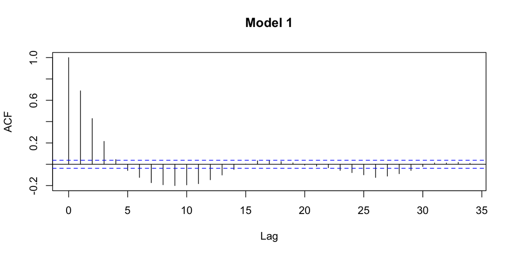

```r
test_m1 <- acf(resid(model1), main = "Model 1")
```

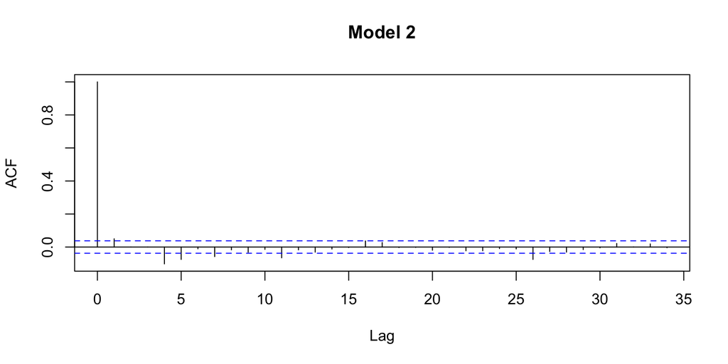

```r
test_m2 <- acf(resid(model2), main = "Model 2")
```

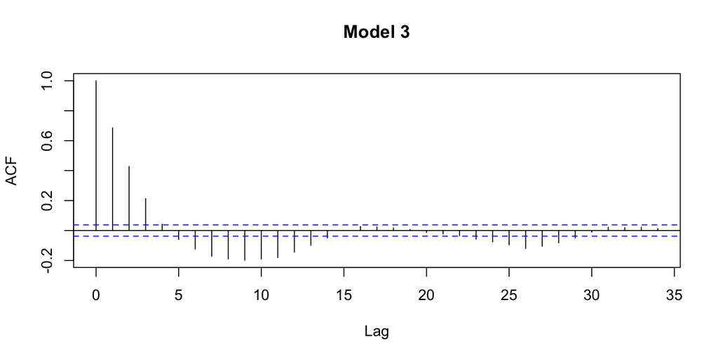

```r
test_m3 <- acf(resid(model3), main = "Model 3")
```

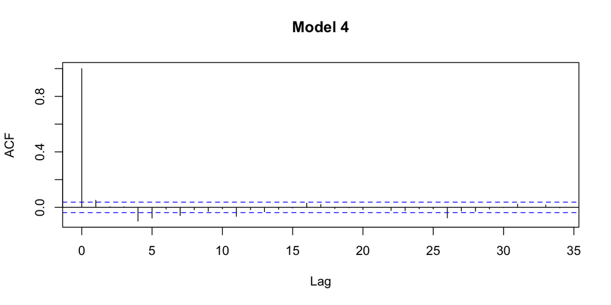

```r
test_m4 <- acf(resid(model4), main = "Model 4")
```

## Table S12 and S13

```r
# Model 2 (add. lag) in Table S13

model_lag2 <- as.formula(paste("rile ~ lag1_rile + lag2_rile + lag_cmedian + lag_econ_glob + interaction + spruled + year_fe2 + year_fe3 + year_fe4 +  year_fe5 + year_fe6 +
year_fe7 +  year_fe8 +  year_fe9 +  year_fe10 + year_fe11 + year_fe12 + year_fe13 + year_fe14 + year_fe15 + year_fe16 + year_fe17 + year_fe18 + year_fe19 + year_fe20 + year_fe21 + year_fe22 + year_fe23 + year_fe24 + year_fe25 + year_fe26 + year_fe27 + year_fe28 + year_fe29 + year_fe30 +
year_fe31 + year_fe32 + year_fe33 + year_fe34 +" , paste(partyfx, collapse= "+")))

model_lag2 <- lm(model_lag2, data = dataframe1)
summary(model_lag2)
```

```
##
## Call:
## lm(formula = model_lag2, data = dataframe1)
##
## Residuals:
##      Min       1Q   Median       3Q      Max
## -1.92697 -0.09463 -0.00301  0.10812  2.04902
##
## Coefficients:
##                 Estimate Std. Error t value Pr(>|t|)
## (Intercept)   -1.6145494  0.8331199  -1.938 0.052743 .
## lag1_rile      0.8162988  0.0193513  42.183  < 2e-16 ***
## lag2_rile     -0.0872164  0.0192234  -4.537 5.98e-06 ***
## lag_cmedian    0.5326529  0.1584993   3.361 0.000790 ***
## lag_econ_glob  0.0345774  0.0113063   3.058 0.002250 **
## interaction   -0.0070872  0.0021210  -3.341 0.000846 ***
## spruled        0.0035943  0.0012073   2.977 0.002937 **
## year_fe2       0.0307710  0.0671933   0.458 0.647031
## year_fe3       0.0247482  0.0664345   0.373 0.709538
## year_fe4       0.0379374  0.0670271   0.566 0.571445
## year_fe5       0.0775389  0.0677593   1.144 0.252599
## year_fe6       0.1578899  0.0681426   2.317 0.020583 *
## year_fe7       0.1466568  0.0697591   2.102 0.035625 *
## year_fe8       0.1224857  0.0662512   1.849 0.064605 .
## year_fe9      -0.0476149  0.0740998  -0.643 0.520557
## year_fe10     -0.0138131  0.0847408  -0.163 0.870528
## year_fe11      0.0273034  0.0750088   0.364 0.715887
## year_fe12      0.0596343  0.0708982   0.841 0.400360
## year_fe13      0.1362986  0.0665777   2.047 0.040743 *
## year_fe14      0.1322124  0.0665863   1.986 0.047191 *
## year_fe15     -0.1633021  0.0850811  -1.919 0.055053 .
## year_fe16     -0.1531409  0.1101864  -1.390 0.164705
## year_fe17     -0.1538958  0.1044856  -1.473 0.140908
## year_fe18     -0.1134565  0.1054861  -1.076 0.282230
## year_fe19     -0.0630313  0.0938367  -0.672 0.501830
## year_fe20     -0.1581416  0.1350917  -1.171 0.241863
## year_fe21     -0.2095140  0.1422728  -1.473 0.140981
## year_fe22     -0.1988966  0.1400778  -1.420 0.155763
## year_fe23     -0.3041993  0.1579325  -1.926 0.054203 .
## year_fe24     -0.3024702  0.1597528  -1.893 0.058427 .
```

[output cut: 215 more lines]

```
## party_fe207    0.4668493  0.1838904   2.539 0.011186 *
## party_fe208    0.3357515  0.1581033   2.124 0.033801 *
## party_fe209    0.1482902  0.1585980   0.935 0.349876
## party_fe210    0.2073803  0.1587491   1.306 0.191559
## party_fe211    0.3353950  0.1585930   2.115 0.034546 *
## party_fe212    0.1257837  0.2451776   0.513 0.607976
## party_fe213    0.2789079  0.1588705   1.756 0.079287 .
## party_fe214    0.2176013  0.1587370   1.371 0.170553
## party_fe215    0.4278201  0.1598486   2.676 0.007491 **
## ---
## Signif. codes:  0 '***' 0.001 '**' 0.01 '*' 0.05 '.' 0.1 ' ' 1
##
## Residual standard error: 0.3229 on 2464 degrees of freedom
## Multiple R-squared:  0.8892, Adjusted R-squared:  0.8778
## F-statistic: 78.13 on 253 and 2464 DF,  p-value: < 2.2e-16
```

```r
stargazer(model_lag2)
```

```
##
## % Table created by stargazer v.5.2.2 by Marek Hlavac, Harvard University. E-mail: hlavac at fas.harvard.edu
## % Date and time: Thu, Jul 01, 2021 - 15:53:24
## \begin{table}[!htbp] \centering
##   \caption{}
##   \label{}
## \begin{tabular}{@{\extracolsep{5pt}}lc}
## \\[-1.8ex]\hline
## \hline \\[-1.8ex]
##  & \multicolumn{1}{c}{\textit{Dependent variable:}} \\
## \cline{2-2}
## \\[-1.8ex] & rile \\
## \hline \\[-1.8ex]
##  lag1\_rile & 0.816$^{***}$ \\
##   & (0.019) \\
##   & \\
##  lag2\_rile & $-$0.087$^{***}$ \\
##   & (0.019) \\
##   & \\
##  lag\_cmedian & 0.533$^{***}$ \\
##   & (0.158) \\
##   & \\
##  lag\_econ\_glob & 0.035$^{***}$ \\
##   & (0.011) \\
##   & \\
##  interaction & $-$0.007$^{***}$ \\
##   & (0.002) \\
##   & \\
##  spruled & 0.004$^{***}$ \\
##   & (0.001) \\
##   & \\
##  year\_fe2 & 0.031 \\
##   & (0.067) \\
##   & \\
##  year\_fe3 & 0.025 \\
##   & (0.066) \\
##   & \\
##  year\_fe4 & 0.038 \\
##   & (0.067) \\
##   & \\
```

[output cut: 731 more lines]

```
##   & \\
##  Constant & $-$1.615$^{*}$ \\
##   & (0.833) \\
##   & \\
## \hline \\[-1.8ex]
## Observations & 2,718 \\
## R$^{2}$ & 0.889 \\
## Adjusted R$^{2}$ & 0.878 \\
## Residual Std. Error & 0.323 (df = 2464) \\
## F Statistic & 78.135$^{***}$ (df = 253; 2464) \\
## \hline
## \hline \\[-1.8ex]
## \textit{Note:}  & \multicolumn{1}{r}{$^{*}$p$<$0.1; $^{**}$p$<$0.05; $^{***}$p$<$0.01} \\
## \end{tabular}
## \end{table}
```

```r
# Model 4 (add. lag) in Table S13

model_lag4 <- as.formula(paste("rile ~ lag1_rile + lag2_rile + lag_cmedian + lag_econ_glob + interaction + spsamegroup_ruled + year_fe2 + year_fe3 + year_fe4 +  year_fe5 + year_fe6 +
year_fe7 +  year_fe8 +  year_fe9 +  year_fe10 + year_fe11 + year_fe12 + year_fe13 + year_fe14 + year_fe15 + year_fe16 + year_fe17 + year_fe18 + year_fe19 + year_fe20 + year_fe21 + year_fe22 + year_fe23 + year_fe24 + year_fe25 + year_fe26 + year_fe27 + year_fe28 + year_fe29 + year_fe30 +
year_fe31 + year_fe32 + year_fe33 + year_fe34 +" , paste(partyfx, collapse= "+")))

model_lag4 <- lm(model_lag4, data = dataframe1)
summary(model_lag4)
```

```
##
## Call:
## lm(formula = model_lag4, data = dataframe1)
##
## Residuals:
##      Min       1Q   Median       3Q      Max
## -1.89736 -0.09947  0.00000  0.10710  2.06855
##
## Coefficients:
##                     Estimate Std. Error t value Pr(>|t|)
## (Intercept)       -1.1769653  0.8160523  -1.442 0.149354
## lag1_rile          0.8155491  0.0193828  42.076  < 2e-16 ***
## lag2_rile         -0.0882240  0.0192256  -4.589 4.68e-06 ***
## lag_cmedian        0.4874081  0.1574186   3.096 0.001982 **
## lag_econ_glob      0.0312579  0.0112170   2.787 0.005366 **
## interaction       -0.0064295  0.0021052  -3.054 0.002282 **
## spsamegroup_ruled  0.0017015  0.0006718   2.533 0.011378 *
## year_fe2           0.0428716  0.0671003   0.639 0.522936
## year_fe3           0.0086877  0.0664877   0.131 0.896050
## year_fe4           0.0462461  0.0668933   0.691 0.489416
## year_fe5           0.1024711  0.0669665   1.530 0.126100
## year_fe6           0.1109367  0.0669868   1.656 0.097829 .
## year_fe7           0.0824544  0.0671965   1.227 0.219916
## year_fe8           0.1133680  0.0663395   1.709 0.087594 .
## year_fe9           0.0384843  0.0669514   0.575 0.565473
## year_fe10          0.1399756  0.0647894   2.160 0.030833 *
## year_fe11          0.1303147  0.0645556   2.019 0.043632 *
## year_fe12          0.1380780  0.0643199   2.147 0.031911 *
## year_fe13          0.1669315  0.0651745   2.561 0.010487 *
## year_fe14          0.1325824  0.0666560   1.989 0.046806 *
## year_fe15         -0.0261342  0.0676669  -0.386 0.699368
## year_fe16          0.0818776  0.0691183   1.185 0.236290
## year_fe17          0.0578743  0.0692582   0.836 0.403443
## year_fe18          0.0896764  0.0713684   1.257 0.209044
## year_fe19          0.0856457  0.0729008   1.175 0.240178
## year_fe20          0.1548962  0.0715211   2.166 0.030426 *
## year_fe21          0.1245257  0.0735089   1.694 0.090388 .
## year_fe22          0.1174872  0.0769952   1.526 0.127162
## year_fe23          0.0466291  0.0815371   0.572 0.567458
## year_fe24          0.0517228  0.0823583   0.628 0.530048
```

[output cut: 215 more lines]

```
## party_fe207        0.4551897  0.1838449   2.476 0.013355 *
## party_fe208        0.3290900  0.1581242   2.081 0.037517 *
## party_fe209        0.1552557  0.1588025   0.978 0.328336
## party_fe210        0.2146633  0.1589604   1.350 0.177005
## party_fe211        0.3190572  0.1586284   2.011 0.044397 *
## party_fe212        0.1333241  0.2454351   0.543 0.587031
## party_fe213        0.2863964  0.1590871   1.800 0.071944 .
## party_fe214        0.2248560  0.1589461   1.415 0.157292
## party_fe215        0.4364673  0.1600922   2.726 0.006449 **
## ---
## Signif. codes:  0 '***' 0.001 '**' 0.01 '*' 0.05 '.' 0.1 ' ' 1
##
## Residual standard error: 0.3231 on 2464 degrees of freedom
## Multiple R-squared:  0.8891, Adjusted R-squared:  0.8777
## F-statistic: 78.05 on 253 and 2464 DF,  p-value: < 2.2e-16
```

```r
stargazer(model_lag4)
```

```
##
## % Table created by stargazer v.5.2.2 by Marek Hlavac, Harvard University. E-mail: hlavac at fas.harvard.edu
## % Date and time: Thu, Jul 01, 2021 - 15:53:25
## \begin{table}[!htbp] \centering
##   \caption{}
##   \label{}
## \begin{tabular}{@{\extracolsep{5pt}}lc}
## \\[-1.8ex]\hline
## \hline \\[-1.8ex]
##  & \multicolumn{1}{c}{\textit{Dependent variable:}} \\
## \cline{2-2}
## \\[-1.8ex] & rile \\
## \hline \\[-1.8ex]
##  lag1\_rile & 0.816$^{***}$ \\
##   & (0.019) \\
##   & \\
##  lag2\_rile & $-$0.088$^{***}$ \\
##   & (0.019) \\
##   & \\
##  lag\_cmedian & 0.487$^{***}$ \\
##   & (0.157) \\
##   & \\
##  lag\_econ\_glob & 0.031$^{***}$ \\
##   & (0.011) \\
##   & \\
##  interaction & $-$0.006$^{***}$ \\
##   & (0.002) \\
##   & \\
##  spsamegroup\_ruled & 0.002$^{**}$ \\
##   & (0.001) \\
##   & \\
##  year\_fe2 & 0.043 \\
##   & (0.067) \\
##   & \\
##  year\_fe3 & 0.009 \\
##   & (0.066) \\
##   & \\
##  year\_fe4 & 0.046 \\
##   & (0.067) \\
##   & \\
```

[output cut: 731 more lines]

```
##   & \\
##  Constant & $-$1.177 \\
##   & (0.816) \\
##   & \\
## \hline \\[-1.8ex]
## Observations & 2,718 \\
## R$^{2}$ & 0.889 \\
## Adjusted R$^{2}$ & 0.878 \\
## Residual Std. Error & 0.323 (df = 2464) \\
## F Statistic & 78.048$^{***}$ (df = 253; 2464) \\
## \hline
## \hline \\[-1.8ex]
## \textit{Note:}  & \multicolumn{1}{r}{$^{*}$p$<$0.1; $^{**}$p$<$0.05; $^{***}$p$<$0.01} \\
## \end{tabular}
## \end{table}
```

```r
# Table S12

bgtest(model_lag2)
```

```
##
##  Breusch-Godfrey test for serial correlation of order up to 1
##
## data:  model_lag2
## LM test = 6.4555, df = 1, p-value = 0.01106
```

```r
bgtest(model_lag4)
```

```
##
##  Breusch-Godfrey test for serial correlation of order up to 1
##
## data:  model_lag4
## LM test = 6.0906, df = 1, p-value = 0.01359
```

## Table S14

```r
# load dataset

load("./dataframe_opp.RData")


# Model OP1 in Table S14

model_op1 <- as.formula(paste("rile ~ lag_rile + lag_cmedian + lag_econ_glob + interaction + spnonincumbent + year_fe2 + year_fe3 + year_fe4 +  year_fe5 + year_fe6 +
year_fe7 +  year_fe8 +  year_fe9 +  year_fe10 + year_fe11 + year_fe12 + year_fe13 + year_fe14 + year_fe15 + year_fe16 + year_fe17 + year_fe18 + year_fe19 + year_fe20 + year_fe21 + year_fe22 + year_fe23 + year_fe24 + year_fe25 + year_fe26 + year_fe27 + year_fe28 + year_fe29 + year_fe30 +
year_fe31 + year_fe32 + year_fe33 + year_fe34 +" , paste(partyfx, collapse= "+")))

model_op1 <- lm(model_op1, data = dataframe_opp)
summary(model_op1)
```

```
##
## Call:
## lm(formula = model_op1, data = dataframe_opp)
##
## Residuals:
##      Min       1Q   Median       3Q      Max
## -1.92677 -0.09723 -0.00251  0.10736  2.08666
##
## Coefficients:
##                  Estimate Std. Error t value Pr(>|t|)
## (Intercept)    -0.8778952  0.8323259  -1.055 0.291643
## lag_rile        0.7508498  0.0129075  58.171  < 2e-16 ***
## lag_cmedian     0.4157090  0.1595115   2.606 0.009212 **
## lag_econ_glob   0.0260077  0.0113676   2.288 0.022229 *
## interaction    -0.0055205  0.0021314  -2.590 0.009653 **
## spnonincumbent  0.0001773  0.0001793   0.989 0.322865
## year_fe2        0.0134342  0.0729883   0.184 0.853982
## year_fe3       -0.0102825  0.0724940  -0.142 0.887219
## year_fe4        0.0238046  0.0737366   0.323 0.746849
## year_fe5        0.1016034  0.0678335   1.498 0.134304
## year_fe6        0.1099485  0.0682690   1.611 0.107413
## year_fe7        0.0626066  0.0727475   0.861 0.389541
## year_fe8        0.0837989  0.0741181   1.131 0.258328
## year_fe9        0.0320666  0.0684486   0.468 0.639484
## year_fe10       0.1365702  0.0652415   2.093 0.036424 *
## year_fe11       0.1425402  0.0649128   2.196 0.028194 *
## year_fe12       0.1691494  0.0694315   2.436 0.014913 *
## year_fe13       0.1916247  0.0677707   2.828 0.004728 **
## year_fe14       0.1586189  0.0696273   2.278 0.022805 *
## year_fe15      -0.0077131  0.0681370  -0.113 0.909882
## year_fe16       0.1017120  0.0704428   1.444 0.148896
## year_fe17       0.0618507  0.0705437   0.877 0.380696
## year_fe18       0.1396882  0.0743823   1.878 0.060502 .
## year_fe19       0.1282102  0.0732229   1.751 0.080078 .
## year_fe20       0.2127416  0.0757059   2.810 0.004992 **
## year_fe21       0.1793870  0.0788360   2.275 0.022965 *
## year_fe22       0.1606847  0.0782221   2.054 0.040061 *
## year_fe23       0.1196898  0.0825820   1.449 0.147368
## year_fe24       0.1325034  0.0861825   1.537 0.124306
## year_fe25       0.1369952  0.0845152   1.621 0.105156
```

[output cut: 214 more lines]

```
## party_fe207     0.4069676  0.1845476   2.205 0.027531 *
## party_fe208     0.2681110  0.1585828   1.691 0.091026 .
## party_fe209     0.1202952  0.1594174   0.755 0.450565
## party_fe210     0.1761621  0.1595517   1.104 0.269655
## party_fe211     0.3092909  0.1594208   1.940 0.052482 .
## party_fe212     0.0893671  0.2466326   0.362 0.717122
## party_fe213     0.2479322  0.1596749   1.553 0.120616
## party_fe214     0.1810505  0.1595047   1.135 0.256453
## party_fe215     0.3861727  0.1605806   2.405 0.016252 *
## ---
## Signif. codes:  0 '***' 0.001 '**' 0.01 '*' 0.05 '.' 0.1 ' ' 1
##
## Residual standard error: 0.3248 on 2465 degrees of freedom
## Multiple R-squared:  0.8878, Adjusted R-squared:  0.8764
## F-statistic: 77.44 on 252 and 2465 DF,  p-value: < 2.2e-16
```

```r
stargazer(model_op1)
```

```
##
## % Table created by stargazer v.5.2.2 by Marek Hlavac, Harvard University. E-mail: hlavac at fas.harvard.edu
## % Date and time: Thu, Jul 01, 2021 - 15:53:27
## \begin{table}[!htbp] \centering
##   \caption{}
##   \label{}
## \begin{tabular}{@{\extracolsep{5pt}}lc}
## \\[-1.8ex]\hline
## \hline \\[-1.8ex]
##  & \multicolumn{1}{c}{\textit{Dependent variable:}} \\
## \cline{2-2}
## \\[-1.8ex] & rile \\
## \hline \\[-1.8ex]
##  lag\_rile & 0.751$^{***}$ \\
##   & (0.013) \\
##   & \\
##  lag\_cmedian & 0.416$^{***}$ \\
##   & (0.160) \\
##   & \\
##  lag\_econ\_glob & 0.026$^{**}$ \\
##   & (0.011) \\
##   & \\
##  interaction & $-$0.006$^{***}$ \\
##   & (0.002) \\
##   & \\
##  spnonincumbent & 0.0002 \\
##   & (0.0002) \\
##   & \\
##  year\_fe2 & 0.013 \\
##   & (0.073) \\
##   & \\
##  year\_fe3 & $-$0.010 \\
##   & (0.072) \\
##   & \\
##  year\_fe4 & 0.024 \\
##   & (0.074) \\
##   & \\
##  year\_fe5 & 0.102 \\
##   & (0.068) \\
##   & \\
```

[output cut: 728 more lines]

```
##   & \\
##  Constant & $-$0.878 \\
##   & (0.832) \\
##   & \\
## \hline \\[-1.8ex]
## Observations & 2,718 \\
## R$^{2}$ & 0.888 \\
## Adjusted R$^{2}$ & 0.876 \\
## Residual Std. Error & 0.325 (df = 2465) \\
## F Statistic & 77.437$^{***}$ (df = 252; 2465) \\
## \hline
## \hline \\[-1.8ex]
## \textit{Note:}  & \multicolumn{1}{r}{$^{*}$p$<$0.1; $^{**}$p$<$0.05; $^{***}$p$<$0.01} \\
## \end{tabular}
## \end{table}
```

```r
# Model OP2 in Table S14

model_op2 <- as.formula(paste("rile ~ lag_rile + lag_cmedian + lag_econ_glob + interaction + spnonincumbent_samegroup + year_fe2 + year_fe3 + year_fe4 +  year_fe5 + year_fe6 +
year_fe7 +  year_fe8 +  year_fe9 +  year_fe10 + year_fe11 + year_fe12 + year_fe13 + year_fe14 + year_fe15 + year_fe16 + year_fe17 + year_fe18 + year_fe19 + year_fe20 + year_fe21 + year_fe22 + year_fe23 + year_fe24 + year_fe25 + year_fe26 + year_fe27 + year_fe28 + year_fe29 + year_fe30 +
year_fe31 + year_fe32 + year_fe33 + year_fe34 +" , paste(partyfx, collapse= "+")))


model_op2 <- lm(model_op2, data = dataframe_opp)
summary(model_op2)
```

```
##
## Call:
## lm(formula = model_op2, data = dataframe_opp)
##
## Residuals:
##      Min       1Q   Median       3Q      Max
## -1.93529 -0.09751 -0.00134  0.10690  2.08690
##
## Coefficients:
##                            Estimate Std. Error t value Pr(>|t|)
## (Intercept)              -1.030e+00  8.198e-01  -1.256 0.209183
## lag_rile                  7.515e-01  1.289e-02  58.282  < 2e-16 ***
## lag_cmedian               4.400e-01  1.580e-01   2.785 0.005402 **
## lag_econ_glob             2.766e-02  1.125e-02   2.458 0.014058 *
## interaction              -5.813e-03  2.113e-03  -2.751 0.005984 **
## spnonincumbent_samegroup -7.885e-05  1.164e-04  -0.677 0.498164
## year_fe2                  4.100e-02  6.746e-02   0.608 0.543394
## year_fe3                  1.904e-02  6.680e-02   0.285 0.775618
## year_fe4                  5.485e-02  6.714e-02   0.817 0.414018
## year_fe5                  1.105e-01  6.725e-02   1.643 0.100424
## year_fe6                  1.220e-01  6.727e-02   1.814 0.069875 .
## year_fe7                  8.861e-02  6.750e-02   1.313 0.189421
## year_fe8                  1.148e-01  6.665e-02   1.722 0.085168 .
## year_fe9                  4.338e-02  6.725e-02   0.645 0.518958
## year_fe10                 1.409e-01  6.504e-02   2.166 0.030410 *
## year_fe11                 1.361e-01  6.476e-02   2.102 0.035656 *
## year_fe12                 1.425e-01  6.451e-02   2.210 0.027218 *
## year_fe13                 1.712e-01  6.540e-02   2.617 0.008914 **
## year_fe14                 1.369e-01  6.694e-02   2.045 0.040933 *
## year_fe15                -1.688e-02  6.765e-02  -0.249 0.803005
## year_fe16                 8.611e-02  6.886e-02   1.250 0.211251
## year_fe17                 7.722e-02  6.905e-02   1.118 0.263545
## year_fe18                 1.169e-01  7.068e-02   1.654 0.098284 .
## year_fe19                 1.167e-01  7.224e-02   1.616 0.106220
## year_fe20                 1.855e-01  7.092e-02   2.616 0.008952 **
## year_fe21                 1.486e-01  7.292e-02   2.038 0.041671 *
## year_fe22                 1.418e-01  7.619e-02   1.861 0.062928 .
## year_fe23                 9.010e-02  7.902e-02   1.140 0.254294
## year_fe24                 9.349e-02  7.978e-02   1.172 0.241384
## year_fe25                 1.270e-01  8.434e-02   1.506 0.132232
```

[output cut: 214 more lines]

```
## party_fe207               4.063e-01  1.846e-01   2.201 0.027805 *
## party_fe208               2.695e-01  1.586e-01   1.699 0.089366 .
## party_fe209               1.182e-01  1.595e-01   0.741 0.458686
## party_fe210               1.739e-01  1.596e-01   1.090 0.275912
## party_fe211               3.069e-01  1.595e-01   1.925 0.054394 .
## party_fe212               9.711e-02  2.465e-01   0.394 0.693684
## party_fe213               2.456e-01  1.597e-01   1.538 0.124239
## party_fe214               1.788e-01  1.595e-01   1.121 0.262395
## party_fe215               3.834e-01  1.606e-01   2.387 0.017067 *
## ---
## Signif. codes:  0 '***' 0.001 '**' 0.01 '*' 0.05 '.' 0.1 ' ' 1
##
## Residual standard error: 0.3248 on 2465 degrees of freedom
## Multiple R-squared:  0.8878, Adjusted R-squared:  0.8764
## F-statistic: 77.42 on 252 and 2465 DF,  p-value: < 2.2e-16
```

```r
stargazer(model_op2)
```

```
##
## % Table created by stargazer v.5.2.2 by Marek Hlavac, Harvard University. E-mail: hlavac at fas.harvard.edu
## % Date and time: Thu, Jul 01, 2021 - 15:53:28
## \begin{table}[!htbp] \centering
##   \caption{}
##   \label{}
## \begin{tabular}{@{\extracolsep{5pt}}lc}
## \\[-1.8ex]\hline
## \hline \\[-1.8ex]
##  & \multicolumn{1}{c}{\textit{Dependent variable:}} \\
## \cline{2-2}
## \\[-1.8ex] & rile \\
## \hline \\[-1.8ex]
##  lag\_rile & 0.752$^{***}$ \\
##   & (0.013) \\
##   & \\
##  lag\_cmedian & 0.440$^{***}$ \\
##   & (0.158) \\
##   & \\
##  lag\_econ\_glob & 0.028$^{**}$ \\
##   & (0.011) \\
##   & \\
##  interaction & $-$0.006$^{***}$ \\
##   & (0.002) \\
##   & \\
##  spnonincumbent\_samegroup & $-$0.0001 \\
##   & (0.0001) \\
##   & \\
##  year\_fe2 & 0.041 \\
##   & (0.067) \\
##   & \\
##  year\_fe3 & 0.019 \\
##   & (0.067) \\
##   & \\
##  year\_fe4 & 0.055 \\
##   & (0.067) \\
##   & \\
##  year\_fe5 & 0.111 \\
##   & (0.067) \\
##   & \\
```

[output cut: 728 more lines]

```
##   & \\
##  Constant & $-$1.030 \\
##   & (0.820) \\
##   & \\
## \hline \\[-1.8ex]
## Observations & 2,718 \\
## R$^{2}$ & 0.888 \\
## Adjusted R$^{2}$ & 0.876 \\
## Residual Std. Error & 0.325 (df = 2465) \\
## F Statistic & 77.418$^{***}$ (df = 252; 2465) \\
## \hline
## \hline \\[-1.8ex]
## \textit{Note:}  & \multicolumn{1}{r}{$^{*}$p$<$0.1; $^{**}$p$<$0.05; $^{***}$p$<$0.01} \\
## \end{tabular}
## \end{table}
```